# Predicting NYC Green Taxi Tips Using CRISP-DM & k-NN Regression Modeling

```r
if (!requireNamespace("tidyverse", quietly = TRUE)){
    install.packages("tidyverse")
}
library(tidyverse)
if (!requireNamespace("lubridate", quietly = TRUE)){
    install.packages("lubridate")
}

library(lubridate)
if (!requireNamespace("psych", quietly = TRUE)) {
  install.packages("pysch")
}
library(psych)
if (!requireNamespace("correlation", quietly = TRUE)) {
  install.packages("correlation")
}
library(correlation)

if (!requireNamespace("caret", quietly = TRUE)) {
  install.packages("caret")
}
library(caret)
if (!requireNamespace("FNN", quietly = TRUE)) {
  install.packages("FNN")
}
library(FNN)
```

## Question 1

```r
# read in 2018 green taxi data from csv
taxi <- read_csv("2018_Green_Taxi_Trip_Data.csv")
```

### Data Exploration

```r
problems(taxi)
```

| row | col | expected | actual | file |
| --- | --- | --- | --- | --- |
| 117408 | 10 | a double | 1,269 | C:/Users/MyPC/Downloads/2018_Green_Taxi_Trip_Data.csv |
| 117408 | 17 | a double | 1,269.80 | C:/Users/MyPC/Downloads/2018_Green_Taxi_Trip_Data.csv |
| 281321 | 10 | a double | 1,875 | C:/Users/MyPC/Downloads/2018_Green_Taxi_Trip_Data.csv |
| 281321 | 17 | a double | 1,876.80 | C:/Users/MyPC/Downloads/2018_Green_Taxi_Trip_Data.csv |
| 453253 | 10 | a double | 2,126 | C:/Users/MyPC/Downloads/2018_Green_Taxi_Trip_Data.csv |
| 453253 | 17 | a double | 2,126.80 | C:/Users/MyPC/Downloads/2018_Green_Taxi_Trip_Data.csv |
| 647987 | 10 | a double | 1,951 | C:/Users/MyPC/Downloads/2018_Green_Taxi_Trip_Data.csv |
| 647987 | 17 | a double | 1,952.80 | C:/Users/MyPC/Downloads/2018_Green_Taxi_Trip_Data.csv |
| 1008637 | 10 | a double | 2,624.50 | C:/Users/MyPC/Downloads/2018_Green_Taxi_Trip_Data.csv |
| 1008637 | 17 | a double | 2,626.30 | C:/Users/MyPC/Downloads/2018_Green_Taxi_Trip_Data.csv |

A few rows (10) in columns 10 and 17 use , in the number. Okay to ignore.

```r
head(taxi)
```

| VendorID | lpep_pickup_datetime | lpep_dropoff_datetime | store_and_fwd_flag | RatecodeID | PULocationID | DOLocationID | passenger_count | trip_distance | fare_amount | extra | mta_tax | tip_amount | tolls_amount | ehail_fee | improvement_surcharge | total_amount | payment_type | trip_type |
| --- | --- | --- | --- | --- | --- | --- | --- | --- | --- | --- | --- | --- | --- | --- | --- | --- | --- | --- |
| 2 | 1/1/2018 0:18 | 1/1/2018 0:24 | N | 1 | 236 | 236 | 5 | 0.70 | 6.0 | 0.5 | 0.5 | 0 | 0 | NA | 0.3 | 7.3 | 2 | 1 |
| 2 | 1/1/2018 0:30 | 1/1/2018 0:46 | N | 1 | 43 | 42 | 5 | 3.50 | 14.5 | 0.5 | 0.5 | 0 | 0 | NA | 0.3 | 15.8 | 2 | 1 |
| 2 | 1/1/2018 0:07 | 1/1/2018 0:19 | N | 1 | 74 | 152 | 1 | 2.14 | 10.0 | 0.5 | 0.5 | 0 | 0 | NA | 0.3 | 11.3 | 2 | 1 |
| 2 | 1/1/2018 0:32 | 1/1/2018 0:33 | N | 1 | 255 | 255 | 1 | 0.03 | -3.0 | -0.5 | -0.5 | 0 | 0 | NA | -0.3 | -4.3 | 3 | 1 |
| 2 | 1/1/2018 0:32 | 1/1/2018 0:33 | N | 1 | 255 | 255 | 1 | 0.03 | 3.0 | 0.5 | 0.5 | 0 | 0 | NA | 0.3 | 4.3 | 2 | 1 |
| 2 | 1/1/2018 0:38 | 1/1/2018 1:08 | N | 1 | 255 | 161 | 1 | 5.63 | 21.0 | 0.5 | 0.5 | 0 | 0 | NA | 0.3 | 22.3 | 2 | 1 |

```r
dim(taxi)
```

```
## [1] 1048575      19
```

```r
str(taxi)
```

```
## spc_tbl_ [1,048,575 × 19] (S3: spec_tbl_df/tbl_df/tbl/data.frame)
##  $ VendorID             : num [1:1048575] 2 2 2 2 2 2 2 2 2 2 ...
##  $ lpep_pickup_datetime : chr [1:1048575] "1/1/2018 0:18" "1/1/2018 0:30" "1/1/2018 0:07" "1/1/2018 0:32" ...
##  $ lpep_dropoff_datetime: chr [1:1048575] "1/1/2018 0:24" "1/1/2018 0:46" "1/1/2018 0:19" "1/1/2018 0:33" ...
##  $ store_and_fwd_flag   : chr [1:1048575] "N" "N" "N" "N" ...
##  $ RatecodeID           : num [1:1048575] 1 1 1 1 1 1 1 1 1 1 ...
##  $ PULocationID         : num [1:1048575] 236 43 74 255 255 255 189 189 129 226 ...
##  $ DOLocationID         : num [1:1048575] 236 42 152 255 255 161 65 225 82 7 ...
##  $ passenger_count      : num [1:1048575] 5 5 1 1 1 1 5 5 1 1 ...
##  $ trip_distance        : num [1:1048575] 0.7 3.5 2.14 0.03 0.03 5.63 1.71 3.45 1.61 1.87 ...
##  $ fare_amount          : num [1:1048575] 6 14.5 10 -3 3 21 8.5 14.5 10 7.5 ...
##  $ extra                : num [1:1048575] 0.5 0.5 0.5 -0.5 0.5 0.5 0.5 0.5 0.5 0.5 ...
##  $ mta_tax              : num [1:1048575] 0.5 0.5 0.5 -0.5 0.5 0.5 0.5 0.5 0.5 0.5 ...
##  $ tip_amount           : num [1:1048575] 0 0 0 0 0 0 0 3.16 0 0 ...
##  $ tolls_amount         : num [1:1048575] 0 0 0 0 0 0 0 0 0 0 ...
##  $ ehail_fee            : logi [1:1048575] NA NA NA NA NA NA ...
##  $ improvement_surcharge: num [1:1048575] 0.3 0.3 0.3 -0.3 0.3 0.3 0.3 0.3 0.3 0.3 ...
##  $ total_amount         : num [1:1048575] 7.3 15.8 11.3 -4.3 4.3 ...
##  $ payment_type         : num [1:1048575] 2 2 2 3 2 2 2 1 2 2 ...
##  $ trip_type            : num [1:1048575] 1 1 1 1 1 1 1 1 1 1 ...
##  - attr(*, "spec")=
##   .. cols(
##   ..   VendorID = col_double(),
##   ..   lpep_pickup_datetime = col_character(),
##   ..   lpep_dropoff_datetime = col_character(),
##   ..   store_and_fwd_flag = col_character(),
##   ..   RatecodeID = col_double(),
##   ..   PULocationID = col_double(),
##   ..   DOLocationID = col_double(),
##   ..   passenger_count = col_double(),
##   ..   trip_distance = col_double(),
##   ..   fare_amount = col_double(),
##   ..   extra = col_double(),
##   ..   mta_tax = col_double(),
##   ..   tip_amount = col_double(),
##   ..   tolls_amount = col_double(),
##   ..   ehail_fee = col_logical(),
##   ..   improvement_surcharge = col_double(),
##   ..   total_amount = col_double(),
##   ..   payment_type = col_double(),
##   ..   trip_type = col_double()
##   .. )
##  - attr(*, "problems")=<externalptr>
```

```r
summary(taxi)
```

```
##     VendorID     lpep_pickup_datetime lpep_dropoff_datetime store_and_fwd_flag
##  Min.   :1.000   Length:1048575       Length:1048575        Length:1048575
##  1st Qu.:2.000   Class :character     Class :character      Class :character
##  Median :2.000   Mode  :character     Mode  :character      Mode  :character
##  Mean   :1.827
##  3rd Qu.:2.000
##  Max.   :2.000
##
##    RatecodeID      PULocationID  DOLocationID   passenger_count
##  Min.   : 1.000   Min.   :  1   Min.   :  1.0   Min.   :0.000
##  1st Qu.: 1.000   1st Qu.: 49   1st Qu.: 61.0   1st Qu.:1.000
##  Median : 1.000   Median : 82   Median :129.0   Median :1.000
##  Mean   : 1.072   Mean   :110   Mean   :128.5   Mean   :1.359
##  3rd Qu.: 1.000   3rd Qu.:166   3rd Qu.:191.0   3rd Qu.:1.000
##  Max.   :99.000   Max.   :265   Max.   :265.0   Max.   :9.000
##
##  trip_distance      fare_amount          extra            mta_tax
##  Min.   :  0.000   Min.   :-183.00   Min.   :-4.5000   Min.   :-0.5000
##  1st Qu.:  0.990   1st Qu.:   6.00   1st Qu.: 0.0000   1st Qu.: 0.5000
##  Median :  1.700   Median :   9.00   Median : 0.0000   Median : 0.5000
##  Mean   :  2.662   Mean   :  11.72   Mean   : 0.3445   Mean   : 0.4882
##  3rd Qu.:  3.260   3rd Qu.:  14.00   3rd Qu.: 0.5000   3rd Qu.: 0.5000
##  Max.   :140.620   Max.   : 999.99   Max.   : 4.5000   Max.   : 0.5000
##                    NA's   :5
##    tip_amount       tolls_amount      ehail_fee      improvement_surcharge
##  Min.   : -2.720   Min.   :  0.0000   Mode:logical   Min.   :-0.3000
##  1st Qu.:  0.000   1st Qu.:  0.0000   NA's:1048575   1st Qu.: 0.3000
##  Median :  0.000   Median :  0.0000                  Median : 0.3000
##  Mean   :  1.037   Mean   :  0.0858                  Mean   : 0.2932
##  3rd Qu.:  1.760   3rd Qu.:  0.0000                  3rd Qu.: 0.3000
##  Max.   :295.000   Max.   :557.5500                  Max.   : 0.3000
##
##   total_amount      payment_type     trip_type
##  Min.   :-183.00   Min.   :1.000   Min.   :1.000
##  1st Qu.:   7.80   1st Qu.:1.000   1st Qu.:1.000
##  Median :  10.80   Median :1.000   Median :1.000
##  Mean   :  13.99   Mean   :1.471   Mean   :1.018
##  3rd Qu.:  16.80   3rd Qu.:2.000   3rd Qu.:1.000
##  Max.   : 999.99   Max.   :5.000   Max.   :2.000
##  NA's   :5                         NA's   :3
```

There are very few NA compared to the million rows of data these can be removed

```r
# remove NA values
taxi <- taxi %>%
    drop_na(fare_amount, total_amount, trip_type)
summary(taxi)
```

```
##     VendorID     lpep_pickup_datetime lpep_dropoff_datetime store_and_fwd_flag
##  Min.   :1.000   Length:1048567       Length:1048567        Length:1048567
##  1st Qu.:2.000   Class :character     Class :character      Class :character
##  Median :2.000   Mode  :character     Mode  :character      Mode  :character
##  Mean   :1.827
##  3rd Qu.:2.000
##  Max.   :2.000
##    RatecodeID     PULocationID  DOLocationID   passenger_count
##  Min.   :1.000   Min.   :  1   Min.   :  1.0   Min.   :0.000
##  1st Qu.:1.000   1st Qu.: 49   1st Qu.: 61.0   1st Qu.:1.000
##  Median :1.000   Median : 82   Median :129.0   Median :1.000
##  Mean   :1.072   Mean   :110   Mean   :128.5   Mean   :1.359
##  3rd Qu.:1.000   3rd Qu.:166   3rd Qu.:191.0   3rd Qu.:1.000
##  Max.   :6.000   Max.   :265   Max.   :265.0   Max.   :9.000
##  trip_distance      fare_amount          extra            mta_tax
##  Min.   :  0.000   Min.   :-183.00   Min.   :-4.5000   Min.   :-0.5000
##  1st Qu.:  0.990   1st Qu.:   6.00   1st Qu.: 0.0000   1st Qu.: 0.5000
##  Median :  1.700   Median :   9.00   Median : 0.0000   Median : 0.5000
##  Mean   :  2.662   Mean   :  11.72   Mean   : 0.3445   Mean   : 0.4882
##  3rd Qu.:  3.260   3rd Qu.:  14.00   3rd Qu.: 0.5000   3rd Qu.: 0.5000
##  Max.   :140.620   Max.   : 999.99   Max.   : 4.5000   Max.   : 0.5000
##    tip_amount       tolls_amount      ehail_fee      improvement_surcharge
##  Min.   : -2.720   Min.   :  0.0000   Mode:logical   Min.   :-0.3000
##  1st Qu.:  0.000   1st Qu.:  0.0000   NA's:1048567   1st Qu.: 0.3000
##  Median :  0.000   Median :  0.0000                  Median : 0.3000
##  Mean   :  1.037   Mean   :  0.0858                  Mean   : 0.2932
##  3rd Qu.:  1.760   3rd Qu.:  0.0000                  3rd Qu.: 0.3000
##  Max.   :295.000   Max.   :557.5500                  Max.   : 0.3000
##   total_amount      payment_type     trip_type
##  Min.   :-183.00   Min.   :1.000   Min.   :1.000
##  1st Qu.:   7.80   1st Qu.:1.000   1st Qu.:1.000
##  Median :  10.80   Median :1.000   Median :1.000
##  Mean   :  13.99   Mean   :1.471   Mean   :1.018
##  3rd Qu.:  16.80   3rd Qu.:2.000   3rd Qu.:1.000
##  Max.   : 999.99   Max.   :5.000   Max.   :2.000
```

VendorID should be a factor RatecodeID should be a factor Store_and_fwd_flag should be a factor Payment_type should be a factor Trip_type should be a factor ehail_fee is a column of entirely NA and needs to be removed

```r
# convert fields to factors and remove ehail_fee
taxi_factored <- taxi %>%
  mutate(
    VendorID = as.factor(VendorID),
    RatecodeID = as.factor(RatecodeID),
    store_and_fwd_flag = as.factor(store_and_fwd_flag),
    payment_type = as.factor(payment_type),
    trip_type = as.factor(trip_type)
  ) %>%
    select(-ehail_fee)
```

```r
str(taxi_factored)
```

```
## tibble [1,048,567 × 18] (S3: tbl_df/tbl/data.frame)
##  $ VendorID             : Factor w/ 2 levels "1","2": 2 2 2 2 2 2 2 2 2 2 ...
##  $ lpep_pickup_datetime : chr [1:1048567] "1/1/2018 0:18" "1/1/2018 0:30" "1/1/2018 0:07" "1/1/2018 0:32" ...
##  $ lpep_dropoff_datetime: chr [1:1048567] "1/1/2018 0:24" "1/1/2018 0:46" "1/1/2018 0:19" "1/1/2018 0:33" ...
##  $ store_and_fwd_flag   : Factor w/ 2 levels "N","Y": 1 1 1 1 1 1 1 1 1 1 ...
##  $ RatecodeID           : Factor w/ 6 levels "1","2","3","4",..: 1 1 1 1 1 1 1 1 1 1 ...
##  $ PULocationID         : num [1:1048567] 236 43 74 255 255 255 189 189 129 226 ...
##  $ DOLocationID         : num [1:1048567] 236 42 152 255 255 161 65 225 82 7 ...
##  $ passenger_count      : num [1:1048567] 5 5 1 1 1 1 5 5 1 1 ...
##  $ trip_distance        : num [1:1048567] 0.7 3.5 2.14 0.03 0.03 5.63 1.71 3.45 1.61 1.87 ...
##  $ fare_amount          : num [1:1048567] 6 14.5 10 -3 3 21 8.5 14.5 10 7.5 ...
##  $ extra                : num [1:1048567] 0.5 0.5 0.5 -0.5 0.5 0.5 0.5 0.5 0.5 0.5 ...
##  $ mta_tax              : num [1:1048567] 0.5 0.5 0.5 -0.5 0.5 0.5 0.5 0.5 0.5 0.5 ...
##  $ tip_amount           : num [1:1048567] 0 0 0 0 0 0 0 3.16 0 0 ...
##  $ tolls_amount         : num [1:1048567] 0 0 0 0 0 0 0 0 0 0 ...
##  $ improvement_surcharge: num [1:1048567] 0.3 0.3 0.3 -0.3 0.3 0.3 0.3 0.3 0.3 0.3 ...
##  $ total_amount         : num [1:1048567] 7.3 15.8 11.3 -4.3 4.3 ...
##  $ payment_type         : Factor w/ 5 levels "1","2","3","4",..: 2 2 2 3 2 2 2 1 2 2 ...
##  $ trip_type            : Factor w/ 2 levels "1","2": 1 1 1 1 1 1 1 1 1 1 ...
```

```r
summary(taxi_factored)
```

```
##  VendorID   lpep_pickup_datetime lpep_dropoff_datetime store_and_fwd_flag
##  1:181506   Length:1048567       Length:1048567        N:1046861
##  2:867061   Class :character     Class :character      Y:   1706
##             Mode  :character     Mode  :character
##
##
##
##  RatecodeID   PULocationID  DOLocationID   passenger_count trip_distance
##  1:1028075   Min.   :  1   Min.   :  1.0   Min.   :0.000   Min.   :  0.000
##  2:   1715   1st Qu.: 49   1st Qu.: 61.0   1st Qu.:1.000   1st Qu.:  0.990
##  3:    407   Median : 82   Median :129.0   Median :1.000   Median :  1.700
##  4:    537   Mean   :110   Mean   :128.5   Mean   :1.359   Mean   :  2.662
##  5:  17816   3rd Qu.:166   3rd Qu.:191.0   3rd Qu.:1.000   3rd Qu.:  3.260
##  6:     17   Max.   :265   Max.   :265.0   Max.   :9.000   Max.   :140.620
##   fare_amount          extra            mta_tax          tip_amount
##  Min.   :-183.00   Min.   :-4.5000   Min.   :-0.5000   Min.   : -2.720
##  1st Qu.:   6.00   1st Qu.: 0.0000   1st Qu.: 0.5000   1st Qu.:  0.000
##  Median :   9.00   Median : 0.0000   Median : 0.5000   Median :  0.000
##  Mean   :  11.72   Mean   : 0.3445   Mean   : 0.4882   Mean   :  1.037
##  3rd Qu.:  14.00   3rd Qu.: 0.5000   3rd Qu.: 0.5000   3rd Qu.:  1.760
##  Max.   : 999.99   Max.   : 4.5000   Max.   : 0.5000   Max.   :295.000
##   tolls_amount      improvement_surcharge  total_amount     payment_type
##  Min.   :  0.0000   Min.   :-0.3000       Min.   :-183.00   1:564346
##  1st Qu.:  0.0000   1st Qu.: 0.3000       1st Qu.:   7.80   2:476990
##  Median :  0.0000   Median : 0.3000       Median :  10.80   3:  5030
##  Mean   :  0.0858   Mean   : 0.2932       Mean   :  13.99   4:  2133
##  3rd Qu.:  0.0000   3rd Qu.: 0.3000       3rd Qu.:  16.80   5:    68
##  Max.   :557.5500   Max.   : 0.3000       Max.   : 999.99
##  trip_type
##  1:1030015
##  2:  18552
##
##
##
##
```

```r
# convert lpep_pickup_datetime and lpep_dropoff_datetime to datetime
taxi_time <- taxi_factored %>%
  mutate(
    lpep_pickup_datetime = mdy_hm(lpep_pickup_datetime),
    lpep_dropoff_datetime = mdy_hm(lpep_dropoff_datetime)
  )
```

Add trip_duration_minutes column

```r
# Create a new column trip duration in minutes
taxi_time$trip_duration_minutes <- as.numeric(difftime(taxi_time$lpep_dropoff_datetime, taxi_time$lpep_pickup_datetime, units = "mins"))
```

Add speed_of_taxi column

```r
# create new column speed of taxi
taxi_time$speed_of_taxi <- with(taxi_time,
    ifelse(trip_distance > 0 & trip_duration_minutes > 0,
           trip_distance / (trip_duration_minutes / 60),
           0)
)
```

Add pickup_day column

```r
# create pickup day column
taxi_time$pickup_day <- factor(weekdays(taxi_time$lpep_pickup_datetime),
                               levels = c("Monday", "Tuesday", "Wednesday", "Thursday", "Friday", "Saturday", "Sunday"),
                               ordered = TRUE)
```

Add overnight surcharge 1/0 (Y/N) Plus 50 cents overnight surcharge 8pm to 6am

```r
# add overnight surgcharges y/n
taxi_time <- taxi_time %>%
  mutate(
    pickup_hour = hour(lpep_pickup_datetime),  # extract hour (0 to 23)
    overnight_surcharge = ifelse(pickup_hour >= 20 | pickup_hour < 6, 1, 0)
  )
```

Add rush hour surcharge 1/0 (Y/N)

```r
# add rush hour surcharge y/n
taxi_time <- taxi_time %>%
  mutate(
    pickup_hour = hour(lpep_pickup_datetime),
    pickup_day = wday(lpep_pickup_datetime, label = TRUE, abbr = FALSE),  # full weekday name

    rush_hour_surcharge =
      ifelse(pickup_hour >= 16 & pickup_hour < 20 &
             pickup_day %in% c("Monday", "Tuesday", "Wednesday", "Thursday", "Friday"),
             1, 0)

  )
```

```r
head(taxi_time)
```

| VendorID | lpep_pickup_datetime | lpep_dropoff_datetime | store_and_fwd_flag | RatecodeID | PULocationID | DOLocationID | passenger_count | trip_distance | fare_amount | extra | mta_tax | tip_amount | tolls_amount | improvement_surcharge | total_amount | payment_type | trip_type | trip_duration_minutes | speed_of_taxi | pickup_day | pickup_hour | overnight_surcharge | rush_hour_surcharge |
| --- | --- | --- | --- | --- | --- | --- | --- | --- | --- | --- | --- | --- | --- | --- | --- | --- | --- | --- | --- | --- | --- | --- | --- |
| 2 | 2018-01-01 00:18:00 | 2018-01-01 00:24:00 | N | 1 | 236 | 236 | 5 | 0.70 | 6.0 | 0.5 | 0.5 | 0 | 0 | 0.3 | 7.3 | 2 | 1 | 6 | 7.000 | Monday | 0 | 1 | 0 |
| 2 | 2018-01-01 00:30:00 | 2018-01-01 00:46:00 | N | 1 | 43 | 42 | 5 | 3.50 | 14.5 | 0.5 | 0.5 | 0 | 0 | 0.3 | 15.8 | 2 | 1 | 16 | 13.125 | Monday | 0 | 1 | 0 |
| 2 | 2018-01-01 00:07:00 | 2018-01-01 00:19:00 | N | 1 | 74 | 152 | 1 | 2.14 | 10.0 | 0.5 | 0.5 | 0 | 0 | 0.3 | 11.3 | 2 | 1 | 12 | 10.700 | Monday | 0 | 1 | 0 |
| 2 | 2018-01-01 00:32:00 | 2018-01-01 00:33:00 | N | 1 | 255 | 255 | 1 | 0.03 | -3.0 | -0.5 | -0.5 | 0 | 0 | -0.3 | -4.3 | 3 | 1 | 1 | 1.800 | Monday | 0 | 1 | 0 |
| 2 | 2018-01-01 00:32:00 | 2018-01-01 00:33:00 | N | 1 | 255 | 255 | 1 | 0.03 | 3.0 | 0.5 | 0.5 | 0 | 0 | 0.3 | 4.3 | 2 | 1 | 1 | 1.800 | Monday | 0 | 1 | 0 |
| 2 | 2018-01-01 00:38:00 | 2018-01-01 01:08:00 | N | 1 | 255 | 161 | 1 | 5.63 | 21.0 | 0.5 | 0.5 | 0 | 0 | 0.3 | 22.3 | 2 | 1 | 30 | 11.260 | Monday | 0 | 1 | 0 |

```r
summary(taxi_time)
```

```
##  VendorID   lpep_pickup_datetime             lpep_dropoff_datetime
##  1:181506   Min.   :2009-01-01 00:02:00.00   Min.   :2009-01-01 11:16:00.0
##  2:867061   1st Qu.:2018-01-12 04:23:00.00   1st Qu.:2018-01-12 05:12:00.0
##             Median :2018-01-21 18:47:00.00   Median :2018-01-21 19:07:00.0
##             Mean   :2018-01-21 17:48:27.06   Mean   :2018-01-21 18:08:26.5
##             3rd Qu.:2018-01-31 18:58:00.00   3rd Qu.:2018-01-31 19:14:00.0
##             Max.   :2018-04-05 04:11:00.00   Max.   :2018-04-05 04:25:00.0
##
##  store_and_fwd_flag RatecodeID   PULocationID  DOLocationID   passenger_count
##  N:1046861          1:1028075   Min.   :  1   Min.   :  1.0   Min.   :0.000
##  Y:   1706          2:   1715   1st Qu.: 49   1st Qu.: 61.0   1st Qu.:1.000
##                     3:    407   Median : 82   Median :129.0   Median :1.000
##                     4:    537   Mean   :110   Mean   :128.5   Mean   :1.359
##                     5:  17816   3rd Qu.:166   3rd Qu.:191.0   3rd Qu.:1.000
##                     6:     17   Max.   :265   Max.   :265.0   Max.   :9.000
##
##  trip_distance      fare_amount          extra            mta_tax
##  Min.   :  0.000   Min.   :-183.00   Min.   :-4.5000   Min.   :-0.5000
##  1st Qu.:  0.990   1st Qu.:   6.00   1st Qu.: 0.0000   1st Qu.: 0.5000
##  Median :  1.700   Median :   9.00   Median : 0.0000   Median : 0.5000
##  Mean   :  2.662   Mean   :  11.72   Mean   : 0.3445   Mean   : 0.4882
##  3rd Qu.:  3.260   3rd Qu.:  14.00   3rd Qu.: 0.5000   3rd Qu.: 0.5000
##  Max.   :140.620   Max.   : 999.99   Max.   : 4.5000   Max.   : 0.5000
##
##    tip_amount       tolls_amount      improvement_surcharge  total_amount
##  Min.   : -2.720   Min.   :  0.0000   Min.   :-0.3000       Min.   :-183.00
##  1st Qu.:  0.000   1st Qu.:  0.0000   1st Qu.: 0.3000       1st Qu.:   7.80
##  Median :  0.000   Median :  0.0000   Median : 0.3000       Median :  10.80
##  Mean   :  1.037   Mean   :  0.0858   Mean   : 0.2932       Mean   :  13.99
##  3rd Qu.:  1.760   3rd Qu.:  0.0000   3rd Qu.: 0.3000       3rd Qu.:  16.80
##  Max.   :295.000   Max.   :557.5500   Max.   : 0.3000       Max.   : 999.99
##
##  payment_type trip_type   trip_duration_minutes speed_of_taxi
##  1:564346     1:1030015   Min.   :   0.00       Min.   :   0.00
##  2:476990     2:  18552   1st Qu.:   6.00       1st Qu.:   8.52
##  3:  5030                 Median :  10.00       Median :  10.80
##  4:  2133                 Mean   :  19.99       Mean   :  11.90
##  5:    68                 3rd Qu.:  17.00       3rd Qu.:  13.98
##                           Max.   :3383.00       Max.   :1188.00
##
##      pickup_day      pickup_hour    overnight_surcharge rush_hour_surcharge
##  Sunday   :121118   Min.   : 0.00   Min.   :0.0000      Min.   :0.0000
##  Monday   :141877   1st Qu.:10.00   1st Qu.:0.0000      1st Qu.:0.0000
##  Tuesday  :149765   Median :15.00   Median :0.0000      Median :0.0000
##  Wednesday:157563   Mean   :13.86   Mean   :0.2984      Mean   :0.2075
##  Thursday :144723   3rd Qu.:19.00   3rd Qu.:1.0000      3rd Qu.:0.0000
##  Friday   :182816   Max.   :23.00   Max.   :1.0000      Max.   :1.0000
##  Saturday :150705
```

```r
# filter out trips less than 1 minute and greater than 3 hours
taxi_time <- taxi_time %>%
    filter(1 < trip_duration_minutes & 180 > trip_duration_minutes)
summary(taxi_time)
```

```
##  VendorID   lpep_pickup_datetime             lpep_dropoff_datetime
##  1:177113   Min.   :2009-01-01 10:21:00.00   Min.   :2009-01-01 11:16:00.00
##  2:844153   1st Qu.:2018-01-12 06:39:00.00   1st Qu.:2018-01-12 06:55:00.00
##             Median :2018-01-21 19:19:00.00   Median :2018-01-21 19:29:00.00
##             Mean   :2018-01-21 18:32:29.11   Mean   :2018-01-21 18:45:33.07
##             3rd Qu.:2018-01-31 19:08:00.00   3rd Qu.:2018-01-31 19:19:00.00
##             Max.   :2018-04-05 04:11:00.00   Max.   :2018-04-05 04:25:00.00
##
##  store_and_fwd_flag RatecodeID   PULocationID    DOLocationID   passenger_count
##  N:1019644          1:1006981   Min.   :  1.0   Min.   :  1.0   Min.   :0.00
##  Y:   1622          2:   1150   1st Qu.: 49.0   1st Qu.: 61.0   1st Qu.:1.00
##                     3:    259   Median : 82.0   Median :129.0   Median :1.00
##                     4:    524   Mean   :109.7   Mean   :128.6   Mean   :1.36
##                     5:  12349   3rd Qu.:166.0   3rd Qu.:192.0   3rd Qu.:1.00
##                     6:      3   Max.   :265.0   Max.   :265.0   Max.   :8.00
##
##  trip_distance      fare_amount          extra            mta_tax
##  Min.   :  0.000   Min.   :-120.00   Min.   :-4.5000   Min.   :-0.5000
##  1st Qu.:  1.000   1st Qu.:   6.00   1st Qu.: 0.0000   1st Qu.: 0.5000
##  Median :  1.740   Median :   9.00   Median : 0.0000   Median : 0.5000
##  Mean   :  2.708   Mean   :  11.78   Mean   : 0.3469   Mean   : 0.4918
##  3rd Qu.:  3.300   3rd Qu.:  14.50   3rd Qu.: 0.5000   3rd Qu.: 0.5000
##  Max.   :113.720   Max.   : 999.99   Max.   : 4.5000   Max.   : 0.5000
##
##    tip_amount       tolls_amount      improvement_surcharge  total_amount
##  Min.   : -2.720   Min.   :  0.0000   Min.   :-0.3000       Min.   :-120.00
##  1st Qu.:  0.000   1st Qu.:  0.0000   1st Qu.: 0.3000       1st Qu.:   7.80
##  Median :  0.000   Median :  0.0000   Median : 0.3000       Median :  11.00
##  Mean   :  1.048   Mean   :  0.0865   Mean   : 0.2952       Mean   :  14.08
##  3rd Qu.:  1.800   3rd Qu.:  0.0000   3rd Qu.: 0.3000       3rd Qu.:  16.80
##  Max.   :295.000   Max.   :557.5500   Max.   : 0.3000       Max.   : 999.99
##
##  payment_type trip_type   trip_duration_minutes speed_of_taxi
##  1:553651     1:1008097   Min.   :  2.00        Min.   :  0.00
##  2:462566     2:  13169   1st Qu.:  6.00        1st Qu.:  8.65
##  3:  3365                 Median : 10.00        Median : 10.89
##  4:  1632                 Mean   : 13.07        Mean   : 12.01
##  5:    52                 3rd Qu.: 17.00        3rd Qu.: 14.00
##                           Max.   :179.00        Max.   :912.00
##
##      pickup_day      pickup_hour    overnight_surcharge rush_hour_surcharge
##  Sunday   :117736   Min.   : 0.00   Min.   :0.0000      Min.   :0.0000
##  Monday   :137898   1st Qu.:10.00   1st Qu.:0.0000      1st Qu.:0.0000
##  Tuesday  :145983   Median :15.00   Median :0.0000      Median :0.0000
##  Wednesday:153619   Mean   :13.88   Mean   :0.2971      Mean   :0.2084
##  Thursday :141099   3rd Qu.:19.00   3rd Qu.:1.0000      3rd Qu.:0.0000
##  Friday   :178192   Max.   :23.00   Max.   :1.0000      Max.   :1.0000
##  Saturday :146739
```

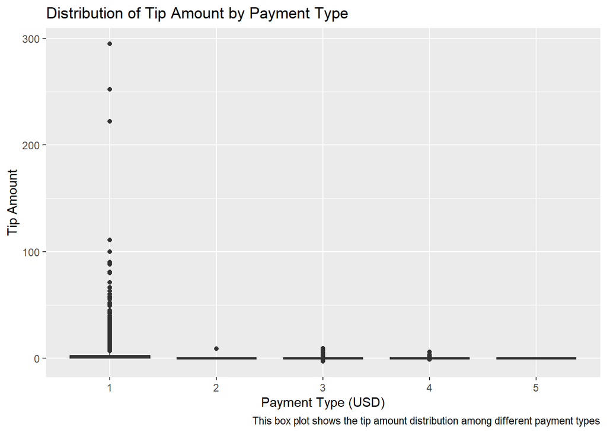

```r
# check how is the tip amount distribution among different payment types
taxi_time %>%
    ggplot(aes(x = payment_type, y = tip_amount)) +
    geom_boxplot(na.rm = TRUE) +
    labs(
    title = "Distribution of Tip Amount by Payment Type",
    x = "Payment Type (USD)",
    y = "Tip Amount",
    caption = "This box plot shows the tip amount distribution among different payment types"
    )
```

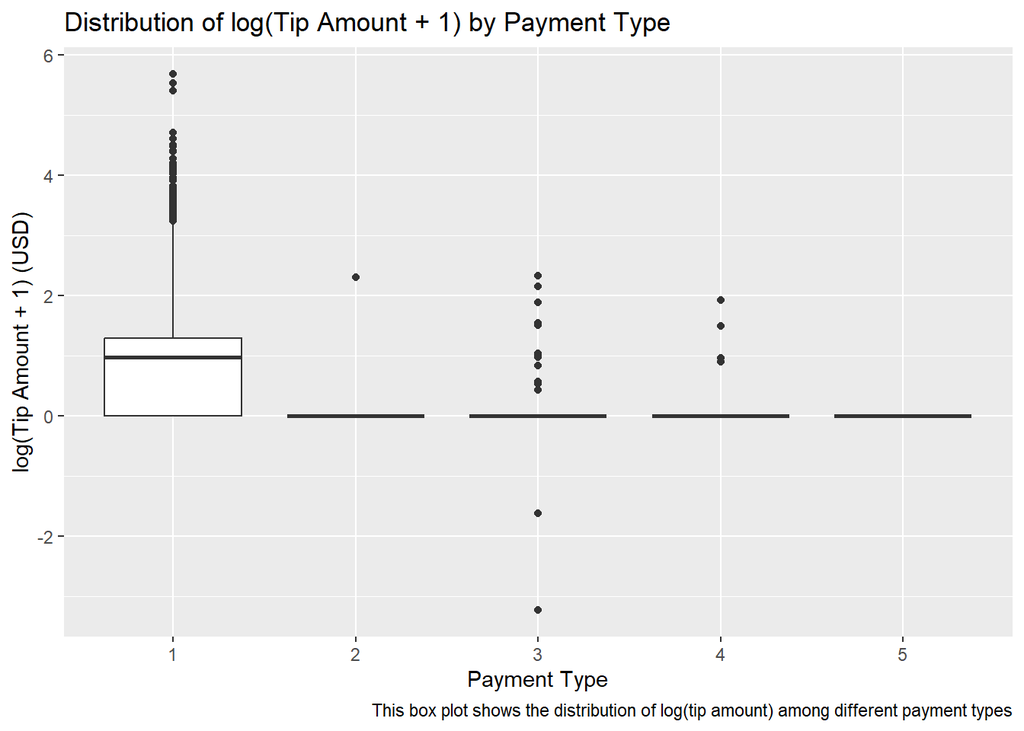

```r
# check how does the log(tip amount) distribution among different payment types
taxi_time %>%
    ggplot(aes(x = payment_type, y = log(tip_amount+1))) +
    geom_boxplot(na.rm = TRUE) +
    labs(
    title = "Distribution of log(Tip Amount + 1) by Payment Type",
    x = "Payment Type",
    y = "log(Tip Amount + 1) (USD)",
    caption = "This box plot shows the distribution of log(tip amount) among different payment types"
    )
```

There are 564346 credit card payments. There are 476990 cash payments and cash tips are not included according to the dictionary. To create a model for tips we either need to remove the cash payments since the tips are not recorded or we need to impute the tip amount since all the values are $0. We will only keep credit card payments because imputing half of our data for the outcome variable could introduce errors and bias into the data. We will remove no charge, unknown and voided trips.

```r
# only keep credit card data
taxi_time <- taxi_time %>%
    filter(payment_type == 1)
dim(taxi_time)
```

```
## [1] 553651     24
```

```r
summary(taxi_time)
```

```
##  VendorID   lpep_pickup_datetime             lpep_dropoff_datetime
##  1: 90297   Min.   :2009-01-01 10:21:00.00   Min.   :2009-01-01 11:16:00.00
##  2:463354   1st Qu.:2018-01-12 17:11:00.00   1st Qu.:2018-01-12 17:29:00.00
##             Median :2018-01-22 14:54:00.00   Median :2018-01-22 15:12:00.00
##             Mean   :2018-01-22 03:59:55.58   Mean   :2018-01-22 04:14:22.54
##             3rd Qu.:2018-02-01 00:11:00.00   3rd Qu.:2018-02-01 00:22:00.00
##             Max.   :2018-04-05 04:11:00.00   Max.   :2018-04-05 04:25:00.00
##
##  store_and_fwd_flag RatecodeID  PULocationID    DOLocationID   passenger_count
##  N:552940           1:549722   Min.   :  1.0   Min.   :  1.0   Min.   :0.000
##  Y:   711           2:   842   1st Qu.: 49.0   1st Qu.: 62.0   1st Qu.:1.000
##                     3:   188   Median : 82.0   Median :132.0   Median :1.000
##                     4:   333   Mean   :110.2   Mean   :131.2   Mean   :1.358
##                     5:  2566   3rd Qu.:166.0   3rd Qu.:196.0   3rd Qu.:1.000
##                     6:     0   Max.   :265.0   Max.   :265.0   Max.   :8.000
##
##  trip_distance      fare_amount         extra           mta_tax
##  Min.   :  0.000   Min.   :  0.00   Min.   :0.0000   Min.   :0.0000
##  1st Qu.:  1.110   1st Qu.:  6.50   1st Qu.:0.0000   1st Qu.:0.5000
##  Median :  2.000   Median : 10.00   Median :0.0000   Median :0.5000
##  Mean   :  3.072   Mean   : 13.04   Mean   :0.3479   Mean   :0.4973
##  3rd Qu.:  3.840   3rd Qu.: 16.00   3rd Qu.:0.5000   3rd Qu.:0.5000
##  Max.   :113.720   Max.   :376.00   Max.   :4.5000   Max.   :0.5000
##
##    tip_amount       tolls_amount     improvement_surcharge  total_amount
##  Min.   :  0.000   Min.   : 0.0000   Min.   :0.0000        Min.   :  0.00
##  1st Qu.:  0.000   1st Qu.: 0.0000   1st Qu.:0.3000        1st Qu.:  9.30
##  Median :  1.660   Median : 0.0000   Median :0.3000        Median : 12.95
##  Mean   :  1.933   Mean   : 0.1118   Mean   :0.2985        Mean   : 16.28
##  3rd Qu.:  2.660   3rd Qu.: 0.0000   3rd Qu.:0.3000        3rd Qu.: 19.80
##  Max.   :295.000   Max.   :99.9900   Max.   :0.3000        Max.   :382.56
##
##  payment_type trip_type  trip_duration_minutes speed_of_taxi
##  1:553651     1:550966   Min.   :  2.00        Min.   :  0.000
##  2:     0     2:  2685   1st Qu.:  7.00        1st Qu.:  8.815
##  3:     0                Median : 11.00        Median : 11.100
##  4:     0                Mean   : 14.45        Mean   : 12.319
##  5:     0                3rd Qu.: 19.00        3rd Qu.: 14.400
##                          Max.   :176.00        Max.   :495.000
##
##      pickup_day     pickup_hour    overnight_surcharge rush_hour_surcharge
##  Sunday   :62386   Min.   : 0.00   Min.   :0.0000      Min.   :0.0000
##  Monday   :73380   1st Qu.:10.00   1st Qu.:0.0000      1st Qu.:0.0000
##  Tuesday  :80395   Median :15.00   Median :0.0000      Median :0.0000
##  Wednesday:86191   Mean   :13.91   Mean   :0.2859      Mean   :0.2114
##  Thursday :79502   3rd Qu.:19.00   3rd Qu.:1.0000      3rd Qu.:0.0000
##  Friday   :96127   Max.   :23.00   Max.   :1.0000      Max.   :1.0000
##  Saturday :75670
```

date of 2009? Data entry issue?

```r
# 2009 dates?
taxi_time %>%
    filter(year(lpep_pickup_datetime) == 2009)
```

| VendorID | lpep_pickup_datetime | lpep_dropoff_datetime | store_and_fwd_flag | RatecodeID | PULocationID | DOLocationID | passenger_count | trip_distance | fare_amount | extra | mta_tax | tip_amount | tolls_amount | improvement_surcharge | total_amount | payment_type | trip_type | trip_duration_minutes | speed_of_taxi | pickup_day | pickup_hour | overnight_surcharge | rush_hour_surcharge |
| --- | --- | --- | --- | --- | --- | --- | --- | --- | --- | --- | --- | --- | --- | --- | --- | --- | --- | --- | --- | --- | --- | --- | --- |
| 2 | 2009-01-01 13:13:00 | 2009-01-01 14:30:00 | N | 1 | 7 | 117 | 1 | 32.58 | 93.5 | 0.0 | 0.5 | 0 | 2.16 | 0.3 | 96.46 | 1 | 1 | 77 | 25.38701 | Thursday | 13 | 0 | 0 |
| 2 | 2009-01-01 13:13:00 | 2009-01-01 14:11:00 | N | 1 | 93 | 117 | 1 | 29.08 | 82.0 | 0.0 | 0.5 | 0 | 2.16 | 0.3 | 84.96 | 1 | 1 | 58 | 30.08276 | Thursday | 13 | 0 | 0 |
| 2 | 2009-01-01 10:21:00 | 2009-01-01 11:16:00 | N | 1 | 93 | 117 | 1 | 28.87 | 81.0 | 0.0 | 0.5 | 0 | 2.16 | 0.3 | 83.96 | 1 | 1 | 55 | 31.49455 | Thursday | 10 | 0 | 0 |
| 2 | 2009-01-01 22:20:00 | 2009-01-01 23:15:00 | N | 1 | 117 | 7 | 1 | 32.18 | 88.0 | 0.5 | 0.5 | 0 | 2.16 | 0.3 | 91.46 | 1 | 1 | 55 | 35.10545 | Thursday | 22 | 1 | 0 |
| 2 | 2009-01-01 14:46:00 | 2009-01-01 16:08:00 | N | 1 | 117 | 93 | 1 | 28.92 | 86.5 | 0.0 | 0.5 | 0 | 2.16 | 0.3 | 89.46 | 1 | 1 | 82 | 21.16098 | Thursday | 14 | 0 | 0 |
| 2 | 2009-01-01 20:20:00 | 2009-01-01 21:18:00 | N | 1 | 93 | 117 | 1 | 29.11 | 81.0 | 0.5 | 0.5 | 0 | 2.16 | 0.3 | 84.46 | 1 | 1 | 58 | 30.11379 | Thursday | 20 | 1 | 0 |
| 2 | 2009-01-01 16:51:00 | 2009-01-01 18:07:00 | N | 1 | 93 | 117 | 1 | 28.96 | 81.5 | 1.0 | 0.5 | 0 | 2.16 | 0.3 | 85.46 | 1 | 1 | 76 | 22.86316 | Thursday | 16 | 0 | 1 |
| 2 | 2009-01-01 21:43:00 | 2009-01-01 22:42:00 | N | 1 | 117 | 7 | 1 | 31.91 | 87.5 | 0.5 | 0.5 | 0 | 2.16 | 0.3 | 90.96 | 1 | 1 | 59 | 32.45085 | Thursday | 21 | 1 | 0 |
| 2 | 2009-01-01 10:30:00 | 2009-01-01 11:27:00 | N | 1 | 93 | 117 | 1 | 31.73 | 84.5 | 0.0 | 0.5 | 0 | 2.16 | 0.3 | 87.46 | 1 | 1 | 57 | 33.40000 | Thursday | 10 | 0 | 0 |

```r
# only keep dates that are 2018
taxi_time <- taxi_time %>%
    filter(year(lpep_pickup_datetime) == 2018)
summary(taxi_time)
```

```
##  VendorID   lpep_pickup_datetime             lpep_dropoff_datetime
##  1: 90297   Min.   :2018-01-01 00:00:00.00   Min.   :2018-01-01 00:06:00.00
##  2:463329   1st Qu.:2018-01-12 17:12:00.00   1st Qu.:2018-01-12 17:30:00.00
##             Median :2018-01-22 14:55:00.00   Median :2018-01-22 15:13:00.00
##             Mean   :2018-01-22 05:25:08.86   Mean   :2018-01-22 05:39:35.78
##             3rd Qu.:2018-02-01 00:12:00.00   3rd Qu.:2018-02-01 00:23:00.00
##             Max.   :2018-04-05 04:11:00.00   Max.   :2018-04-05 04:25:00.00
##
##  store_and_fwd_flag RatecodeID  PULocationID    DOLocationID   passenger_count
##  N:552915           1:549697   Min.   :  1.0   Min.   :  1.0   Min.   :0.000
##  Y:   711           2:   842   1st Qu.: 49.0   1st Qu.: 62.0   1st Qu.:1.000
##                     3:   188   Median : 82.0   Median :132.0   Median :1.000
##                     4:   333   Mean   :110.1   Mean   :131.2   Mean   :1.358
##                     5:  2566   3rd Qu.:166.0   3rd Qu.:196.0   3rd Qu.:1.000
##                     6:     0   Max.   :265.0   Max.   :265.0   Max.   :8.000
##
##  trip_distance      fare_amount         extra           mta_tax
##  Min.   :  0.000   Min.   :  0.00   Min.   :0.0000   Min.   :0.0000
##  1st Qu.:  1.110   1st Qu.:  6.50   1st Qu.:0.0000   1st Qu.:0.5000
##  Median :  2.000   Median : 10.00   Median :0.0000   Median :0.5000
##  Mean   :  3.072   Mean   : 13.04   Mean   :0.3479   Mean   :0.4973
##  3rd Qu.:  3.840   3rd Qu.: 16.00   3rd Qu.:0.5000   3rd Qu.:0.5000
##  Max.   :113.720   Max.   :376.00   Max.   :4.5000   Max.   :0.5000
##
##    tip_amount       tolls_amount     improvement_surcharge  total_amount
##  Min.   :  0.000   Min.   : 0.0000   Min.   :0.0000        Min.   :  0.00
##  1st Qu.:  0.000   1st Qu.: 0.0000   1st Qu.:0.3000        1st Qu.:  9.30
##  Median :  1.660   Median : 0.0000   Median :0.3000        Median : 12.95
##  Mean   :  1.933   Mean   : 0.1117   Mean   :0.2985        Mean   : 16.28
##  3rd Qu.:  2.660   3rd Qu.: 0.0000   3rd Qu.:0.3000        3rd Qu.: 19.80
##  Max.   :295.000   Max.   :99.9900   Max.   :0.3000        Max.   :382.56
##
##  payment_type trip_type  trip_duration_minutes speed_of_taxi
##  1:553626     1:550941   Min.   :  2.00        Min.   :  0.000
##  2:     0     2:  2685   1st Qu.:  7.00        1st Qu.:  8.815
##  3:     0                Median : 11.00        Median : 11.100
##  4:     0                Mean   : 14.45        Mean   : 12.319
##  5:     0                3rd Qu.: 19.00        3rd Qu.: 14.400
##                          Max.   :176.00        Max.   :495.000
##
##      pickup_day     pickup_hour    overnight_surcharge rush_hour_surcharge
##  Sunday   :62371   Min.   : 0.00   Min.   :0.0000      Min.   :0.0000
##  Monday   :73380   1st Qu.:10.00   1st Qu.:0.0000      1st Qu.:0.0000
##  Tuesday  :80395   Median :15.00   Median :0.0000      Median :0.0000
##  Wednesday:86191   Mean   :13.91   Mean   :0.2859      Mean   :0.2114
##  Thursday :79492   3rd Qu.:19.00   3rd Qu.:1.0000      3rd Qu.:0.0000
##  Friday   :96127   Max.   :23.00   Max.   :1.0000      Max.   :1.0000
##  Saturday :75670
```

### Dealing with outliers

```r
# find how many rows with more than 6 passengers
taxi_time %>%
    filter(passenger_count > 6)
```

| VendorID | lpep_pickup_datetime | lpep_dropoff_datetime | store_and_fwd_flag | RatecodeID | PULocationID | DOLocationID | passenger_count | trip_distance | fare_amount | extra | mta_tax | tip_amount | tolls_amount | improvement_surcharge | total_amount | payment_type | trip_type | trip_duration_minutes | speed_of_taxi | pickup_day | pickup_hour | overnight_surcharge | rush_hour_surcharge |
| --- | --- | --- | --- | --- | --- | --- | --- | --- | --- | --- | --- | --- | --- | --- | --- | --- | --- | --- | --- | --- | --- | --- | --- |
| 2 | 2018-01-14 15:56:00 | 2018-01-14 16:04:00 | N | 5 | 127 | 220 | 7 | 1.11 | 7.00 | 0 | 0 | 1.5 | 0 | 0 | 8.50 | 1 | 2 | 8 | 8.325 | Sunday | 15 | 0 | 0 |
| 2 | 2018-01-14 18:32:00 | 2018-01-14 18:34:00 | N | 5 | 116 | 116 | 8 | 0.00 | 8.00 | 0 | 0 | 0.0 | 0 | 0 | 8.00 | 1 | 2 | 2 | 0.000 | Sunday | 18 | 0 | 0 |
| 2 | 2018-02-08 16:17:00 | 2018-02-08 16:20:00 | N | 5 | 193 | 193 | 7 | 0.00 | 0.78 | 0 | 0 | 0.0 | 0 | 0 | 0.78 | 1 | 2 | 3 | 0.000 | Thursday | 16 | 0 | 1 |

“The maximum number of passengers allowed in a yellow taxicab by law is 4 in a 4-passenger taxicab or 5 in a 5-passenger taxicab. There is an exception that an additional passenger must be accepted if that passenger is under age 7 and is held on the lap of an adult passenger seated in the rear seat.”

NYC311. (n.d.). Taxis. The City of New York. https://portal.311.nyc.gov/article/?kanumber=KA-01245

```r
# remove rows that have more than 6 passengers
taxi_time <- taxi_time %>%
    filter(passenger_count <= 6)
summary(taxi_time)
```

```
##  VendorID   lpep_pickup_datetime             lpep_dropoff_datetime
##  1: 90297   Min.   :2018-01-01 00:00:00.00   Min.   :2018-01-01 00:06:00.00
##  2:463326   1st Qu.:2018-01-12 17:12:00.00   1st Qu.:2018-01-12 17:30:00.00
##             Median :2018-01-22 14:55:00.00   Median :2018-01-22 15:13:00.00
##             Mean   :2018-01-22 05:25:08.49   Mean   :2018-01-22 05:39:35.41
##             3rd Qu.:2018-02-01 00:12:00.00   3rd Qu.:2018-02-01 00:23:00.00
##             Max.   :2018-04-05 04:11:00.00   Max.   :2018-04-05 04:25:00.00
##
##  store_and_fwd_flag RatecodeID  PULocationID    DOLocationID   passenger_count
##  N:552912           1:549697   Min.   :  1.0   Min.   :  1.0   Min.   :0.000
##  Y:   711           2:   842   1st Qu.: 49.0   1st Qu.: 62.0   1st Qu.:1.000
##                     3:   188   Median : 82.0   Median :132.0   Median :1.000
##                     4:   333   Mean   :110.1   Mean   :131.2   Mean   :1.358
##                     5:  2563   3rd Qu.:166.0   3rd Qu.:196.0   3rd Qu.:1.000
##                     6:     0   Max.   :265.0   Max.   :265.0   Max.   :6.000
##
##  trip_distance      fare_amount         extra           mta_tax
##  Min.   :  0.000   Min.   :  0.00   Min.   :0.0000   Min.   :0.0000
##  1st Qu.:  1.110   1st Qu.:  6.50   1st Qu.:0.0000   1st Qu.:0.5000
##  Median :  2.000   Median : 10.00   Median :0.0000   Median :0.5000
##  Mean   :  3.072   Mean   : 13.04   Mean   :0.3479   Mean   :0.4973
##  3rd Qu.:  3.840   3rd Qu.: 16.00   3rd Qu.:0.5000   3rd Qu.:0.5000
##  Max.   :113.720   Max.   :376.00   Max.   :4.5000   Max.   :0.5000
##
##    tip_amount       tolls_amount     improvement_surcharge  total_amount
##  Min.   :  0.000   Min.   : 0.0000   Min.   :0.0000        Min.   :  0.00
##  1st Qu.:  0.000   1st Qu.: 0.0000   1st Qu.:0.3000        1st Qu.:  9.30
##  Median :  1.660   Median : 0.0000   Median :0.3000        Median : 12.95
##  Mean   :  1.933   Mean   : 0.1117   Mean   :0.2985        Mean   : 16.28
##  3rd Qu.:  2.660   3rd Qu.: 0.0000   3rd Qu.:0.3000        3rd Qu.: 19.80
##  Max.   :295.000   Max.   :99.9900   Max.   :0.3000        Max.   :382.56
##
##  payment_type trip_type  trip_duration_minutes speed_of_taxi
##  1:553623     1:550941   Min.   :  2.00        Min.   :  0.000
##  2:     0     2:  2682   1st Qu.:  7.00        1st Qu.:  8.815
##  3:     0                Median : 11.00        Median : 11.100
##  4:     0                Mean   : 14.45        Mean   : 12.319
##  5:     0                3rd Qu.: 19.00        3rd Qu.: 14.400
##                          Max.   :176.00        Max.   :495.000
##
##      pickup_day     pickup_hour    overnight_surcharge rush_hour_surcharge
##  Sunday   :62369   Min.   : 0.00   Min.   :0.0000      Min.   :0.0000
##  Monday   :73380   1st Qu.:10.00   1st Qu.:0.0000      1st Qu.:0.0000
##  Tuesday  :80395   Median :15.00   Median :0.0000      Median :0.0000
##  Wednesday:86191   Mean   :13.91   Mean   :0.2859      Mean   :0.2114
##  Thursday :79491   3rd Qu.:19.00   3rd Qu.:1.0000      3rd Qu.:0.0000
##  Friday   :96127   Max.   :23.00   Max.   :1.0000      Max.   :1.0000
##  Saturday :75670
```

```r
# investigate 0 passengers
taxi_time %>%
    filter(passenger_count == 0)
```

| VendorID | lpep_pickup_datetime | lpep_dropoff_datetime | store_and_fwd_flag | RatecodeID | PULocationID | DOLocationID | passenger_count | trip_distance | fare_amount | extra | mta_tax | tip_amount | tolls_amount | improvement_surcharge | total_amount | payment_type | trip_type | trip_duration_minutes | speed_of_taxi | pickup_day | pickup_hour | overnight_surcharge | rush_hour_surcharge |
| --- | --- | --- | --- | --- | --- | --- | --- | --- | --- | --- | --- | --- | --- | --- | --- | --- | --- | --- | --- | --- | --- | --- | --- |
| 1 | 2018-01-02 22:31:00 | 2018-01-02 22:43:00 | N | 1 | 74 | 262 | 0 | 2.70 | 11.50 | 0.5 | 0.5 | 2.55 | 0.00 | 0.3 | 15.35 | 1 | 1 | 12 | 13.500000 | Tuesday | 22 | 1 | 0 |
| 1 | 2018-01-05 09:10:00 | 2018-01-05 09:13:00 | N | 1 | 75 | 74 | 0 | 0.60 | 4.00 | 0.0 | 0.5 | 0.95 | 0.00 | 0.3 | 5.75 | 1 | 1 | 3 | 12.000000 | Friday | 9 | 0 | 0 |
| 1 | 2018-01-06 06:18:00 | 2018-01-06 06:26:00 | N | 1 | 74 | 75 | 0 | 1.50 | 7.50 | 0.0 | 0.5 | 2.45 | 0.00 | 0.3 | 10.75 | 1 | 1 | 8 | 11.250000 | Saturday | 6 | 0 | 0 |
| 1 | 2018-01-06 07:02:00 | 2018-01-06 07:13:00 | N | 1 | 74 | 24 | 0 | 1.80 | 9.50 | 0.0 | 0.5 | 2.05 | 0.00 | 0.3 | 12.35 | 1 | 1 | 11 | 9.818182 | Saturday | 7 | 0 | 0 |
| 1 | 2018-01-06 07:44:00 | 2018-01-06 08:00:00 | N | 1 | 74 | 107 | 0 | 6.20 | 20.00 | 0.0 | 0.5 | 5.00 | 0.00 | 0.3 | 25.80 | 1 | 1 | 16 | 23.250000 | Saturday | 7 | 0 | 0 |
| 2 | 2018-01-06 15:10:00 | 2018-01-06 15:39:00 | N | 5 | 97 | 190 | 0 | 0.00 | 12.00 | 0.0 | 0.0 | 0.00 | 0.00 | 0.3 | 12.30 | 1 | 2 | 29 | 0.000000 | Saturday | 15 | 0 | 0 |
| 1 | 2018-01-06 20:41:00 | 2018-01-06 20:54:00 | N | 1 | 74 | 236 | 0 | 2.20 | 11.00 | 0.5 | 0.5 | 3.05 | 0.00 | 0.3 | 15.35 | 1 | 1 | 13 | 10.153846 | Saturday | 20 | 1 | 0 |
| 1 | 2018-01-06 21:57:00 | 2018-01-06 22:00:00 | N | 1 | 41 | 74 | 0 | 0.50 | 4.50 | 0.5 | 0.5 | 0.10 | 0.00 | 0.3 | 5.90 | 1 | 1 | 3 | 10.000000 | Saturday | 21 | 1 | 0 |
| 1 | 2018-01-06 22:39:00 | 2018-01-06 22:48:00 | N | 1 | 74 | 236 | 0 | 1.80 | 8.50 | 0.5 | 0.5 | 1.95 | 0.00 | 0.3 | 11.75 | 1 | 1 | 9 | 12.000000 | Saturday | 22 | 1 | 0 |
| 1 | 2018-01-07 14:16:00 | 2018-01-07 14:32:00 | N | 1 | 74 | 140 | 0 | 3.20 | 13.50 | 0.0 | 0.5 | 2.00 | 0.00 | 0.3 | 16.30 | 1 | 1 | 16 | 12.000000 | Sunday | 14 | 0 | 0 |

[output cut: 99 more lines]

```r
# are there 0 passengers with 0 fare?
taxi_time %>%
    filter(passenger_count == 0 & fare_amount == 0)
```

| VendorID | lpep_pickup_datetime | lpep_dropoff_datetime | store_and_fwd_flag | RatecodeID | PULocationID | DOLocationID | passenger_count | trip_distance | fare_amount | extra | mta_tax | tip_amount | tolls_amount | improvement_surcharge | total_amount | payment_type | trip_type | trip_duration_minutes | speed_of_taxi | pickup_day | pickup_hour | overnight_surcharge | rush_hour_surcharge |
| --- | --- | --- | --- | --- | --- | --- | --- | --- | --- | --- | --- | --- | --- | --- | --- | --- | --- | --- | --- | --- | --- | --- | --- |

None

The median passenger count is 1 and we need to use a whole number of passengers. Will impute the remaining zeros in pssenger count to 1.

```r
# impute rows with 0 passengers with 1
taxi_pass <- taxi_time %>%
  mutate(passenger_count = ifelse(passenger_count == 0, 1, passenger_count))

summary(taxi_pass)
```

```
##  VendorID   lpep_pickup_datetime             lpep_dropoff_datetime
##  1: 90297   Min.   :2018-01-01 00:00:00.00   Min.   :2018-01-01 00:06:00.00
##  2:463326   1st Qu.:2018-01-12 17:12:00.00   1st Qu.:2018-01-12 17:30:00.00
##             Median :2018-01-22 14:55:00.00   Median :2018-01-22 15:13:00.00
##             Mean   :2018-01-22 05:25:08.49   Mean   :2018-01-22 05:39:35.41
##             3rd Qu.:2018-02-01 00:12:00.00   3rd Qu.:2018-02-01 00:23:00.00
##             Max.   :2018-04-05 04:11:00.00   Max.   :2018-04-05 04:25:00.00
##
##  store_and_fwd_flag RatecodeID  PULocationID    DOLocationID   passenger_count
##  N:552912           1:549697   Min.   :  1.0   Min.   :  1.0   Min.   :1.000
##  Y:   711           2:   842   1st Qu.: 49.0   1st Qu.: 62.0   1st Qu.:1.000
##                     3:   188   Median : 82.0   Median :132.0   Median :1.000
##                     4:   333   Mean   :110.1   Mean   :131.2   Mean   :1.358
##                     5:  2563   3rd Qu.:166.0   3rd Qu.:196.0   3rd Qu.:1.000
##                     6:     0   Max.   :265.0   Max.   :265.0   Max.   :6.000
##
##  trip_distance      fare_amount         extra           mta_tax
##  Min.   :  0.000   Min.   :  0.00   Min.   :0.0000   Min.   :0.0000
##  1st Qu.:  1.110   1st Qu.:  6.50   1st Qu.:0.0000   1st Qu.:0.5000
##  Median :  2.000   Median : 10.00   Median :0.0000   Median :0.5000
##  Mean   :  3.072   Mean   : 13.04   Mean   :0.3479   Mean   :0.4973
##  3rd Qu.:  3.840   3rd Qu.: 16.00   3rd Qu.:0.5000   3rd Qu.:0.5000
##  Max.   :113.720   Max.   :376.00   Max.   :4.5000   Max.   :0.5000
##
##    tip_amount       tolls_amount     improvement_surcharge  total_amount
##  Min.   :  0.000   Min.   : 0.0000   Min.   :0.0000        Min.   :  0.00
##  1st Qu.:  0.000   1st Qu.: 0.0000   1st Qu.:0.3000        1st Qu.:  9.30
##  Median :  1.660   Median : 0.0000   Median :0.3000        Median : 12.95
##  Mean   :  1.933   Mean   : 0.1117   Mean   :0.2985        Mean   : 16.28
##  3rd Qu.:  2.660   3rd Qu.: 0.0000   3rd Qu.:0.3000        3rd Qu.: 19.80
##  Max.   :295.000   Max.   :99.9900   Max.   :0.3000        Max.   :382.56
##
##  payment_type trip_type  trip_duration_minutes speed_of_taxi
##  1:553623     1:550941   Min.   :  2.00        Min.   :  0.000
##  2:     0     2:  2682   1st Qu.:  7.00        1st Qu.:  8.815
##  3:     0                Median : 11.00        Median : 11.100
##  4:     0                Mean   : 14.45        Mean   : 12.319
##  5:     0                3rd Qu.: 19.00        3rd Qu.: 14.400
##                          Max.   :176.00        Max.   :495.000
##
##      pickup_day     pickup_hour    overnight_surcharge rush_hour_surcharge
##  Sunday   :62369   Min.   : 0.00   Min.   :0.0000      Min.   :0.0000
##  Monday   :73380   1st Qu.:10.00   1st Qu.:0.0000      1st Qu.:0.0000
##  Tuesday  :80395   Median :15.00   Median :0.0000      Median :0.0000
##  Wednesday:86191   Mean   :13.91   Mean   :0.2859      Mean   :0.2114
##  Thursday :79491   3rd Qu.:19.00   3rd Qu.:1.0000      3rd Qu.:0.0000
##  Friday   :96127   Max.   :23.00   Max.   :1.0000      Max.   :1.0000
##  Saturday :75670
```

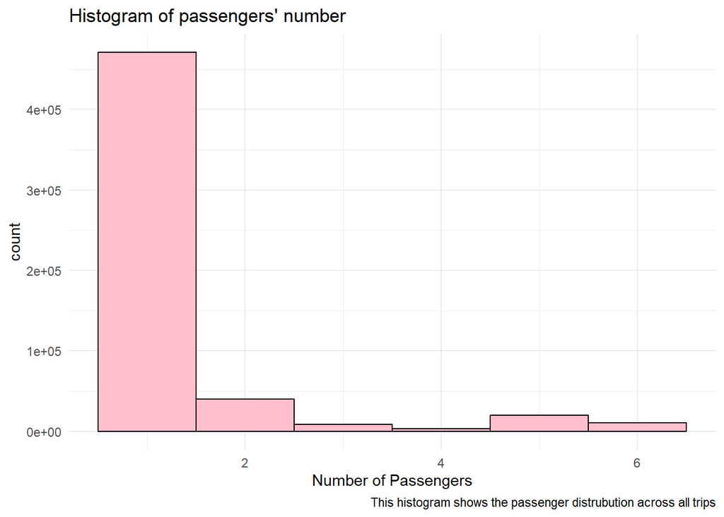

```r
# histogram of passengers
ggplot(taxi_pass, aes(x = passenger_count)) +
    geom_histogram(binwidth = 1, fill = "pink", color = "black") +
    labs(title = "Histogram of passengers' number", x = "Number of Passengers", caption = "This histogram shows the passenger distrubution across all trips") +
    theme_minimal()
```

Right skewed with 1 passenger being most common.

```r
# function to find outliers for a column and return a data frame of outliers
find_outliers <- function(dataframe, column_name){
  col_data <- dataframe[[column_name]]
  mean_col <- mean(col_data, na.rm = TRUE)
  sd_col <- sd(col_data, na.rm = TRUE)

  outliers <- dataframe %>%
    filter((.data[[column_name]] > mean_col + 3 * sd_col) |
           (.data[[column_name]] < mean_col - 3 * sd_col)) %>%
      arrange(desc(.data[[column_name]]))

  return(outliers)
}
```

```r
taxi_pass %>%
  filter(trip_distance == 0)
```

| VendorID | lpep_pickup_datetime | lpep_dropoff_datetime | store_and_fwd_flag | RatecodeID | PULocationID | DOLocationID | passenger_count | trip_distance | fare_amount | extra | mta_tax | tip_amount | tolls_amount | improvement_surcharge | total_amount | payment_type | trip_type | trip_duration_minutes | speed_of_taxi | pickup_day | pickup_hour | overnight_surcharge | rush_hour_surcharge |
| --- | --- | --- | --- | --- | --- | --- | --- | --- | --- | --- | --- | --- | --- | --- | --- | --- | --- | --- | --- | --- | --- | --- | --- |
| 2 | 2018-01-01 00:47:00 | 2018-01-01 00:49:00 | N | 1 | 25 | 25 | 1 | 0 | 3.50 | 0.5 | 0.5 | 0.00 | 0.00 | 0.3 | 4.80 | 1 | 1 | 2 | 0 | Monday | 0 | 1 | 0 |
| 2 | 2018-01-01 00:07:00 | 2018-01-01 00:15:00 | N | 1 | 166 | 238 | 1 | 0 | 6.00 | 0.5 | 0.5 | 1.46 | 0.00 | 0.3 | 8.76 | 1 | 1 | 8 | 0 | Monday | 0 | 1 | 0 |
| 2 | 2018-01-01 00:21:00 | 2018-01-01 00:27:00 | N | 1 | 166 | 116 | 1 | 0 | 5.00 | 0.5 | 0.5 | 1.00 | 0.00 | 0.3 | 7.30 | 1 | 1 | 6 | 0 | Monday | 0 | 1 | 0 |
| 2 | 2018-01-01 00:10:00 | 2018-01-01 00:36:00 | N | 1 | 190 | 170 | 1 | 0 | 15.00 | 0.5 | 0.5 | 3.00 | 0.00 | 0.3 | 19.30 | 1 | 1 | 26 | 0 | Monday | 0 | 1 | 0 |
| 2 | 2018-01-01 01:42:00 | 2018-01-01 01:44:00 | N | 5 | 109 | 109 | 1 | 0 | 30.00 | 0.0 | 0.5 | 5.00 | 0.00 | 0.3 | 35.80 | 1 | 1 | 2 | 0 | Monday | 1 | 1 | 0 |
| 2 | 2018-01-01 02:02:00 | 2018-01-01 02:04:00 | N | 1 | 198 | 198 | 1 | 0 | 3.50 | 0.5 | 0.5 | 0.00 | 0.00 | 0.3 | 4.80 | 1 | 1 | 2 | 0 | Monday | 2 | 1 | 0 |
| 2 | 2018-01-01 01:05:00 | 2018-01-01 01:20:00 | N | 1 | 181 | 72 | 3 | 0 | 9.50 | 0.5 | 0.5 | 2.16 | 0.00 | 0.3 | 12.96 | 1 | 1 | 15 | 0 | Monday | 1 | 1 | 0 |
| 2 | 2018-01-01 03:24:00 | 2018-01-01 03:37:00 | N | 1 | 37 | 35 | 1 | 0 | 8.50 | 0.5 | 0.5 | 0.00 | 0.00 | 0.3 | 9.80 | 1 | 1 | 13 | 0 | Monday | 3 | 1 | 0 |
| 2 | 2018-01-01 04:54:00 | 2018-01-01 05:07:00 | N | 1 | 80 | 65 | 1 | 0 | 9.00 | 0.5 | 0.5 | 0.00 | 0.00 | 0.3 | 10.30 | 1 | 1 | 13 | 0 | Monday | 4 | 1 | 0 |
| 2 | 2018-01-01 04:24:00 | 2018-01-01 04:27:00 | N | 5 | 159 | 168 | 2 | 0 | 20.00 | 0.0 | 0.0 | 4.00 | 0.00 | 0.0 | 24.00 | 1 | 2 | 3 | 0 | Monday | 4 | 1 | 0 |

[output cut: 1608 more lines]

1618 entries have 0 distance.

Filter based on waiting time of 15 mins, in the worst case 20.

2.50 + $10.00 = $12.50: Overnight only (8PM–6AM): 2.50 + $10.00 + $0.50 = $13.00 Rush Hour only (4PM–8PM weekdays): 2.50 + $10.00 + $1.00 = $13.50

Based on this the minimum is 2.5 and the max is 13.5

New York City Taxi and Limousine Commission. (2019, July 22). Taxi fare. NYC.gov. https://web.archive.org/web/20190722151033/https://www.nyc.gov/site/tlc/passengers/taxi-fare.page

```r
# Step 1: Pull ALL zero-distance trips
zero_distance_all <- taxi_pass %>%
  filter(trip_distance == 0)

# Step 2: From those, keep only the ones you want
zero_distance_to_keep <- zero_distance_all %>%
  filter(fare_amount >= 2.5 & fare_amount <= 13.5,
         trip_duration_minutes > 0 & trip_duration_minutes <= 20)

dim(zero_distance_to_keep)
```

```
## [1] 1203   24
```

```r
# Step 3: Remove ALL zero-distance trips from the original dataset
taxi_pass_main <- taxi_pass %>%
  filter(trip_distance != 0)

# Step 4: Add back only the filtered subset that you want to keep
taxi_improved <- bind_rows(taxi_pass_main, zero_distance_to_keep)

dim(taxi_improved)
```

```
## [1] 553208     24
```

```r
summary(taxi_improved)
```

```
##  VendorID   lpep_pickup_datetime             lpep_dropoff_datetime
##  1: 90232   Min.   :2018-01-01 00:00:00.00   Min.   :2018-01-01 00:06:00.00
##  2:462976   1st Qu.:2018-01-12 17:13:00.00   1st Qu.:2018-01-12 17:30:45.00
##             Median :2018-01-22 14:56:00.00   Median :2018-01-22 15:14:00.00
##             Mean   :2018-01-22 05:25:54.16   Mean   :2018-01-22 05:40:20.50
##             3rd Qu.:2018-02-01 00:16:00.00   3rd Qu.:2018-02-01 00:26:00.00
##             Max.   :2018-04-05 04:11:00.00   Max.   :2018-04-05 04:25:00.00
##
##  store_and_fwd_flag RatecodeID  PULocationID    DOLocationID   passenger_count
##  N:552497           1:549414   Min.   :  1.0   Min.   :  1.0   Min.   :1.000
##  Y:   711           2:   841   1st Qu.: 49.0   1st Qu.: 61.0   1st Qu.:1.000
##                     3:   188   Median : 82.0   Median :132.0   Median :1.000
##                     4:   333   Mean   :110.1   Mean   :131.2   Mean   :1.358
##                     5:  2432   3rd Qu.:166.0   3rd Qu.:196.0   3rd Qu.:1.000
##                     6:     0   Max.   :265.0   Max.   :265.0   Max.   :6.000
##
##  trip_distance      fare_amount         extra          mta_tax
##  Min.   :  0.000   Min.   :  0.00   Min.   :0.000   Min.   :0.0000
##  1st Qu.:  1.110   1st Qu.:  6.50   1st Qu.:0.000   1st Qu.:0.5000
##  Median :  2.000   Median : 10.00   Median :0.000   Median :0.5000
##  Mean   :  3.074   Mean   : 13.04   Mean   :0.348   Mean   :0.4975
##  3rd Qu.:  3.840   3rd Qu.: 16.00   3rd Qu.:0.500   3rd Qu.:0.5000
##  Max.   :113.720   Max.   :376.00   Max.   :4.500   Max.   :0.5000
##
##    tip_amount       tolls_amount     improvement_surcharge  total_amount
##  Min.   :  0.000   Min.   : 0.0000   Min.   :0.0000        Min.   :  0.00
##  1st Qu.:  0.000   1st Qu.: 0.0000   1st Qu.:0.3000        1st Qu.:  9.30
##  Median :  1.660   Median : 0.0000   Median :0.3000        Median : 12.95
##  Mean   :  1.933   Mean   : 0.1117   Mean   :0.2986        Mean   : 16.28
##  3rd Qu.:  2.660   3rd Qu.: 0.0000   3rd Qu.:0.3000        3rd Qu.: 19.80
##  Max.   :295.000   Max.   :99.9900   Max.   :0.3000        Max.   :382.56
##
##  payment_type trip_type  trip_duration_minutes speed_of_taxi
##  1:553208     1:550653   Min.   :  2.00        Min.   :  0.000
##  2:     0     2:  2555   1st Qu.:  7.00        1st Qu.:  8.823
##  3:     0                Median : 11.00        Median : 11.100
##  4:     0                Mean   : 14.44        Mean   : 12.328
##  5:     0                3rd Qu.: 19.00        3rd Qu.: 14.400
##                          Max.   :173.00        Max.   :495.000
##
##      pickup_day     pickup_hour    overnight_surcharge rush_hour_surcharge
##  Sunday   :62325   Min.   : 0.00   Min.   :0.000       Min.   :0.0000
##  Monday   :73323   1st Qu.:10.00   1st Qu.:0.000       1st Qu.:0.0000
##  Tuesday  :80341   Median :15.00   Median :0.000       Median :0.0000
##  Wednesday:86124   Mean   :13.92   Mean   :0.286       Mean   :0.2114
##  Thursday :79425   3rd Qu.:19.00   3rd Qu.:1.000       3rd Qu.:0.0000
##  Friday   :96064   Max.   :23.00   Max.   :1.000       Max.   :1.0000
##  Saturday :75606
```

```r
# trip distance outliers
outliers_trip_distance <- find_outliers(taxi_improved, "trip_distance")
dim(outliers_trip_distance)
```

```
## [1] 11588    24
```

```r
head(outliers_trip_distance)
```

| VendorID | lpep_pickup_datetime | lpep_dropoff_datetime | store_and_fwd_flag | RatecodeID | PULocationID | DOLocationID | passenger_count | trip_distance | fare_amount | extra | mta_tax | tip_amount | tolls_amount | improvement_surcharge | total_amount | payment_type | trip_type | trip_duration_minutes | speed_of_taxi | pickup_day | pickup_hour | overnight_surcharge | rush_hour_surcharge |
| --- | --- | --- | --- | --- | --- | --- | --- | --- | --- | --- | --- | --- | --- | --- | --- | --- | --- | --- | --- | --- | --- | --- | --- |
| 2 | 2018-01-19 15:13:00 | 2018-01-19 18:02:00 | N | 4 | 130 | 265 | 1 | 113.72 | 376.0 | 0.0 | 0.5 | 0.00 | 5.76 | 0.3 | 382.56 | 1 | 1 | 169 | 40.37396 | Friday | 15 | 0 | 0 |
| 2 | 2018-01-24 16:27:00 | 2018-01-24 18:15:00 | N | 4 | 260 | 265 | 1 | 63.92 | 299.5 | 1.0 | 0.5 | 0.00 | 18.26 | 0.3 | 319.56 | 1 | 1 | 108 | 35.51111 | Wednesday | 16 | 0 | 1 |
| 1 | 2018-01-26 20:46:00 | 2018-01-26 22:07:00 | N | 5 | 195 | 265 | 1 | 61.30 | 200.0 | 0.0 | 0.0 | 50.00 | 0.00 | 0.0 | 250.00 | 1 | 2 | 81 | 45.40741 | Friday | 20 | 1 | 0 |
| 2 | 2018-01-01 15:40:00 | 2018-01-01 16:39:00 | N | 5 | 145 | 265 | 2 | 52.04 | 150.0 | 0.0 | 0.0 | 0.00 | 0.00 | 0.0 | 150.00 | 1 | 2 | 59 | 52.92203 | Monday | 15 | 0 | 0 |
| 1 | 2018-01-13 18:44:00 | 2018-01-13 19:44:00 | N | 1 | 244 | 265 | 2 | 50.00 | 128.5 | 0.0 | 0.5 | 1.00 | 12.50 | 0.3 | 142.80 | 1 | 1 | 60 | 50.00000 | Saturday | 18 | 0 | 0 |
| 1 | 2018-01-01 01:16:00 | 2018-01-01 02:35:00 | N | 1 | 7 | 265 | 1 | 49.00 | 131.0 | 0.5 | 0.5 | 0.01 | 0.00 | 0.3 | 132.31 | 1 | 1 | 79 | 37.21519 | Monday | 1 | 1 | 0 |

```r
tail(outliers_trip_distance)
```

| VendorID | lpep_pickup_datetime | lpep_dropoff_datetime | store_and_fwd_flag | RatecodeID | PULocationID | DOLocationID | passenger_count | trip_distance | fare_amount | extra | mta_tax | tip_amount | tolls_amount | improvement_surcharge | total_amount | payment_type | trip_type | trip_duration_minutes | speed_of_taxi | pickup_day | pickup_hour | overnight_surcharge | rush_hour_surcharge |
| --- | --- | --- | --- | --- | --- | --- | --- | --- | --- | --- | --- | --- | --- | --- | --- | --- | --- | --- | --- | --- | --- | --- | --- |
| 2 | 2018-02-02 15:33:00 | 2018-02-02 16:12:00 | N | 1 | 46 | 69 | 1 | 12.43 | 37.5 | 0.0 | 0.5 | 0.00 | 0.00 | 0.3 | 38.30 | 1 | 1 | 39 | 19.12308 | Friday | 15 | 0 | 0 |
| 2 | 2018-02-02 19:48:00 | 2018-02-02 20:37:00 | N | 1 | 11 | 39 | 1 | 12.43 | 44.5 | 1.0 | 0.5 | 0.00 | 0.00 | 0.3 | 46.30 | 1 | 1 | 49 | 15.22041 | Friday | 19 | 0 | 1 |
| 2 | 2018-02-04 00:42:00 | 2018-02-04 01:17:00 | N | 1 | 25 | 244 | 1 | 12.43 | 38.5 | 0.5 | 0.5 | 0.00 | 0.00 | 0.3 | 39.80 | 1 | 1 | 35 | 21.30857 | Sunday | 0 | 1 | 0 |
| 2 | 2018-02-05 09:57:00 | 2018-02-05 10:35:00 | N | 1 | 95 | 88 | 1 | 12.43 | 39.5 | 0.0 | 0.5 | 9.21 | 5.76 | 0.3 | 55.27 | 1 | 1 | 38 | 19.62632 | Monday | 9 | 0 | 0 |
| 2 | 2018-02-05 09:55:00 | 2018-02-05 10:57:00 | N | 1 | 35 | 257 | 2 | 12.43 | 49.0 | 0.0 | 0.5 | 0.00 | 0.00 | 0.3 | 49.80 | 1 | 1 | 62 | 12.02903 | Monday | 9 | 0 | 0 |
| 2 | 2018-02-08 18:55:00 | 2018-02-08 19:34:00 | N | 1 | 181 | 193 | 1 | 12.43 | 38.5 | 1.0 | 0.5 | 8.06 | 0.00 | 0.3 | 48.36 | 1 | 1 | 39 | 19.12308 | Thursday | 18 | 0 | 1 |

While some of the distances seem far, the fare amount seems correct. It would be possible to take a taxi into upstate New York with a trip distance of 113.72 miles.

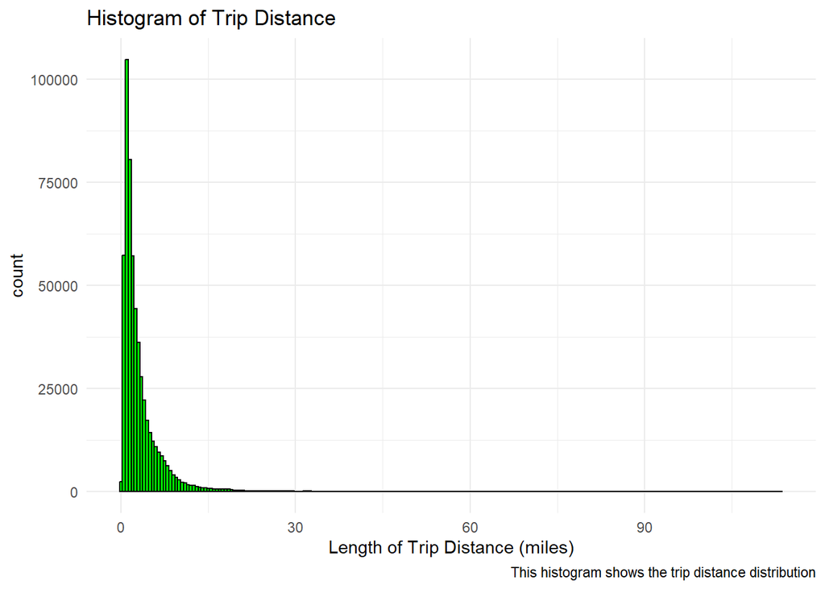

```r
# histogram of trip distance
ggplot(taxi_improved, aes(trip_distance)) +
    geom_histogram(binwidth = 0.5, fill = "green", color = "black") +
    labs(title = "Histogram of Trip Distance",
         x = "Length of Trip Distance (miles)",
         caption = "This histogram shows the trip distance distribution") +
    theme_minimal()
```

Very right skewed, most trips are short but there were a few very long trips

```r
# calculated outliers of fare amount
outliers_fair_amount <- find_outliers(taxi_improved, "fare_amount")
dim(outliers_fair_amount)
```

```
## [1] 10702    24
```

```r
head(outliers_fair_amount)
```

| VendorID | lpep_pickup_datetime | lpep_dropoff_datetime | store_and_fwd_flag | RatecodeID | PULocationID | DOLocationID | passenger_count | trip_distance | fare_amount | extra | mta_tax | tip_amount | tolls_amount | improvement_surcharge | total_amount | payment_type | trip_type | trip_duration_minutes | speed_of_taxi | pickup_day | pickup_hour | overnight_surcharge | rush_hour_surcharge |
| --- | --- | --- | --- | --- | --- | --- | --- | --- | --- | --- | --- | --- | --- | --- | --- | --- | --- | --- | --- | --- | --- | --- | --- |
| 2 | 2018-01-19 15:13:00 | 2018-01-19 18:02:00 | N | 4 | 130 | 265 | 1 | 113.72 | 376.0 | 0 | 0.5 | 0 | 5.76 | 0.3 | 382.56 | 1 | 1 | 169 | 40.37396 | Friday | 15 | 0 | 0 |
| 2 | 2018-01-24 16:27:00 | 2018-01-24 18:15:00 | N | 4 | 260 | 265 | 1 | 63.92 | 299.5 | 1 | 0.5 | 0 | 18.26 | 0.3 | 319.56 | 1 | 1 | 108 | 35.51111 | Wednesday | 16 | 0 | 1 |
| 1 | 2018-01-28 19:59:00 | 2018-01-28 21:15:00 | N | 5 | 255 | 265 | 1 | 44.30 | 250.0 | 0 | 0.0 | 40 | 12.50 | 0.0 | 302.50 | 1 | 2 | 76 | 34.97368 | Sunday | 19 | 0 | 0 |
| 2 | 2018-01-07 09:24:00 | 2018-01-07 10:19:00 | N | 4 | 244 | 265 | 1 | 47.73 | 239.5 | 0 | 0.5 | 5 | 10.50 | 0.3 | 255.80 | 1 | 1 | 55 | 52.06909 | Sunday | 9 | 0 | 0 |
| 2 | 2018-01-17 11:43:00 | 2018-01-17 12:59:00 | N | 4 | 130 | 265 | 1 | 48.59 | 229.0 | 0 | 0.5 | 10 | 0.00 | 0.3 | 239.80 | 1 | 1 | 76 | 38.36053 | Wednesday | 11 | 0 | 0 |
| 2 | 2018-02-05 12:12:00 | 2018-02-05 13:57:00 | N | 4 | 92 | 64 | 1 | 41.26 | 224.0 | 0 | 0.5 | 0 | 0.00 | 0.3 | 224.80 | 1 | 1 | 105 | 23.57714 | Monday | 12 | 0 | 0 |

```r
tail(outliers_fair_amount)
```

| VendorID | lpep_pickup_datetime | lpep_dropoff_datetime | store_and_fwd_flag | RatecodeID | PULocationID | DOLocationID | passenger_count | trip_distance | fare_amount | extra | mta_tax | tip_amount | tolls_amount | improvement_surcharge | total_amount | payment_type | trip_type | trip_duration_minutes | speed_of_taxi | pickup_day | pickup_hour | overnight_surcharge | rush_hour_surcharge |
| --- | --- | --- | --- | --- | --- | --- | --- | --- | --- | --- | --- | --- | --- | --- | --- | --- | --- | --- | --- | --- | --- | --- | --- |
| 1 | 2018-02-09 19:02:00 | 2018-02-09 19:47:00 | N | 1 | 260 | 14 | 1 | 14.30 | 42.00 | 1.0 | 0.5 | 15.00 | 0 | 0.3 | 58.80 | 1 | 1 | 45 | 19.06667 | Friday | 19 | 0 | 1 |
| 2 | 2018-02-09 19:01:00 | 2018-02-09 19:39:00 | N | 1 | 130 | 25 | 1 | 14.43 | 42.00 | 1.0 | 0.5 | 8.76 | 0 | 0.3 | 52.56 | 1 | 1 | 38 | 22.78421 | Friday | 19 | 0 | 1 |
| 2 | 2018-02-09 20:09:00 | 2018-02-09 20:50:00 | N | 1 | 108 | 177 | 1 | 13.05 | 42.00 | 0.5 | 0.5 | 0.00 | 0 | 0.3 | 43.30 | 1 | 1 | 41 | 19.09756 | Friday | 20 | 1 | 0 |
| 2 | 2018-02-09 20:49:00 | 2018-02-09 21:37:00 | N | 1 | 188 | 161 | 2 | 11.70 | 42.00 | 0.5 | 0.5 | 0.00 | 0 | 0.3 | 43.30 | 1 | 1 | 48 | 14.62500 | Friday | 20 | 1 | 0 |
| 2 | 2018-02-09 22:36:00 | 2018-02-09 23:26:00 | N | 1 | 256 | 143 | 1 | 11.37 | 42.00 | 0.5 | 0.5 | 8.00 | 0 | 0.3 | 51.30 | 1 | 1 | 50 | 13.64400 | Friday | 22 | 1 | 0 |
| 2 | 2018-01-19 06:32:00 | 2018-01-19 07:03:00 | N | 5 | 61 | 132 | 1 | 10.81 | 41.98 | 0.0 | 0.0 | 5.50 | 0 | 0.0 | 47.48 | 1 | 2 | 31 | 20.92258 | Friday | 6 | 0 | 0 |

There is a $2.5 initial charge for a taxi

```r
# Are there fare below 2.5
taxi_improved %>%
    filter(fare_amount < 2.50)
```

| VendorID | lpep_pickup_datetime | lpep_dropoff_datetime | store_and_fwd_flag | RatecodeID | PULocationID | DOLocationID | passenger_count | trip_distance | fare_amount | extra | mta_tax | tip_amount | tolls_amount | improvement_surcharge | total_amount | payment_type | trip_type | trip_duration_minutes | speed_of_taxi | pickup_day | pickup_hour | overnight_surcharge | rush_hour_surcharge |
| --- | --- | --- | --- | --- | --- | --- | --- | --- | --- | --- | --- | --- | --- | --- | --- | --- | --- | --- | --- | --- | --- | --- | --- |
| 1 | 2018-01-01 10:15:00 | 2018-01-01 10:32:00 | N | 5 | 243 | 107 | 1 | 10.10 | 0.0 | 0.0 | 0.0 | 45.00 | 0.00 | 0.0 | 45.00 | 1 | 2 | 17 | 35.647059 | Monday | 10 | 0 | 0 |
| 1 | 2018-01-02 09:53:00 | 2018-01-02 10:27:00 | N | 5 | 75 | 132 | 1 | 18.60 | 0.0 | 0.0 | 0.0 | 60.00 | 0.00 | 0.0 | 60.00 | 1 | 2 | 34 | 32.823529 | Tuesday | 9 | 0 | 0 |
| 2 | 2018-01-02 22:17:00 | 2018-01-02 22:21:00 | N | 1 | 193 | 193 | 1 | 0.33 | 0.0 | 0.0 | 0.0 | 0.00 | 0.00 | 0.0 | 0.00 | 1 | 1 | 4 | 4.950000 | Tuesday | 22 | 1 | 0 |
| 2 | 2018-01-03 01:53:00 | 2018-01-03 01:55:00 | N | 1 | 7 | 7 | 2 | 0.02 | 0.0 | 0.0 | 0.0 | 0.00 | 0.00 | 0.0 | 0.00 | 1 | 1 | 2 | 0.600000 | Wednesday | 1 | 1 | 0 |
| 1 | 2018-01-04 16:13:00 | 2018-01-04 16:24:00 | N | 5 | 216 | 216 | 1 | 1.50 | 0.0 | 0.0 | 0.0 | 10.00 | 0.00 | 0.0 | 10.00 | 1 | 2 | 11 | 8.181818 | Thursday | 16 | 0 | 1 |
| 1 | 2018-01-05 06:34:00 | 2018-01-05 06:54:00 | N | 5 | 250 | 18 | 1 | 3.80 | 0.0 | 0.0 | 0.0 | 14.00 | 0.00 | 0.0 | 14.00 | 1 | 2 | 20 | 11.400000 | Friday | 6 | 0 | 0 |
| 2 | 2018-01-08 20:16:00 | 2018-01-08 20:20:00 | N | 1 | 193 | 193 | 1 | 0.60 | 0.0 | 0.0 | 0.0 | 0.00 | 0.00 | 0.0 | 0.00 | 1 | 1 | 4 | 9.000000 | Monday | 20 | 1 | 0 |
| 2 | 2018-01-08 20:22:00 | 2018-01-08 20:25:00 | N | 1 | 193 | 193 | 1 | 0.60 | 0.0 | 0.0 | 0.0 | 0.00 | 0.00 | 0.0 | 0.00 | 1 | 1 | 3 | 12.000000 | Monday | 20 | 1 | 0 |
| 2 | 2018-01-08 20:39:00 | 2018-01-08 20:43:00 | N | 1 | 145 | 193 | 1 | 0.91 | 0.0 | 0.0 | 0.0 | 0.00 | 0.00 | 0.0 | 0.00 | 1 | 1 | 4 | 13.650000 | Monday | 20 | 1 | 0 |
| 1 | 2018-01-09 16:56:00 | 2018-01-09 17:01:00 | N | 5 | 173 | 82 | 2 | 0.10 | 0.0 | 0.0 | 0.0 | 1.00 | 0.00 | 0.0 | 1.00 | 1 | 2 | 5 | 1.200000 | Tuesday | 16 | 0 | 1 |

[output cut: 21 more lines]

31 entries less than 2.50

Remove fare_amount that are below 2.50

```r
# Filter fare below 2.5
taxi_improved <- taxi_improved %>%
    filter(fare_amount >= 2.50)
```

```r
summary(taxi_improved)
```

```
##  VendorID   lpep_pickup_datetime             lpep_dropoff_datetime
##  1: 90213   Min.   :2018-01-01 00:00:00.00   Min.   :2018-01-01 00:06:00.0
##  2:462964   1st Qu.:2018-01-12 17:13:00.00   1st Qu.:2018-01-12 17:31:00.0
##             Median :2018-01-22 14:56:00.00   Median :2018-01-22 15:14:00.0
##             Mean   :2018-01-22 05:26:14.75   Mean   :2018-01-22 05:40:41.0
##             3rd Qu.:2018-02-01 00:17:00.00   3rd Qu.:2018-02-01 00:26:00.0
##             Max.   :2018-04-05 04:11:00.00   Max.   :2018-04-05 04:25:00.0
##
##  store_and_fwd_flag RatecodeID  PULocationID    DOLocationID   passenger_count
##  N:552466           1:549400   Min.   :  1.0   Min.   :  1.0   Min.   :1.000
##  Y:   711           2:   841   1st Qu.: 49.0   1st Qu.: 61.0   1st Qu.:1.000
##                     3:   188   Median : 82.0   Median :132.0   Median :1.000
##                     4:   333   Mean   :110.1   Mean   :131.2   Mean   :1.358
##                     5:  2415   3rd Qu.:166.0   3rd Qu.:196.0   3rd Qu.:1.000
##                     6:     0   Max.   :265.0   Max.   :265.0   Max.   :6.000
##
##  trip_distance      fare_amount         extra          mta_tax
##  Min.   :  0.000   Min.   :  2.50   Min.   :0.000   Min.   :0.0000
##  1st Qu.:  1.120   1st Qu.:  6.50   1st Qu.:0.000   1st Qu.:0.5000
##  Median :  2.000   Median : 10.00   Median :0.000   Median :0.5000
##  Mean   :  3.074   Mean   : 13.04   Mean   :0.348   Mean   :0.4975
##  3rd Qu.:  3.840   3rd Qu.: 16.00   3rd Qu.:0.500   3rd Qu.:0.5000
##  Max.   :113.720   Max.   :376.00   Max.   :4.500   Max.   :0.5000
##
##    tip_amount       tolls_amount     improvement_surcharge  total_amount
##  Min.   :  0.000   Min.   : 0.0000   Min.   :0.0000        Min.   :  3.30
##  1st Qu.:  0.000   1st Qu.: 0.0000   1st Qu.:0.3000        1st Qu.:  9.30
##  Median :  1.660   Median : 0.0000   Median :0.3000        Median : 12.95
##  Mean   :  1.932   Mean   : 0.1117   Mean   :0.2987        Mean   : 16.28
##  3rd Qu.:  2.660   3rd Qu.: 0.0000   3rd Qu.:0.3000        3rd Qu.: 19.80
##  Max.   :295.000   Max.   :99.9900   Max.   :0.3000        Max.   :382.56
##
##  payment_type trip_type  trip_duration_minutes speed_of_taxi
##  1:553177     1:550639   Min.   :  2.00        Min.   :  0.000
##  2:     0     2:  2538   1st Qu.:  7.00        1st Qu.:  8.823
##  3:     0                Median : 11.00        Median : 11.100
##  4:     0                Mean   : 14.44        Mean   : 12.328
##  5:     0                3rd Qu.: 19.00        3rd Qu.: 14.400
##                          Max.   :173.00        Max.   :495.000
##
##      pickup_day     pickup_hour    overnight_surcharge rush_hour_surcharge
##  Sunday   :62323   Min.   : 0.00   Min.   :0.000       Min.   :0.0000
##  Monday   :73319   1st Qu.:10.00   1st Qu.:0.000       1st Qu.:0.0000
##  Tuesday  :80334   Median :15.00   Median :0.000       Median :0.0000
##  Wednesday:86117   Mean   :13.92   Mean   :0.286       Mean   :0.2114
##  Thursday :79421   3rd Qu.:19.00   3rd Qu.:1.000       3rd Qu.:0.0000
##  Friday   :96059   Max.   :23.00   Max.   :1.000       Max.   :1.0000
##  Saturday :75604
```

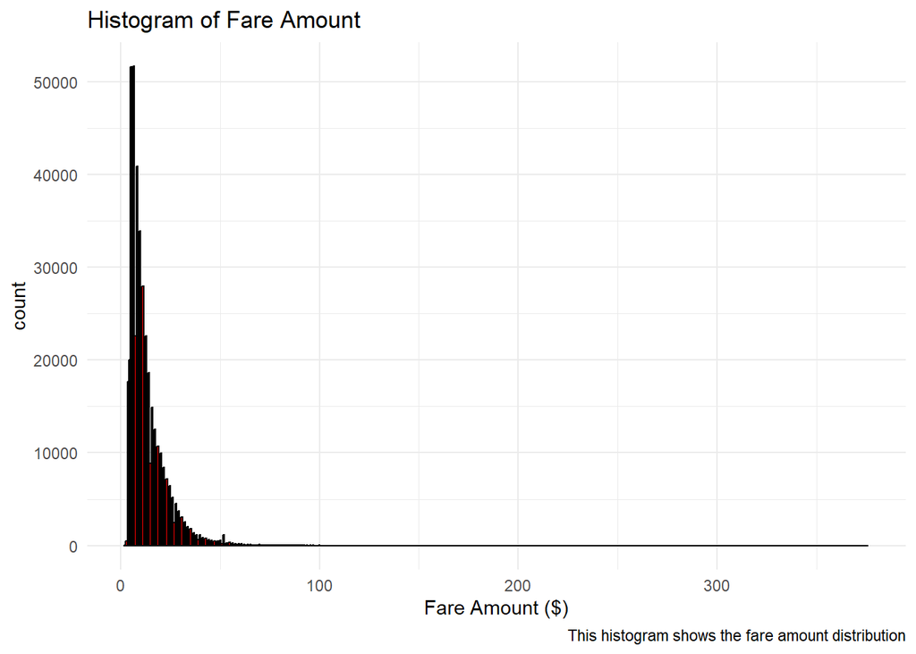

```r
# histogram of fare amount
ggplot(taxi_improved, aes(x = fare_amount)) +
    geom_histogram(binwidth = 0.75, fill = "red", color = "black") +
    labs(title = "Histogram of Fare Amount",
         x = "Fare Amount ($)",
         caption = "This histogram shows the fare amount distribution") +
    theme_minimal()
```

Very right skewed. This corresponds with the trip distance being right skewed, most rides are less than $50 but there are a few very expensive rides (these were long distance rides)

Remove correlation between fare_amount and fare_distance.

```r
taxi_cleaned <- taxi_improved %>%
  mutate(
    fare_by_distance = trip_distance * 2.5,  # $0.50 per 1/5 mile = $2.50 per mile
    efficiency_ratio = ifelse(fare_by_distance >= 1.25, # only calculate if 0.5 miles or more, otherwise, efficiency ratio is 0
                              (fare_amount - 2.5) / fare_by_distance,
                              0)
  )
```

This code calculates an efficiency_ratio, which compares what a passenger actually paid (excluding the base fare) to what they were expected to pay based solely on the trip distance, using a rate of $2.50 per mile. The ratio gives insight into fare fairness—if it’s greater than 1, the passenger likely paid more than the distance alone would suggest. This overpayment could be due to extra charges like time-based surcharges (e.g., traffic delays), or other inefficiencies in the trip.

To avoid skew from very short trips, the ratio is only computed for trips of at least 0.5 miles; otherwise, it defaults to 0.

```r
head(taxi_cleaned)
```

| VendorID | lpep_pickup_datetime | lpep_dropoff_datetime | store_and_fwd_flag | RatecodeID | PULocationID | DOLocationID | passenger_count | trip_distance | fare_amount | extra | mta_tax | tip_amount | tolls_amount | improvement_surcharge | total_amount | payment_type | trip_type | trip_duration_minutes | speed_of_taxi | pickup_day | pickup_hour | overnight_surcharge | rush_hour_surcharge | fare_by_distance | efficiency_ratio |
| --- | --- | --- | --- | --- | --- | --- | --- | --- | --- | --- | --- | --- | --- | --- | --- | --- | --- | --- | --- | --- | --- | --- | --- | --- | --- |
| 2 | 2018-01-01 00:38:00 | 2018-01-01 00:55:00 | N | 1 | 189 | 225 | 5 | 3.45 | 14.5 | 0.5 | 0.5 | 3.16 | 0 | 0.3 | 18.96 | 1 | 1 | 17 | 12.17647 | Monday | 0 | 1 | 0 | 8.625 | 1.391304 |
| 2 | 2018-01-01 00:57:00 | 2018-01-01 01:12:00 | N | 1 | 97 | 188 | 1 | 2.71 | 11.5 | 0.5 | 0.5 | 3.84 | 0 | 0.3 | 16.64 | 1 | 1 | 15 | 10.84000 | Monday | 0 | 1 | 0 | 6.775 | 1.328413 |
| 2 | 2018-01-01 00:36:00 | 2018-01-01 00:51:00 | N | 1 | 244 | 75 | 2 | 6.01 | 19.0 | 0.5 | 0.5 | 4.00 | 0 | 0.3 | 24.30 | 1 | 1 | 15 | 24.04000 | Monday | 0 | 1 | 0 | 15.025 | 1.098170 |
| 1 | 2018-01-01 00:07:00 | 2018-01-01 00:15:00 | N | 1 | 225 | 37 | 1 | 1.90 | 8.0 | 0.5 | 0.5 | 3.00 | 0 | 0.3 | 12.30 | 1 | 1 | 8 | 14.25000 | Monday | 0 | 1 | 0 | 4.750 | 1.157895 |
| 1 | 2018-01-01 00:25:00 | 2018-01-01 00:42:00 | N | 1 | 36 | 145 | 2 | 4.30 | 15.5 | 0.5 | 0.5 | 3.35 | 0 | 0.3 | 20.15 | 1 | 1 | 17 | 15.17647 | Monday | 0 | 1 | 0 | 10.750 | 1.209302 |
| 1 | 2018-01-01 00:42:00 | 2018-01-01 01:00:00 | N | 1 | 145 | 173 | 1 | 6.90 | 22.0 | 0.5 | 0.5 | 0.00 | 0 | 0.3 | 23.30 | 1 | 1 | 18 | 23.00000 | Monday | 0 | 1 | 0 | 17.250 | 1.130435 |

```r
summary(taxi_cleaned)
```

```
##  VendorID   lpep_pickup_datetime             lpep_dropoff_datetime
##  1: 90213   Min.   :2018-01-01 00:00:00.00   Min.   :2018-01-01 00:06:00.0
##  2:462964   1st Qu.:2018-01-12 17:13:00.00   1st Qu.:2018-01-12 17:31:00.0
##             Median :2018-01-22 14:56:00.00   Median :2018-01-22 15:14:00.0
##             Mean   :2018-01-22 05:26:14.75   Mean   :2018-01-22 05:40:41.0
##             3rd Qu.:2018-02-01 00:17:00.00   3rd Qu.:2018-02-01 00:26:00.0
##             Max.   :2018-04-05 04:11:00.00   Max.   :2018-04-05 04:25:00.0
##
##  store_and_fwd_flag RatecodeID  PULocationID    DOLocationID   passenger_count
##  N:552466           1:549400   Min.   :  1.0   Min.   :  1.0   Min.   :1.000
##  Y:   711           2:   841   1st Qu.: 49.0   1st Qu.: 61.0   1st Qu.:1.000
##                     3:   188   Median : 82.0   Median :132.0   Median :1.000
##                     4:   333   Mean   :110.1   Mean   :131.2   Mean   :1.358
##                     5:  2415   3rd Qu.:166.0   3rd Qu.:196.0   3rd Qu.:1.000
##                     6:     0   Max.   :265.0   Max.   :265.0   Max.   :6.000
##
##  trip_distance      fare_amount         extra          mta_tax
##  Min.   :  0.000   Min.   :  2.50   Min.   :0.000   Min.   :0.0000
##  1st Qu.:  1.120   1st Qu.:  6.50   1st Qu.:0.000   1st Qu.:0.5000
##  Median :  2.000   Median : 10.00   Median :0.000   Median :0.5000
##  Mean   :  3.074   Mean   : 13.04   Mean   :0.348   Mean   :0.4975
##  3rd Qu.:  3.840   3rd Qu.: 16.00   3rd Qu.:0.500   3rd Qu.:0.5000
##  Max.   :113.720   Max.   :376.00   Max.   :4.500   Max.   :0.5000
##
##    tip_amount       tolls_amount     improvement_surcharge  total_amount
##  Min.   :  0.000   Min.   : 0.0000   Min.   :0.0000        Min.   :  3.30
##  1st Qu.:  0.000   1st Qu.: 0.0000   1st Qu.:0.3000        1st Qu.:  9.30
##  Median :  1.660   Median : 0.0000   Median :0.3000        Median : 12.95
##  Mean   :  1.932   Mean   : 0.1117   Mean   :0.2987        Mean   : 16.28
##  3rd Qu.:  2.660   3rd Qu.: 0.0000   3rd Qu.:0.3000        3rd Qu.: 19.80
##  Max.   :295.000   Max.   :99.9900   Max.   :0.3000        Max.   :382.56
##
##  payment_type trip_type  trip_duration_minutes speed_of_taxi
##  1:553177     1:550639   Min.   :  2.00        Min.   :  0.000
##  2:     0     2:  2538   1st Qu.:  7.00        1st Qu.:  8.823
##  3:     0                Median : 11.00        Median : 11.100
##  4:     0                Mean   : 14.44        Mean   : 12.328
##  5:     0                3rd Qu.: 19.00        3rd Qu.: 14.400
##                          Max.   :173.00        Max.   :495.000
##
##      pickup_day     pickup_hour    overnight_surcharge rush_hour_surcharge
##  Sunday   :62323   Min.   : 0.00   Min.   :0.000       Min.   :0.0000
##  Monday   :73319   1st Qu.:10.00   1st Qu.:0.000       1st Qu.:0.0000
##  Tuesday  :80334   Median :15.00   Median :0.000       Median :0.0000
##  Wednesday:86117   Mean   :13.92   Mean   :0.286       Mean   :0.2114
##  Thursday :79421   3rd Qu.:19.00   3rd Qu.:1.000       3rd Qu.:0.0000
##  Friday   :96059   Max.   :23.00   Max.   :1.000       Max.   :1.0000
##  Saturday :75604
##  fare_by_distance  efficiency_ratio
##  Min.   :  0.000   Min.   : 0.000
##  1st Qu.:  2.800   1st Qu.: 1.205
##  Median :  5.000   Median : 1.373
##  Mean   :  7.685   Mean   : 1.415
##  3rd Qu.:  9.600   3rd Qu.: 1.585
##  Max.   :284.300   Max.   :44.231
##
```

```r
# find outliers for efficiency
efficiency_outliers <- find_outliers(taxi_cleaned, "efficiency_ratio")
dim(efficiency_outliers)
```

```
## [1] 4144   26
```

```r
head(efficiency_outliers)
```

| VendorID | lpep_pickup_datetime | lpep_dropoff_datetime | store_and_fwd_flag | RatecodeID | PULocationID | DOLocationID | passenger_count | trip_distance | fare_amount | extra | mta_tax | tip_amount | tolls_amount | improvement_surcharge | total_amount | payment_type | trip_type | trip_duration_minutes | speed_of_taxi | pickup_day | pickup_hour | overnight_surcharge | rush_hour_surcharge | fare_by_distance | efficiency_ratio |
| --- | --- | --- | --- | --- | --- | --- | --- | --- | --- | --- | --- | --- | --- | --- | --- | --- | --- | --- | --- | --- | --- | --- | --- | --- | --- |
| 2 | 2018-01-01 02:06:00 | 2018-01-01 02:08:00 | N | 5 | 212 | 213 | 1 | 0.52 | 60.0 | 0 | 0.0 | 0.00 | 0 | 0.0 | 60.00 | 1 | 2 | 2 | 15.6 | Monday | 2 | 1 | 0 | 1.30 | 44.23077 |
| 2 | 2018-01-16 04:00:00 | 2018-01-16 04:02:00 | N | 5 | 179 | 7 | 1 | 0.54 | 60.0 | 0 | 0.0 | 0.00 | 0 | 0.0 | 60.00 | 1 | 2 | 2 | 16.2 | Tuesday | 4 | 1 | 0 | 1.35 | 42.59259 |
| 2 | 2018-01-21 19:25:00 | 2018-01-21 19:27:00 | N | 5 | 132 | 132 | 1 | 0.62 | 65.0 | 0 | 0.0 | 0.00 | 0 | 0.0 | 65.00 | 1 | 2 | 2 | 18.6 | Sunday | 19 | 0 | 0 | 1.55 | 40.32258 |
| 2 | 2018-01-21 12:07:00 | 2018-01-21 12:13:00 | N | 5 | 116 | 42 | 1 | 0.52 | 48.0 | 0 | 0.0 | 0.00 | 0 | 0.0 | 48.00 | 1 | 2 | 6 | 5.2 | Sunday | 12 | 0 | 0 | 1.30 | 35.00000 |
| 2 | 2018-02-09 12:59:00 | 2018-02-09 13:21:00 | N | 5 | 106 | 106 | 1 | 0.66 | 57.5 | 0 | 0.0 | 0.00 | 0 | 0.0 | 57.50 | 1 | 2 | 22 | 1.8 | Friday | 12 | 0 | 0 | 1.65 | 33.33333 |
| 2 | 2018-01-27 21:36:00 | 2018-01-27 21:40:00 | N | 2 | 66 | 66 | 1 | 0.62 | 52.0 | 0 | 0.5 | 10.56 | 0 | 0.3 | 63.36 | 1 | 1 | 4 | 9.3 | Saturday | 21 | 1 | 0 | 1.55 | 31.93548 |

```r
tail(efficiency_outliers)
```

| VendorID | lpep_pickup_datetime | lpep_dropoff_datetime | store_and_fwd_flag | RatecodeID | PULocationID | DOLocationID | passenger_count | trip_distance | fare_amount | extra | mta_tax | tip_amount | tolls_amount | improvement_surcharge | total_amount | payment_type | trip_type | trip_duration_minutes | speed_of_taxi | pickup_day | pickup_hour | overnight_surcharge | rush_hour_surcharge | fare_by_distance | efficiency_ratio |
| --- | --- | --- | --- | --- | --- | --- | --- | --- | --- | --- | --- | --- | --- | --- | --- | --- | --- | --- | --- | --- | --- | --- | --- | --- | --- |
| 2 | 2018-01-05 13:06:00 | 2018-01-05 13:47:00 | N | 1 | 37 | 97 | 1 | 3.07 | 24.5 | 0 | 0.5 | 0 | 0 | 0.3 | 25.30 | 1 | 1 | 41 | 4.492683 | Friday | 13 | 0 | 0 | 7.675 | 2.866450 |
| 2 | 2018-02-08 15:11:00 | 2018-02-08 15:53:00 | N | 1 | 227 | 89 | 1 | 3.07 | 24.5 | 0 | 0.5 | 0 | 0 | 0.3 | 25.30 | 1 | 1 | 42 | 4.385714 | Thursday | 15 | 0 | 0 | 7.675 | 2.866450 |
| 2 | 2018-01-10 10:50:00 | 2018-01-10 11:38:00 | N | 1 | 72 | 17 | 1 | 3.70 | 29.0 | 0 | 0.5 | 0 | 0 | 0.3 | 29.80 | 1 | 1 | 48 | 4.625000 | Wednesday | 10 | 0 | 0 | 9.250 | 2.864865 |
| 2 | 2018-01-14 13:38:00 | 2018-01-14 14:35:00 | N | 5 | 92 | 137 | 1 | 8.03 | 60.0 | 0 | 0.0 | 12 | 0 | 0.0 | 72.00 | 1 | 2 | 57 | 8.452632 | Sunday | 13 | 0 | 0 | 20.075 | 2.864259 |
| 2 | 2018-01-08 07:52:00 | 2018-01-08 08:48:00 | N | 1 | 85 | 49 | 1 | 4.26 | 33.0 | 0 | 0.5 | 0 | 0 | 0.3 | 35.75 | 1 | 1 | 56 | 4.564286 | Monday | 7 | 0 | 0 | 10.650 | 2.863850 |
| 2 | 2018-01-09 17:02:00 | 2018-01-09 18:03:00 | N | 1 | 49 | 71 | 1 | 4.61 | 35.5 | 1 | 0.5 | 0 | 0 | 0.3 | 37.30 | 1 | 1 | 61 | 4.534426 | Tuesday | 17 | 0 | 1 | 11.525 | 2.863341 |

Highest efficiency ratios because of very low trip distance (< 1 mile) with high fare amounts. The top 5 have a negotiated fare and the top 3 have 2 minute trip durations.

```r
# filter for high efficiencies ratios due to very short trip distances
taxi_cleaned %>%
    filter(efficiency_ratio > 20 & trip_distance < 1) %>%
    arrange(desc(trip_distance))
```

| VendorID | lpep_pickup_datetime | lpep_dropoff_datetime | store_and_fwd_flag | RatecodeID | PULocationID | DOLocationID | passenger_count | trip_distance | fare_amount | extra | mta_tax | tip_amount | tolls_amount | improvement_surcharge | total_amount | payment_type | trip_type | trip_duration_minutes | speed_of_taxi | pickup_day | pickup_hour | overnight_surcharge | rush_hour_surcharge | fare_by_distance | efficiency_ratio |
| --- | --- | --- | --- | --- | --- | --- | --- | --- | --- | --- | --- | --- | --- | --- | --- | --- | --- | --- | --- | --- | --- | --- | --- | --- | --- |
| 1 | 2018-01-24 04:25:00 | 2018-01-24 04:28:00 | N | 5 | 94 | 94 | 1 | 0.90 | 65.0 | 0 | 0.0 | 0.00 | 0 | 0.0 | 65.00 | 1 | 2 | 3 | 18.000000 | Wednesday | 4 | 1 | 0 | 2.250 | 27.77778 |
| 2 | 2018-01-18 22:35:00 | 2018-01-18 22:42:00 | N | 2 | 66 | 66 | 1 | 0.83 | 52.0 | 0 | 0.5 | 20.00 | 0 | 0.3 | 72.80 | 1 | 1 | 7 | 7.114286 | Thursday | 22 | 1 | 0 | 2.075 | 23.85542 |
| 2 | 2018-02-01 20:57:00 | 2018-02-01 21:03:00 | N | 2 | 66 | 66 | 1 | 0.82 | 52.0 | 0 | 0.5 | 10.56 | 0 | 0.3 | 63.36 | 1 | 1 | 6 | 8.200000 | Thursday | 20 | 1 | 0 | 2.050 | 24.14634 |
| 2 | 2018-02-08 21:27:00 | 2018-02-08 21:32:00 | N | 2 | 66 | 66 | 1 | 0.82 | 52.0 | 0 | 0.5 | 10.56 | 0 | 0.3 | 63.36 | 1 | 1 | 5 | 9.840000 | Thursday | 21 | 1 | 0 | 2.050 | 24.14634 |
| 2 | 2018-01-25 21:14:00 | 2018-01-25 21:20:00 | N | 2 | 66 | 66 | 1 | 0.81 | 52.0 | 0 | 0.5 | 10.56 | 0 | 0.3 | 63.36 | 1 | 1 | 6 | 8.100000 | Thursday | 21 | 1 | 0 | 2.025 | 24.44444 |
| 2 | 2018-01-22 20:58:00 | 2018-01-22 21:01:00 | N | 2 | 66 | 66 | 1 | 0.78 | 52.0 | 0 | 0.5 | 10.56 | 0 | 0.3 | 63.36 | 1 | 1 | 3 | 15.600000 | Monday | 20 | 1 | 0 | 1.950 | 25.38462 |
| 2 | 2018-01-31 22:45:00 | 2018-01-31 22:50:00 | N | 2 | 66 | 66 | 1 | 0.76 | 52.0 | 0 | 0.5 | 15.84 | 0 | 0.3 | 68.64 | 1 | 1 | 5 | 9.120000 | Wednesday | 22 | 1 | 0 | 1.900 | 26.05263 |
| 2 | 2018-01-24 13:07:00 | 2018-01-24 13:16:00 | N | 2 | 218 | 218 | 1 | 0.74 | 52.0 | 0 | 0.5 | 0.00 | 0 | 0.3 | 52.80 | 1 | 1 | 9 | 4.933333 | Wednesday | 13 | 0 | 0 | 1.850 | 26.75676 |
| 2 | 2018-01-08 20:56:00 | 2018-01-08 21:00:00 | N | 2 | 66 | 66 | 1 | 0.72 | 52.0 | 0 | 0.5 | 15.84 | 0 | 0.3 | 68.64 | 1 | 1 | 4 | 10.800000 | Monday | 20 | 1 | 0 | 1.800 | 27.50000 |
| 2 | 2018-01-09 11:53:00 | 2018-01-09 11:58:00 | N | 2 | 66 | 66 | 1 | 0.70 | 52.0 | 0 | 0.5 | 25.00 | 0 | 0.3 | 77.80 | 1 | 1 | 5 | 8.400000 | Tuesday | 11 | 0 | 0 | 1.750 | 28.28571 |

[output cut: 12 more lines]

Will remove these 22 rows

```r
taxi_cleaned <- taxi_cleaned %>%
    filter(!(efficiency_ratio > 20 & trip_distance < 1))
summary(taxi_cleaned)
```

```
##  VendorID   lpep_pickup_datetime             lpep_dropoff_datetime
##  1: 90212   Min.   :2018-01-01 00:00:00.00   Min.   :2018-01-01 00:06:00.00
##  2:462943   1st Qu.:2018-01-12 17:13:00.00   1st Qu.:2018-01-12 17:31:00.00
##             Median :2018-01-22 14:56:00.00   Median :2018-01-22 15:14:00.00
##             Mean   :2018-01-22 05:26:11.58   Mean   :2018-01-22 05:40:37.96
##             3rd Qu.:2018-02-01 00:17:30.00   3rd Qu.:2018-02-01 00:26:30.00
##             Max.   :2018-04-05 04:11:00.00   Max.   :2018-04-05 04:25:00.00
##
##  store_and_fwd_flag RatecodeID  PULocationID    DOLocationID   passenger_count
##  N:552444           1:549400   Min.   :  1.0   Min.   :  1.0   Min.   :1.000
##  Y:   711           2:   827   1st Qu.: 49.0   1st Qu.: 61.0   1st Qu.:1.000
##                     3:   188   Median : 82.0   Median :132.0   Median :1.000
##                     4:   333   Mean   :110.1   Mean   :131.2   Mean   :1.358
##                     5:  2407   3rd Qu.:166.0   3rd Qu.:196.0   3rd Qu.:1.000
##                     6:     0   Max.   :265.0   Max.   :265.0   Max.   :6.000
##
##  trip_distance      fare_amount         extra           mta_tax
##  Min.   :  0.000   Min.   :  2.50   Min.   :0.0000   Min.   :0.0000
##  1st Qu.:  1.120   1st Qu.:  6.50   1st Qu.:0.0000   1st Qu.:0.5000
##  Median :  2.000   Median : 10.00   Median :0.0000   Median :0.5000
##  Mean   :  3.074   Mean   : 13.04   Mean   :0.3481   Mean   :0.4975
##  3rd Qu.:  3.840   3rd Qu.: 16.00   3rd Qu.:0.5000   3rd Qu.:0.5000
##  Max.   :113.720   Max.   :376.00   Max.   :4.5000   Max.   :0.5000
##
##    tip_amount       tolls_amount     improvement_surcharge  total_amount
##  Min.   :  0.000   Min.   : 0.0000   Min.   :0.0000        Min.   :  3.30
##  1st Qu.:  0.000   1st Qu.: 0.0000   1st Qu.:0.3000        1st Qu.:  9.30
##  Median :  1.660   Median : 0.0000   Median :0.3000        Median : 12.95
##  Mean   :  1.932   Mean   : 0.1117   Mean   :0.2987        Mean   : 16.28
##  3rd Qu.:  2.660   3rd Qu.: 0.0000   3rd Qu.:0.3000        3rd Qu.: 19.80
##  Max.   :295.000   Max.   :99.9900   Max.   :0.3000        Max.   :382.56
##
##  payment_type trip_type  trip_duration_minutes speed_of_taxi
##  1:553155     1:550625   Min.   :  2.00        Min.   :  0.000
##  2:     0     2:  2530   1st Qu.:  7.00        1st Qu.:  8.823
##  3:     0                Median : 11.00        Median : 11.100
##  4:     0                Mean   : 14.44        Mean   : 12.328
##  5:     0                3rd Qu.: 19.00        3rd Qu.: 14.400
##                          Max.   :173.00        Max.   :495.000
##
##      pickup_day     pickup_hour    overnight_surcharge rush_hour_surcharge
##  Sunday   :62320   Min.   : 0.00   Min.   :0.0000      Min.   :0.0000
##  Monday   :73316   1st Qu.:10.00   1st Qu.:0.0000      1st Qu.:0.0000
##  Tuesday  :80332   Median :15.00   Median :0.0000      Median :0.0000
##  Wednesday:86113   Mean   :13.92   Mean   :0.2859      Mean   :0.2114
##  Thursday :79416   3rd Qu.:19.00   3rd Qu.:1.0000      3rd Qu.:0.0000
##  Friday   :96058   Max.   :23.00   Max.   :1.0000      Max.   :1.0000
##  Saturday :75600
##  fare_by_distance  efficiency_ratio
##  Min.   :  0.000   Min.   : 0.000
##  1st Qu.:  2.800   1st Qu.: 1.205
##  Median :  5.000   Median : 1.373
##  Mean   :  7.685   Mean   : 1.414
##  3rd Qu.:  9.600   3rd Qu.: 1.584
##  Max.   :284.300   Max.   :23.567
##
```

```r
# find outliers tip amount
tip_outliers <- find_outliers(taxi_cleaned, "tip_amount")
dim(tip_outliers)
```

```
## [1] 6747   26
```

```r
head(tip_outliers)
```

| VendorID | lpep_pickup_datetime | lpep_dropoff_datetime | store_and_fwd_flag | RatecodeID | PULocationID | DOLocationID | passenger_count | trip_distance | fare_amount | extra | mta_tax | tip_amount | tolls_amount | improvement_surcharge | total_amount | payment_type | trip_type | trip_duration_minutes | speed_of_taxi | pickup_day | pickup_hour | overnight_surcharge | rush_hour_surcharge | fare_by_distance | efficiency_ratio |
| --- | --- | --- | --- | --- | --- | --- | --- | --- | --- | --- | --- | --- | --- | --- | --- | --- | --- | --- | --- | --- | --- | --- | --- | --- | --- |
| 2 | 2018-01-26 01:30:00 | 2018-01-26 01:32:00 | N | 1 | 82 | 82 | 1 | 0.00 | 3.5 | 0.5 | 0.5 | 295.00 | 0 | 0.3 | 299.80 | 1 | 1 | 2 | 0.000000 | Friday | 1 | 1 | 0 | 0.000 | 0.000000 |
| 2 | 2018-01-22 04:36:00 | 2018-01-22 04:45:00 | N | 1 | 129 | 82 | 5 | 1.25 | 7.5 | 0.5 | 0.5 | 252.22 | 0 | 0.3 | 261.02 | 1 | 1 | 9 | 8.333333 | Monday | 4 | 1 | 0 | 3.125 | 1.600000 |
| 2 | 2018-01-31 04:17:00 | 2018-01-31 04:21:00 | N | 1 | 196 | 56 | 2 | 0.60 | 4.5 | 0.5 | 0.5 | 222.22 | 0 | 0.3 | 228.02 | 1 | 1 | 4 | 9.000000 | Wednesday | 4 | 1 | 0 | 1.500 | 1.333333 |
| 2 | 2018-01-12 15:40:00 | 2018-01-12 15:59:00 | N | 1 | 168 | 75 | 1 | 2.73 | 14.0 | 0.0 | 0.5 | 111.01 | 0 | 0.3 | 125.81 | 1 | 1 | 19 | 8.621053 | Friday | 15 | 0 | 0 | 6.825 | 1.684982 |
| 2 | 2018-02-02 11:53:00 | 2018-02-02 12:21:00 | N | 1 | 197 | 82 | 1 | 4.33 | 20.5 | 0.0 | 0.5 | 100.00 | 0 | 0.3 | 121.30 | 1 | 1 | 28 | 9.278571 | Friday | 11 | 0 | 0 | 10.825 | 1.662818 |
| 2 | 2018-01-10 13:25:00 | 2018-01-10 13:27:00 | N | 1 | 265 | 265 | 2 | 0.00 | 2.5 | 0.0 | 0.5 | 100.00 | 0 | 0.3 | 103.30 | 1 | 1 | 2 | 0.000000 | Wednesday | 13 | 0 | 0 | 0.000 | 0.000000 |

```r
tail(tip_outliers)
```

| VendorID | lpep_pickup_datetime | lpep_dropoff_datetime | store_and_fwd_flag | RatecodeID | PULocationID | DOLocationID | passenger_count | trip_distance | fare_amount | extra | mta_tax | tip_amount | tolls_amount | improvement_surcharge | total_amount | payment_type | trip_type | trip_duration_minutes | speed_of_taxi | pickup_day | pickup_hour | overnight_surcharge | rush_hour_surcharge | fare_by_distance | efficiency_ratio |
| --- | --- | --- | --- | --- | --- | --- | --- | --- | --- | --- | --- | --- | --- | --- | --- | --- | --- | --- | --- | --- | --- | --- | --- | --- | --- |
| 1 | 2018-02-04 00:20:00 | 2018-02-04 00:53:00 | N | 1 | 255 | 42 | 1 | 10.60 | 34.5 | 0.5 | 0.5 | 8.3 | 5.76 | 0.3 | 49.86 | 1 | 1 | 33 | 19.27273 | Sunday | 0 | 1 | 0 | 26.50 | 1.207547 |
| 1 | 2018-02-05 07:38:00 | 2018-02-05 08:18:00 | N | 1 | 33 | 161 | 1 | 7.30 | 32.5 | 0.0 | 0.5 | 8.3 | 0.00 | 0.3 | 41.60 | 1 | 1 | 40 | 10.95000 | Monday | 7 | 0 | 0 | 18.25 | 1.643836 |
| 1 | 2018-02-05 09:01:00 | 2018-02-05 09:27:00 | N | 1 | 70 | 132 | 1 | 11.00 | 32.5 | 0.0 | 0.5 | 8.3 | 0.00 | 0.3 | 41.60 | 1 | 1 | 26 | 25.38462 | Monday | 9 | 0 | 0 | 27.50 | 1.090909 |
| 1 | 2018-02-06 07:36:00 | 2018-02-06 07:41:00 | N | 1 | 42 | 42 | 1 | 0.90 | 5.5 | 0.0 | 0.5 | 8.3 | 0.00 | 0.3 | 14.60 | 1 | 1 | 5 | 10.80000 | Tuesday | 7 | 0 | 0 | 2.25 | 1.333333 |
| 2 | 2018-02-08 09:34:00 | 2018-02-08 10:12:00 | N | 1 | 40 | 132 | 2 | 19.94 | 54.5 | 0.0 | 0.5 | 8.3 | 0.00 | 0.3 | 65.55 | 1 | 1 | 38 | 31.48421 | Thursday | 9 | 0 | 0 | 49.85 | 1.043129 |
| 1 | 2018-02-09 08:42:00 | 2018-02-09 09:01:00 | N | 1 | 33 | 138 | 1 | 11.40 | 32.5 | 0.0 | 0.5 | 8.3 | 0.00 | 0.3 | 41.60 | 1 | 1 | 19 | 36.00000 | Friday | 8 | 0 | 0 | 28.50 | 1.052632 |

This results in too many outliers. There are a lot of 0 tips which is likely dragging down the mean

```r
# 0 tips
taxi_cleaned %>%
    filter(tip_amount == 0)
```

| VendorID | lpep_pickup_datetime | lpep_dropoff_datetime | store_and_fwd_flag | RatecodeID | PULocationID | DOLocationID | passenger_count | trip_distance | fare_amount | extra | mta_tax | tip_amount | tolls_amount | improvement_surcharge | total_amount | payment_type | trip_type | trip_duration_minutes | speed_of_taxi | pickup_day | pickup_hour | overnight_surcharge | rush_hour_surcharge | fare_by_distance | efficiency_ratio |
| --- | --- | --- | --- | --- | --- | --- | --- | --- | --- | --- | --- | --- | --- | --- | --- | --- | --- | --- | --- | --- | --- | --- | --- | --- | --- |
| 1 | 2018-01-01 00:42:00 | 2018-01-01 01:00:00 | N | 1 | 145 | 173 | 1 | 6.90 | 22.00 | 0.5 | 0.5 | 0 | 0.00 | 0.3 | 23.30 | 1 | 1 | 18 | 23.00000000 | Monday | 0 | 1 | 0 | 17.250 | 1.1304348 |
| 1 | 2018-01-01 00:25:00 | 2018-01-01 00:28:00 | N | 1 | 179 | 7 | 1 | 0.50 | 4.50 | 0.5 | 0.5 | 0 | 0.00 | 0.3 | 5.80 | 1 | 1 | 3 | 10.00000000 | Monday | 0 | 1 | 0 | 1.250 | 1.6000000 |
| 2 | 2018-01-01 00:36:00 | 2018-01-01 00:51:00 | N | 1 | 7 | 193 | 1 | 1.82 | 9.00 | 0.5 | 0.5 | 0 | 0.00 | 0.3 | 10.30 | 1 | 1 | 15 | 7.28000000 | Monday | 0 | 1 | 0 | 4.550 | 1.4285714 |
| 2 | 2018-01-01 00:56:00 | 2018-01-01 01:00:00 | N | 1 | 74 | 74 | 2 | 0.92 | 5.00 | 0.5 | 0.5 | 0 | 0.00 | 0.3 | 6.30 | 1 | 1 | 4 | 13.80000000 | Monday | 0 | 1 | 0 | 2.300 | 1.0869565 |
| 2 | 2018-01-01 00:48:00 | 2018-01-01 00:53:00 | N | 1 | 254 | 254 | 1 | 0.42 | 5.00 | 0.5 | 0.5 | 0 | 0.00 | 0.3 | 6.30 | 1 | 1 | 5 | 5.04000000 | Monday | 0 | 1 | 0 | 1.050 | 0.0000000 |
| 2 | 2018-01-01 00:59:00 | 2018-01-01 01:25:00 | N | 1 | 188 | 76 | 5 | 4.43 | 18.50 | 0.5 | 0.5 | 0 | 0.00 | 0.3 | 19.80 | 1 | 1 | 26 | 10.22307692 | Monday | 0 | 1 | 0 | 11.075 | 1.4446953 |
| 2 | 2018-01-01 00:36:00 | 2018-01-01 00:40:00 | N | 1 | 7 | 7 | 1 | 0.82 | 5.00 | 0.5 | 0.5 | 0 | 0.00 | 0.3 | 6.30 | 1 | 1 | 4 | 12.30000000 | Monday | 0 | 1 | 0 | 2.050 | 1.2195122 |
| 2 | 2018-01-01 00:33:00 | 2018-01-01 00:52:00 | N | 1 | 123 | 14 | 1 | 5.35 | 19.00 | 0.5 | 0.5 | 0 | 0.00 | 0.3 | 20.30 | 1 | 1 | 19 | 16.89473684 | Monday | 0 | 1 | 0 | 13.375 | 1.2336449 |
| 2 | 2018-01-01 00:57:00 | 2018-01-01 01:13:00 | N | 1 | 129 | 36 | 2 | 5.86 | 19.00 | 0.5 | 0.5 | 0 | 0.00 | 0.3 | 20.30 | 1 | 1 | 16 | 21.97500000 | Monday | 0 | 1 | 0 | 14.650 | 1.1262799 |
| 2 | 2018-01-01 00:41:00 | 2018-01-01 00:54:00 | N | 1 | 7 | 260 | 1 | 2.08 | 10.50 | 0.5 | 0.5 | 0 | 0.00 | 0.3 | 11.80 | 1 | 1 | 13 | 9.60000000 | Monday | 0 | 1 | 0 | 5.200 | 1.5384615 |

[output cut: 9990 more lines]

will try filtering out the zeros before finding the outliers

```r
non_zero_tip <- taxi_cleaned %>%
    filter(!(tip_amount == 0))
# find tip outliers
tip_outliers <- find_outliers(non_zero_tip, "tip_amount")
dim(tip_outliers)
```

```
## [1] 5455   26
```

```r
head(tip_outliers)
```

| VendorID | lpep_pickup_datetime | lpep_dropoff_datetime | store_and_fwd_flag | RatecodeID | PULocationID | DOLocationID | passenger_count | trip_distance | fare_amount | extra | mta_tax | tip_amount | tolls_amount | improvement_surcharge | total_amount | payment_type | trip_type | trip_duration_minutes | speed_of_taxi | pickup_day | pickup_hour | overnight_surcharge | rush_hour_surcharge | fare_by_distance | efficiency_ratio |
| --- | --- | --- | --- | --- | --- | --- | --- | --- | --- | --- | --- | --- | --- | --- | --- | --- | --- | --- | --- | --- | --- | --- | --- | --- | --- |
| 2 | 2018-01-26 01:30:00 | 2018-01-26 01:32:00 | N | 1 | 82 | 82 | 1 | 0.00 | 3.5 | 0.5 | 0.5 | 295.00 | 0 | 0.3 | 299.80 | 1 | 1 | 2 | 0.000000 | Friday | 1 | 1 | 0 | 0.000 | 0.000000 |
| 2 | 2018-01-22 04:36:00 | 2018-01-22 04:45:00 | N | 1 | 129 | 82 | 5 | 1.25 | 7.5 | 0.5 | 0.5 | 252.22 | 0 | 0.3 | 261.02 | 1 | 1 | 9 | 8.333333 | Monday | 4 | 1 | 0 | 3.125 | 1.600000 |
| 2 | 2018-01-31 04:17:00 | 2018-01-31 04:21:00 | N | 1 | 196 | 56 | 2 | 0.60 | 4.5 | 0.5 | 0.5 | 222.22 | 0 | 0.3 | 228.02 | 1 | 1 | 4 | 9.000000 | Wednesday | 4 | 1 | 0 | 1.500 | 1.333333 |
| 2 | 2018-01-12 15:40:00 | 2018-01-12 15:59:00 | N | 1 | 168 | 75 | 1 | 2.73 | 14.0 | 0.0 | 0.5 | 111.01 | 0 | 0.3 | 125.81 | 1 | 1 | 19 | 8.621053 | Friday | 15 | 0 | 0 | 6.825 | 1.684982 |
| 2 | 2018-02-02 11:53:00 | 2018-02-02 12:21:00 | N | 1 | 197 | 82 | 1 | 4.33 | 20.5 | 0.0 | 0.5 | 100.00 | 0 | 0.3 | 121.30 | 1 | 1 | 28 | 9.278571 | Friday | 11 | 0 | 0 | 10.825 | 1.662818 |
| 2 | 2018-01-10 13:25:00 | 2018-01-10 13:27:00 | N | 1 | 265 | 265 | 2 | 0.00 | 2.5 | 0.0 | 0.5 | 100.00 | 0 | 0.3 | 103.30 | 1 | 1 | 2 | 0.000000 | Wednesday | 13 | 0 | 0 | 0.000 | 0.000000 |

```r
tail(tip_outliers)
```

| VendorID | lpep_pickup_datetime | lpep_dropoff_datetime | store_and_fwd_flag | RatecodeID | PULocationID | DOLocationID | passenger_count | trip_distance | fare_amount | extra | mta_tax | tip_amount | tolls_amount | improvement_surcharge | total_amount | payment_type | trip_type | trip_duration_minutes | speed_of_taxi | pickup_day | pickup_hour | overnight_surcharge | rush_hour_surcharge | fare_by_distance | efficiency_ratio |
| --- | --- | --- | --- | --- | --- | --- | --- | --- | --- | --- | --- | --- | --- | --- | --- | --- | --- | --- | --- | --- | --- | --- | --- | --- | --- |
| 2 | 2018-02-05 10:15:00 | 2018-02-05 10:41:00 | N | 1 | 40 | 138 | 1 | 12.27 | 34.5 | 0 | 0.5 | 8.82 | 0 | 0.3 | 44.12 | 1 | 1 | 26 | 28.31538 | Monday | 10 | 0 | 0 | 30.675 | 1.043195 |
| 2 | 2018-02-06 09:57:00 | 2018-02-06 10:41:00 | N | 1 | 33 | 238 | 1 | 8.33 | 34.5 | 0 | 0.5 | 8.82 | 0 | 0.3 | 44.12 | 1 | 1 | 44 | 11.35909 | Tuesday | 9 | 0 | 0 | 20.825 | 1.536615 |
| 2 | 2018-02-08 10:27:00 | 2018-02-08 11:12:00 | N | 1 | 49 | 237 | 2 | 8.43 | 34.5 | 0 | 0.5 | 8.82 | 0 | 0.3 | 44.12 | 1 | 1 | 45 | 11.24000 | Thursday | 10 | 0 | 0 | 21.075 | 1.518387 |
| 2 | 2018-02-09 07:10:00 | 2018-02-09 07:49:00 | N | 1 | 33 | 132 | 1 | 21.52 | 58.0 | 0 | 0.5 | 8.82 | 0 | 0.3 | 69.57 | 1 | 1 | 39 | 33.10769 | Friday | 7 | 0 | 0 | 53.800 | 1.031599 |
| 2 | 2018-02-09 12:36:00 | 2018-02-09 13:14:00 | N | 1 | 244 | 170 | 1 | 8.60 | 34.5 | 0 | 0.5 | 8.82 | 0 | 0.3 | 44.12 | 1 | 1 | 38 | 13.57895 | Friday | 12 | 0 | 0 | 21.500 | 1.488372 |
| 2 | 2018-02-09 16:05:00 | 2018-02-09 16:38:00 | N | 1 | 33 | 138 | 1 | 11.17 | 33.5 | 1 | 0.5 | 8.82 | 0 | 0.3 | 44.12 | 1 | 1 | 33 | 20.30909 | Friday | 16 | 0 | 1 | 27.925 | 1.110116 |

https://newyorkpass.com/en/things-to-do/cab-etiquette-in-nyc

```r
# filter out tips of greater than 35%
taxi_clean <- taxi_cleaned %>%
  filter(tip_amount <= 0.35 * fare_amount)

summary(taxi_clean)
```

```
##  VendorID   lpep_pickup_datetime             lpep_dropoff_datetime
##  1: 86669   Min.   :2018-01-01 00:00:00.00   Min.   :2018-01-01 00:06:00.00
##  2:445203   1st Qu.:2018-01-12 17:35:00.00   1st Qu.:2018-01-12 17:54:00.00
##             Median :2018-01-22 15:01:00.00   Median :2018-01-22 15:20:00.00
##             Mean   :2018-01-22 05:52:00.03   Mean   :2018-01-22 06:06:44.89
##             3rd Qu.:2018-02-01 00:30:00.00   3rd Qu.:2018-02-01 00:39:15.00
##             Max.   :2018-04-05 04:11:00.00   Max.   :2018-04-05 04:25:00.00
##
##  store_and_fwd_flag RatecodeID  PULocationID  DOLocationID   passenger_count
##  N:531195           1:528165   Min.   :  1   Min.   :  1.0   Min.   :1.000
##  Y:   677           2:   820   1st Qu.: 49   1st Qu.: 62.0   1st Qu.:1.000
##                     3:   184   Median : 82   Median :132.0   Median :1.000
##                     4:   329   Mean   :110   Mean   :131.6   Mean   :1.357
##                     5:  2374   3rd Qu.:166   3rd Qu.:196.0   3rd Qu.:1.000
##                     6:     0   Max.   :265   Max.   :265.0   Max.   :6.000
##
##  trip_distance      fare_amount         extra           mta_tax
##  Min.   :  0.000   Min.   :  2.50   Min.   :0.0000   Min.   :0.0000
##  1st Qu.:  1.170   1st Qu.:  7.00   1st Qu.:0.0000   1st Qu.:0.5000
##  Median :  2.090   Median : 10.50   Median :0.0000   Median :0.5000
##  Mean   :  3.145   Mean   : 13.29   Mean   :0.3403   Mean   :0.4975
##  3rd Qu.:  3.930   3rd Qu.: 16.50   3rd Qu.:0.5000   3rd Qu.:0.5000
##  Max.   :113.720   Max.   :376.00   Max.   :4.5000   Max.   :0.5000
##
##    tip_amount      tolls_amount     improvement_surcharge  total_amount
##  Min.   : 0.000   Min.   : 0.0000   Min.   :0.0000        Min.   :  3.30
##  1st Qu.: 0.000   1st Qu.: 0.0000   1st Qu.:0.3000        1st Qu.:  9.30
##  Median : 1.580   Median : 0.0000   Median :0.3000        Median : 13.00
##  Mean   : 1.878   Mean   : 0.1103   Mean   :0.2986        Mean   : 16.46
##  3rd Qu.: 2.600   3rd Qu.: 0.0000   3rd Qu.:0.3000        3rd Qu.: 20.16
##  Max.   :50.000   Max.   :99.9900   Max.   :0.3000        Max.   :382.56
##
##  payment_type trip_type  trip_duration_minutes speed_of_taxi
##  1:531872     1:529379   Min.   :  2.00        Min.   :  0.000
##  2:     0     2:  2493   1st Qu.:  7.00        1st Qu.:  8.829
##  3:     0                Median : 12.00        Median : 11.133
##  4:     0                Mean   : 14.75        Mean   : 12.364
##  5:     0                3rd Qu.: 19.00        3rd Qu.: 14.432
##                          Max.   :173.00        Max.   :495.000
##
##      pickup_day     pickup_hour    overnight_surcharge rush_hour_surcharge
##  Sunday   :60391   Min.   : 0.00   Min.   :0.0000      Min.   :0.0000
##  Monday   :70393   1st Qu.: 9.00   1st Qu.:0.0000      1st Qu.:0.0000
##  Tuesday  :77189   Median :15.00   Median :0.0000      Median :0.0000
##  Wednesday:82667   Mean   :13.87   Mean   :0.2806      Mean   :0.2064
##  Thursday :76244   3rd Qu.:19.00   3rd Qu.:1.0000      3rd Qu.:0.0000
##  Friday   :91936   Max.   :23.00   Max.   :1.0000      Max.   :1.0000
##  Saturday :73052
##  fare_by_distance  efficiency_ratio
##  Min.   :  0.000   Min.   : 0.000
##  1st Qu.:  2.925   1st Qu.: 1.209
##  Median :  5.225   Median : 1.377
##  Mean   :  7.864   Mean   : 1.422
##  3rd Qu.:  9.825   3rd Qu.: 1.589
##  Max.   :284.300   Max.   :23.567
##
```

```r
taxi_clean %>%
    filter(tip_amount == 50)
```

| VendorID | lpep_pickup_datetime | lpep_dropoff_datetime | store_and_fwd_flag | RatecodeID | PULocationID | DOLocationID | passenger_count | trip_distance | fare_amount | extra | mta_tax | tip_amount | tolls_amount | improvement_surcharge | total_amount | payment_type | trip_type | trip_duration_minutes | speed_of_taxi | pickup_day | pickup_hour | overnight_surcharge | rush_hour_surcharge | fare_by_distance | efficiency_ratio |
| --- | --- | --- | --- | --- | --- | --- | --- | --- | --- | --- | --- | --- | --- | --- | --- | --- | --- | --- | --- | --- | --- | --- | --- | --- | --- |
| 1 | 2018-01-26 20:46:00 | 2018-01-26 22:07:00 | N | 5 | 195 | 265 | 1 | 61.3 | 200 | 0 | 0 | 50 | 0 | 0 | 250 | 1 | 2 | 81 | 45.40741 | Friday | 20 | 1 | 0 | 153.25 | 1.288744 |

Highest tip now makes sense a 50 dollar tip on a $200 trip

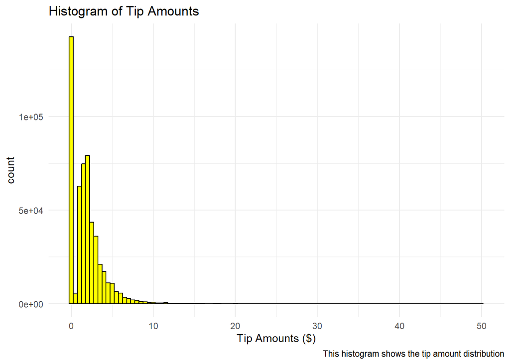

```r
# histogram of tip amounts
ggplot(taxi_clean, aes(x = tip_amount)) +
    geom_histogram(binwidth = 0.5, fill = "yellow", color = "black") +
    labs(title = "Histogram of Tip Amounts",
         x = "Tip Amounts ($)",
         caption = "This histogram shows the tip amount distribution") +
    theme_minimal()
```

Tip amounts is very right skewed, especially because there are so many $0 tip amounts

```r
# outliers in tolls amount
toll_outliers <- find_outliers(taxi_clean, "tolls_amount")
dim(toll_outliers)
```

```
## [1] 9166   26
```

```r
head(toll_outliers)
```

| VendorID | lpep_pickup_datetime | lpep_dropoff_datetime | store_and_fwd_flag | RatecodeID | PULocationID | DOLocationID | passenger_count | trip_distance | fare_amount | extra | mta_tax | tip_amount | tolls_amount | improvement_surcharge | total_amount | payment_type | trip_type | trip_duration_minutes | speed_of_taxi | pickup_day | pickup_hour | overnight_surcharge | rush_hour_surcharge | fare_by_distance | efficiency_ratio |
| --- | --- | --- | --- | --- | --- | --- | --- | --- | --- | --- | --- | --- | --- | --- | --- | --- | --- | --- | --- | --- | --- | --- | --- | --- | --- |
| 2 | 2018-01-12 13:56:00 | 2018-01-12 13:58:00 | N | 1 | 193 | 193 | 4 | 0.00 | 3.0 | 0 | 0.5 | 0 | 99.99 | 0.3 | 103.79 | 1 | 1 | 2 | 0.000000 | Friday | 13 | 0 | 0 | 0.0 | 0.000000 |
| 2 | 2018-01-12 14:14:00 | 2018-01-12 14:16:00 | N | 1 | 193 | 193 | 4 | 0.00 | 3.0 | 0 | 0.5 | 0 | 99.99 | 0.3 | 103.79 | 1 | 1 | 2 | 0.000000 | Friday | 14 | 0 | 0 | 0.0 | 0.000000 |
| 2 | 2018-01-12 14:21:00 | 2018-01-12 14:25:00 | N | 1 | 193 | 193 | 5 | 0.00 | 4.0 | 0 | 0.5 | 0 | 99.99 | 0.3 | 104.79 | 1 | 1 | 4 | 0.000000 | Friday | 14 | 0 | 0 | 0.0 | 0.000000 |
| 2 | 2018-01-15 10:34:00 | 2018-01-15 10:36:00 | N | 1 | 193 | 193 | 5 | 0.00 | 3.5 | 0 | 0.5 | 0 | 95.99 | 0.3 | 100.29 | 1 | 1 | 2 | 0.000000 | Monday | 10 | 0 | 0 | 0.0 | 0.000000 |
| 2 | 2018-01-26 23:10:00 | 2018-01-26 23:29:00 | N | 5 | 80 | 79 | 1 | 4.12 | 45.0 | 0 | 0.0 | 0 | 55.00 | 0.0 | 100.00 | 1 | 2 | 19 | 13.010526 | Friday | 23 | 1 | 0 | 10.3 | 4.126214 |
| 2 | 2018-02-06 06:35:00 | 2018-02-06 06:57:00 | N | 1 | 36 | 97 | 2 | 3.48 | 16.0 | 0 | 0.5 | 0 | 39.80 | 0.3 | 56.60 | 1 | 1 | 22 | 9.490909 | Tuesday | 6 | 0 | 0 | 8.7 | 1.551724 |

```r
tail(toll_outliers)
```

| VendorID | lpep_pickup_datetime | lpep_dropoff_datetime | store_and_fwd_flag | RatecodeID | PULocationID | DOLocationID | passenger_count | trip_distance | fare_amount | extra | mta_tax | tip_amount | tolls_amount | improvement_surcharge | total_amount | payment_type | trip_type | trip_duration_minutes | speed_of_taxi | pickup_day | pickup_hour | overnight_surcharge | rush_hour_surcharge | fare_by_distance | efficiency_ratio |
| --- | --- | --- | --- | --- | --- | --- | --- | --- | --- | --- | --- | --- | --- | --- | --- | --- | --- | --- | --- | --- | --- | --- | --- | --- | --- |
| 2 | 2018-02-08 08:12:00 | 2018-02-08 09:08:00 | N | 1 | 117 | 196 | 1 | 17.46 | 54.5 | 0.0 | 0.5 | 0.00 | 4.25 | 0.3 | 59.55 | 1 | 1 | 56 | 18.707143 | Thursday | 8 | 0 | 0 | 43.650 | 1.191294 |
| 1 | 2018-01-16 22:12:00 | 2018-01-16 22:31:00 | N | 1 | 25 | 224 | 1 | 5.90 | 19.0 | 0.5 | 0.5 | 0.00 | 4.00 | 0.3 | 24.30 | 1 | 1 | 19 | 18.631579 | Tuesday | 22 | 1 | 0 | 14.750 | 1.118644 |
| 2 | 2018-01-31 14:56:00 | 2018-01-31 15:49:00 | N | 1 | 130 | 130 | 2 | 5.34 | 34.5 | 0.0 | 0.5 | 9.82 | 4.00 | 0.3 | 49.12 | 1 | 1 | 53 | 6.045283 | Wednesday | 14 | 0 | 0 | 13.350 | 2.397004 |
| 1 | 2018-01-14 04:51:00 | 2018-01-14 05:07:00 | N | 1 | 181 | 71 | 1 | 4.00 | 14.5 | 0.5 | 0.5 | 0.00 | 3.16 | 0.3 | 18.96 | 1 | 1 | 16 | 15.000000 | Sunday | 4 | 1 | 0 | 10.000 | 1.200000 |
| 1 | 2018-01-14 09:55:00 | 2018-01-14 09:58:00 | N | 1 | 25 | 181 | 1 | 0.60 | 4.5 | 0.0 | 0.5 | 0.00 | 3.00 | 0.3 | 8.30 | 1 | 1 | 3 | 12.000000 | Sunday | 9 | 0 | 0 | 1.500 | 1.333333 |
| 2 | 2018-01-06 15:06:00 | 2018-01-06 15:55:00 | N | 1 | 188 | 197 | 1 | 10.19 | 39.0 | 0.0 | 0.0 | 0.00 | 2.75 | 0.0 | 41.75 | 1 | 2 | 49 | 12.477551 | Saturday | 15 | 0 | 0 | 25.475 | 1.432777 |

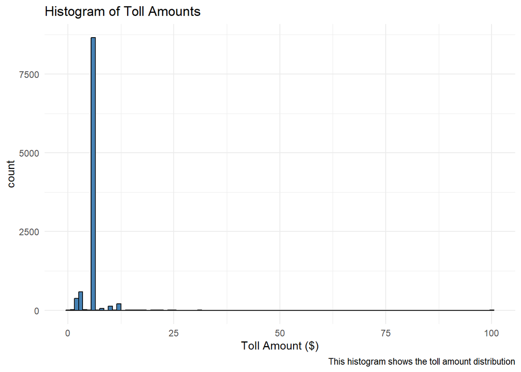

```r
# create histogram, filter out zeros first because skews graph too much to evaluate everything else
taxi_clean %>%
    filter(tolls_amount > 0) %>%
    ggplot(aes(x = tolls_amount)) +
    geom_histogram(binwidth = 1, fill = "steelblue", color = "black") +
    labs(title = "Histogram of Toll Amounts",
         x = "Toll Amount ($)",
         caption = "This histogram shows the toll amount distribution") +
    theme_minimal()
```

```r
taxi_clean %>%
    filter(tolls_amount > 0) %>%
    pull(tolls_amount) %>%
    median()
```

```
## [1] 5.76
```

Right skewed with over 7500 with same amount $5.76. Seems reasonable to remove any tolls over 25 based on histogram

```r
# remove toll amounts $25 or above
taxi_final <- taxi_clean %>%
    filter(tolls_amount < 25)

summary(taxi_final)
```

```
##  VendorID   lpep_pickup_datetime             lpep_dropoff_datetime
##  1: 86665   Min.   :2018-01-01 00:00:00.00   Min.   :2018-01-01 00:06:00.00
##  2:445190   1st Qu.:2018-01-12 17:35:00.00   1st Qu.:2018-01-12 17:54:00.00
##             Median :2018-01-22 15:01:00.00   Median :2018-01-22 15:20:00.00
##             Mean   :2018-01-22 05:52:08.03   Mean   :2018-01-22 06:06:52.83
##             3rd Qu.:2018-02-01 00:30:00.00   3rd Qu.:2018-02-01 00:40:00.00
##             Max.   :2018-04-05 04:11:00.00   Max.   :2018-04-05 04:25:00.00
##
##  store_and_fwd_flag RatecodeID  PULocationID  DOLocationID   passenger_count
##  N:531178           1:528157   Min.   :  1   Min.   :  1.0   Min.   :1.000
##  Y:   677           2:   819   1st Qu.: 49   1st Qu.: 62.0   1st Qu.:1.000
##                     3:   179   Median : 82   Median :132.0   Median :1.000
##                     4:   328   Mean   :110   Mean   :131.6   Mean   :1.357
##                     5:  2372   3rd Qu.:166   3rd Qu.:196.0   3rd Qu.:1.000
##                     6:     0   Max.   :265   Max.   :265.0   Max.   :6.000
##
##  trip_distance      fare_amount         extra           mta_tax
##  Min.   :  0.000   Min.   :  2.50   Min.   :0.0000   Min.   :0.0000
##  1st Qu.:  1.170   1st Qu.:  7.00   1st Qu.:0.0000   1st Qu.:0.5000
##  Median :  2.090   Median : 10.50   Median :0.0000   Median :0.5000
##  Mean   :  3.145   Mean   : 13.29   Mean   :0.3403   Mean   :0.4975
##  3rd Qu.:  3.930   3rd Qu.: 16.50   3rd Qu.:0.5000   3rd Qu.:0.5000
##  Max.   :113.720   Max.   :376.00   Max.   :4.5000   Max.   :0.5000
##
##    tip_amount      tolls_amount     improvement_surcharge  total_amount
##  Min.   : 0.000   Min.   : 0.0000   Min.   :0.0000        Min.   :  3.30
##  1st Qu.: 0.000   1st Qu.: 0.0000   1st Qu.:0.3000        1st Qu.:  9.30
##  Median : 1.580   Median : 0.0000   Median :0.3000        Median : 13.00
##  Mean   : 1.878   Mean   : 0.1087   Mean   :0.2986        Mean   : 16.46
##  3rd Qu.: 2.600   3rd Qu.: 0.0000   3rd Qu.:0.3000        3rd Qu.: 20.16
##  Max.   :50.000   Max.   :24.0200   Max.   :0.3000        Max.   :382.56
##
##  payment_type trip_type  trip_duration_minutes speed_of_taxi
##  1:531855     1:529363   Min.   :  2.00        Min.   :  0.000
##  2:     0     2:  2492   1st Qu.:  7.00        1st Qu.:  8.829
##  3:     0                Median : 12.00        Median : 11.133
##  4:     0                Mean   : 14.75        Mean   : 12.364
##  5:     0                3rd Qu.: 19.00        3rd Qu.: 14.431
##                          Max.   :173.00        Max.   :495.000
##
##      pickup_day     pickup_hour    overnight_surcharge rush_hour_surcharge
##  Sunday   :60391   Min.   : 0.00   Min.   :0.0000      Min.   :0.0000
##  Monday   :70391   1st Qu.: 9.00   1st Qu.:0.0000      1st Qu.:0.0000
##  Tuesday  :77188   Median :15.00   Median :0.0000      Median :0.0000
##  Wednesday:82664   Mean   :13.87   Mean   :0.2807      Mean   :0.2064
##  Thursday :76241   3rd Qu.:19.00   3rd Qu.:1.0000      3rd Qu.:0.0000
##  Friday   :91930   Max.   :23.00   Max.   :1.0000      Max.   :1.0000
##  Saturday :73050
##  fare_by_distance  efficiency_ratio
##  Min.   :  0.000   Min.   : 0.000
##  1st Qu.:  2.925   1st Qu.: 1.209
##  Median :  5.225   Median : 1.377
##  Mean   :  7.863   Mean   : 1.422
##  3rd Qu.:  9.825   3rd Qu.: 1.589
##  Max.   :284.300   Max.   :23.567
##
```

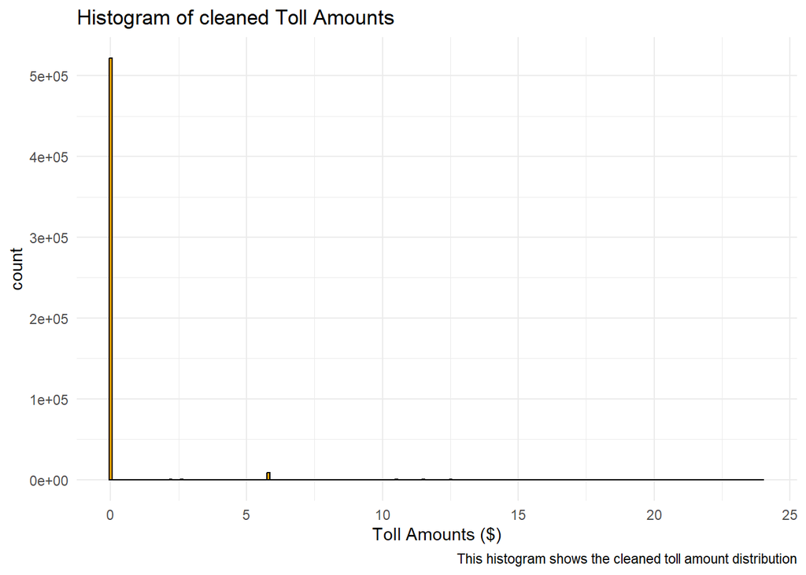

```r
# histogram of cleaned toll amounts
ggplot(taxi_final, aes(x = tolls_amount)) +
    geom_histogram(binwidth = 0.1, fill = "orange", color = "black") +
    labs(title = "Histogram of cleaned Toll Amounts",
         x = "Toll Amounts ($)",
         caption = "This histogram shows the cleaned toll amount distribution") +
    theme_minimal()
```

Very right skewed with most toll amounts being zero. We can also see the common toll amount of $5.76.

```r
# find outliers of total amount
total_outliers <- find_outliers(taxi_final, "total_amount")
dim(total_outliers)
```

```
## [1] 9897   26
```

```r
head(total_outliers)
```

| VendorID | lpep_pickup_datetime | lpep_dropoff_datetime | store_and_fwd_flag | RatecodeID | PULocationID | DOLocationID | passenger_count | trip_distance | fare_amount | extra | mta_tax | tip_amount | tolls_amount | improvement_surcharge | total_amount | payment_type | trip_type | trip_duration_minutes | speed_of_taxi | pickup_day | pickup_hour | overnight_surcharge | rush_hour_surcharge | fare_by_distance | efficiency_ratio |
| --- | --- | --- | --- | --- | --- | --- | --- | --- | --- | --- | --- | --- | --- | --- | --- | --- | --- | --- | --- | --- | --- | --- | --- | --- | --- |
| 2 | 2018-01-19 15:13:00 | 2018-01-19 18:02:00 | N | 4 | 130 | 265 | 1 | 113.72 | 376.0 | 0 | 0.5 | 0 | 5.76 | 0.3 | 382.56 | 1 | 1 | 169 | 40.37396 | Friday | 15 | 0 | 0 | 284.300 | 1.313753 |
| 2 | 2018-01-24 16:27:00 | 2018-01-24 18:15:00 | N | 4 | 260 | 265 | 1 | 63.92 | 299.5 | 1 | 0.5 | 0 | 18.26 | 0.3 | 319.56 | 1 | 1 | 108 | 35.51111 | Wednesday | 16 | 0 | 1 | 159.800 | 1.858573 |
| 1 | 2018-01-28 19:59:00 | 2018-01-28 21:15:00 | N | 5 | 255 | 265 | 1 | 44.30 | 250.0 | 0 | 0.0 | 40 | 12.50 | 0.0 | 302.50 | 1 | 2 | 76 | 34.97368 | Sunday | 19 | 0 | 0 | 110.750 | 2.234763 |
| 2 | 2018-01-07 09:24:00 | 2018-01-07 10:19:00 | N | 4 | 244 | 265 | 1 | 47.73 | 239.5 | 0 | 0.5 | 5 | 10.50 | 0.3 | 255.80 | 1 | 1 | 55 | 52.06909 | Sunday | 9 | 0 | 0 | 119.325 | 1.986172 |
| 1 | 2018-01-26 20:46:00 | 2018-01-26 22:07:00 | N | 5 | 195 | 265 | 1 | 61.30 | 200.0 | 0 | 0.0 | 50 | 0.00 | 0.0 | 250.00 | 1 | 2 | 81 | 45.40741 | Friday | 20 | 1 | 0 | 153.250 | 1.288744 |
| 2 | 2018-01-17 11:43:00 | 2018-01-17 12:59:00 | N | 4 | 130 | 265 | 1 | 48.59 | 229.0 | 0 | 0.5 | 10 | 0.00 | 0.3 | 239.80 | 1 | 1 | 76 | 38.36053 | Wednesday | 11 | 0 | 0 | 121.475 | 1.864581 |

```r
tail(total_outliers)
```

| VendorID | lpep_pickup_datetime | lpep_dropoff_datetime | store_and_fwd_flag | RatecodeID | PULocationID | DOLocationID | passenger_count | trip_distance | fare_amount | extra | mta_tax | tip_amount | tolls_amount | improvement_surcharge | total_amount | payment_type | trip_type | trip_duration_minutes | speed_of_taxi | pickup_day | pickup_hour | overnight_surcharge | rush_hour_surcharge | fare_by_distance | efficiency_ratio |
| --- | --- | --- | --- | --- | --- | --- | --- | --- | --- | --- | --- | --- | --- | --- | --- | --- | --- | --- | --- | --- | --- | --- | --- | --- | --- |
| 2 | 2018-02-07 20:35:00 | 2018-02-07 21:01:00 | N | 1 | 75 | 134 | 1 | 13.51 | 38.0 | 0.5 | 0.5 | 4.00 | 5.76 | 0.3 | 49.06 | 1 | 1 | 26 | 31.176923 | Wednesday | 20 | 1 | 0 | 33.775 | 1.051073 |
| 2 | 2018-02-08 07:31:00 | 2018-02-08 08:14:00 | N | 1 | 95 | 87 | 1 | 12.93 | 42.5 | 0.0 | 0.5 | 0.00 | 5.76 | 0.3 | 49.06 | 1 | 1 | 43 | 18.041860 | Thursday | 7 | 0 | 0 | 32.325 | 1.237432 |
| 2 | 2018-02-09 08:38:00 | 2018-02-09 09:36:00 | N | 1 | 242 | 233 | 1 | 10.60 | 42.5 | 0.0 | 0.5 | 0.00 | 5.76 | 0.3 | 49.06 | 1 | 1 | 58 | 10.965517 | Friday | 8 | 0 | 0 | 26.500 | 1.509434 |
| 2 | 2018-02-09 09:12:00 | 2018-02-09 09:36:00 | N | 1 | 82 | 167 | 1 | 12.40 | 35.0 | 0.0 | 0.5 | 7.50 | 5.76 | 0.3 | 49.06 | 1 | 1 | 24 | 31.000000 | Friday | 9 | 0 | 0 | 31.000 | 1.048387 |
| 2 | 2018-01-31 20:29:00 | 2018-01-31 20:58:00 | N | 1 | 166 | 112 | 1 | 11.12 | 34.5 | 0.5 | 0.5 | 7.48 | 5.76 | 0.3 | 49.04 | 1 | 1 | 29 | 23.006897 | Wednesday | 20 | 1 | 0 | 27.800 | 1.151079 |
| 2 | 2018-01-08 17:20:00 | 2018-01-08 18:26:00 | N | 1 | 49 | 49 | 1 | 7.67 | 41.0 | 1.0 | 0.5 | 4.28 | 0.00 | 0.3 | 49.03 | 1 | 1 | 66 | 6.972727 | Monday | 17 | 0 | 1 | 19.175 | 2.007823 |

Highest outlier it correlated with longest distance and therefore no removals needed

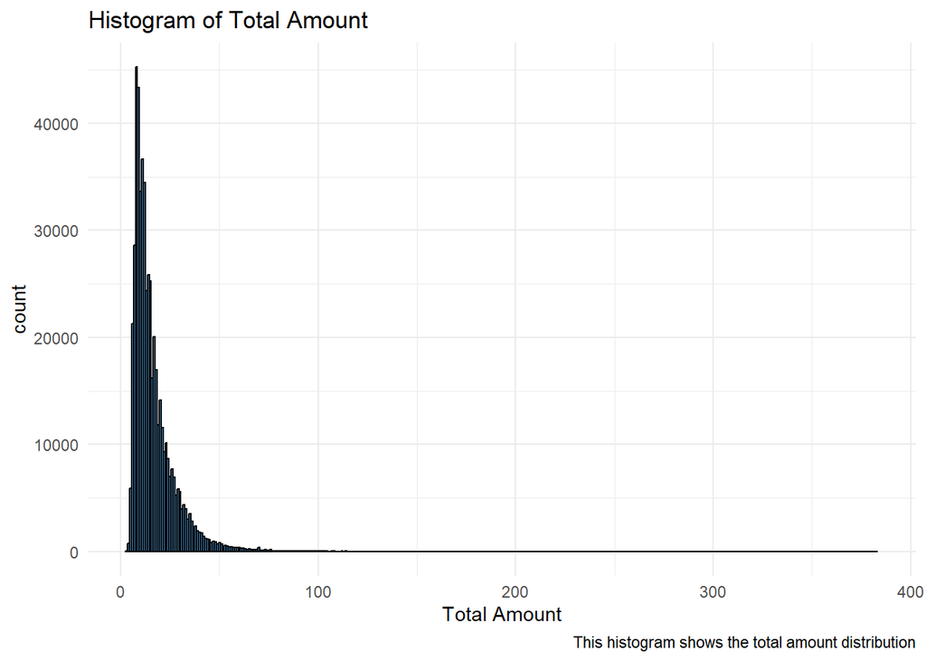

```r
# create histogram of total_amount
ggplot(taxi_final, aes(x = total_amount)) +
    geom_histogram(binwidth = 1, fill = "steelblue", color = "black") +
    labs(title = "Histogram of Total Amount",
         x = "Total Amount",
         caption = "This histogram shows the total amount distribution") +
    theme_minimal()
```

Very right skewed but there were some long trips that cost a lot.

```r
summary(taxi_final)
```

```
##  VendorID   lpep_pickup_datetime             lpep_dropoff_datetime
##  1: 86665   Min.   :2018-01-01 00:00:00.00   Min.   :2018-01-01 00:06:00.00
##  2:445190   1st Qu.:2018-01-12 17:35:00.00   1st Qu.:2018-01-12 17:54:00.00
##             Median :2018-01-22 15:01:00.00   Median :2018-01-22 15:20:00.00
##             Mean   :2018-01-22 05:52:08.03   Mean   :2018-01-22 06:06:52.83
##             3rd Qu.:2018-02-01 00:30:00.00   3rd Qu.:2018-02-01 00:40:00.00
##             Max.   :2018-04-05 04:11:00.00   Max.   :2018-04-05 04:25:00.00
##
##  store_and_fwd_flag RatecodeID  PULocationID  DOLocationID   passenger_count
##  N:531178           1:528157   Min.   :  1   Min.   :  1.0   Min.   :1.000
##  Y:   677           2:   819   1st Qu.: 49   1st Qu.: 62.0   1st Qu.:1.000
##                     3:   179   Median : 82   Median :132.0   Median :1.000
##                     4:   328   Mean   :110   Mean   :131.6   Mean   :1.357
##                     5:  2372   3rd Qu.:166   3rd Qu.:196.0   3rd Qu.:1.000
##                     6:     0   Max.   :265   Max.   :265.0   Max.   :6.000
##
##  trip_distance      fare_amount         extra           mta_tax
##  Min.   :  0.000   Min.   :  2.50   Min.   :0.0000   Min.   :0.0000
##  1st Qu.:  1.170   1st Qu.:  7.00   1st Qu.:0.0000   1st Qu.:0.5000
##  Median :  2.090   Median : 10.50   Median :0.0000   Median :0.5000
##  Mean   :  3.145   Mean   : 13.29   Mean   :0.3403   Mean   :0.4975
##  3rd Qu.:  3.930   3rd Qu.: 16.50   3rd Qu.:0.5000   3rd Qu.:0.5000
##  Max.   :113.720   Max.   :376.00   Max.   :4.5000   Max.   :0.5000
##
##    tip_amount      tolls_amount     improvement_surcharge  total_amount
##  Min.   : 0.000   Min.   : 0.0000   Min.   :0.0000        Min.   :  3.30
##  1st Qu.: 0.000   1st Qu.: 0.0000   1st Qu.:0.3000        1st Qu.:  9.30
##  Median : 1.580   Median : 0.0000   Median :0.3000        Median : 13.00
##  Mean   : 1.878   Mean   : 0.1087   Mean   :0.2986        Mean   : 16.46
##  3rd Qu.: 2.600   3rd Qu.: 0.0000   3rd Qu.:0.3000        3rd Qu.: 20.16
##  Max.   :50.000   Max.   :24.0200   Max.   :0.3000        Max.   :382.56
##
##  payment_type trip_type  trip_duration_minutes speed_of_taxi
##  1:531855     1:529363   Min.   :  2.00        Min.   :  0.000
##  2:     0     2:  2492   1st Qu.:  7.00        1st Qu.:  8.829
##  3:     0                Median : 12.00        Median : 11.133
##  4:     0                Mean   : 14.75        Mean   : 12.364
##  5:     0                3rd Qu.: 19.00        3rd Qu.: 14.431
##                          Max.   :173.00        Max.   :495.000
##
##      pickup_day     pickup_hour    overnight_surcharge rush_hour_surcharge
##  Sunday   :60391   Min.   : 0.00   Min.   :0.0000      Min.   :0.0000
##  Monday   :70391   1st Qu.: 9.00   1st Qu.:0.0000      1st Qu.:0.0000
##  Tuesday  :77188   Median :15.00   Median :0.0000      Median :0.0000
##  Wednesday:82664   Mean   :13.87   Mean   :0.2807      Mean   :0.2064
##  Thursday :76241   3rd Qu.:19.00   3rd Qu.:1.0000      3rd Qu.:0.0000
##  Friday   :91930   Max.   :23.00   Max.   :1.0000      Max.   :1.0000
##  Saturday :73050
##  fare_by_distance  efficiency_ratio
##  Min.   :  0.000   Min.   : 0.000
##  1st Qu.:  2.925   1st Qu.: 1.209
##  Median :  5.225   Median : 1.377
##  Mean   :  7.863   Mean   : 1.422
##  3rd Qu.:  9.825   3rd Qu.: 1.589
##  Max.   :284.300   Max.   :23.567
##
```

```r
# Set a random seed for reproducibility
set.seed(123)
sampled_df <- sample_n(taxi_final, 1000)
```

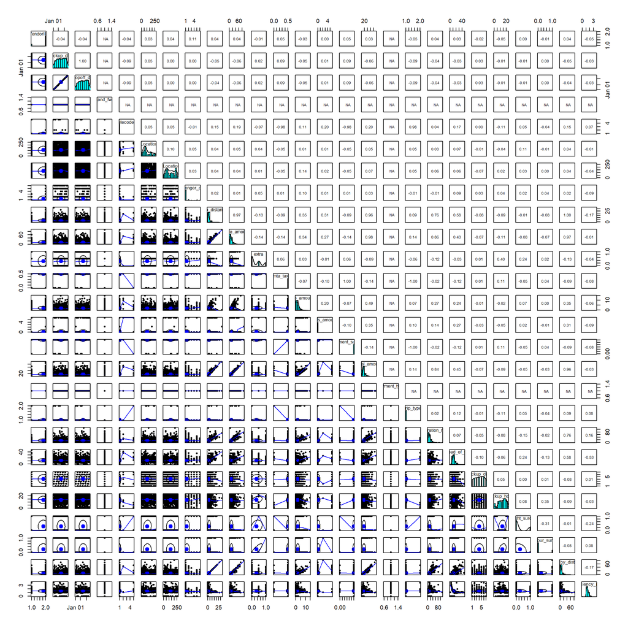

```r
# Sample 1000 random rows
pairs.panels(sampled_df)
```

```r
# correlation of numeric variables
cor(taxi_final[c("passenger_count", "trip_distance", "fare_amount", "extra", "mta_tax", "tip_amount", "tolls_amount", "improvement_surcharge", "total_amount", "trip_duration_minutes", "speed_of_taxi", "efficiency_ratio")])
```

```
##                       passenger_count trip_distance  fare_amount        extra
## passenger_count          1.0000000000  -0.001417195 -0.003075433  0.006813368
## trip_distance           -0.0014171950   1.000000000  0.961354666 -0.063433371
## fare_amount             -0.0030754326   0.961354666  1.000000000 -0.079158269
## extra                    0.0068133680  -0.063433371 -0.079158269  1.000000000
## mta_tax                  0.0068372296  -0.073440256 -0.117446761  0.055271612
## tip_amount               0.0071753352   0.417946634  0.399198898  0.045838064
## tolls_amount             0.0066488061   0.323399785  0.299349465 -0.013537770
## improvement_surcharge    0.0060202318  -0.053849208 -0.094169924  0.055384955
## total_amount            -0.0001836074   0.952167998  0.980697730 -0.027497300
## trip_duration_minutes   -0.0034334374   0.790793214  0.900345069 -0.073296662
## speed_of_taxi            0.0052196104   0.581576020  0.418430876 -0.015432663
## efficiency_ratio        -0.0075973264  -0.128926528  0.030678621 -0.037215831
##                           mta_tax   tip_amount tolls_amount
## passenger_count        0.00683723  0.007175335  0.006648806
## trip_distance         -0.07344026  0.417946634  0.323399785
## fare_amount           -0.11744676  0.399198898  0.299349465
## extra                  0.05527161  0.045838064 -0.013537770
## mta_tax                1.00000000 -0.055355685 -0.080642776
## tip_amount            -0.05535568  1.000000000  0.251524529
## tolls_amount          -0.08064278  0.251524529  1.000000000
## improvement_surcharge  0.94597478 -0.032416229 -0.026278994
## total_amount          -0.11308935  0.552922408  0.386039566
## trip_duration_minutes -0.03344562  0.312697622  0.194457605
## speed_of_taxi         -0.07543332  0.289772401  0.216113212
## efficiency_ratio      -0.09080818 -0.045135536 -0.055709932
##                       improvement_surcharge  total_amount trip_duration_minutes
## passenger_count                 0.006020232 -0.0001836074          -0.003433437
## trip_distance                  -0.053849208  0.9521679980           0.790793214
## fare_amount                    -0.094169924  0.9806977302           0.900345069
## extra                           0.055384955 -0.0274973002          -0.073296662
## mta_tax                         0.945974776 -0.1130893503          -0.033445622
## tip_amount                     -0.032416229  0.5529224081           0.312697622
## tolls_amount                   -0.026278994  0.3860395660           0.194457605
## improvement_surcharge           1.000000000 -0.0843061204          -0.023197371
## total_amount                   -0.084306120  1.0000000000           0.869547881
## trip_duration_minutes          -0.023197371  0.8695478806           1.000000000
## speed_of_taxi                  -0.066147124  0.4388820622           0.102417826
## efficiency_ratio               -0.088775913  0.0134883782           0.188544009
##                       speed_of_taxi efficiency_ratio
## passenger_count          0.00521961     -0.007597326
## trip_distance            0.58157602     -0.128926528
## fare_amount              0.41843088      0.030678621
## extra                   -0.01543266     -0.037215831
## mta_tax                 -0.07543332     -0.090808178
## tip_amount               0.28977240     -0.045135536
## tolls_amount             0.21611321     -0.055709932
## improvement_surcharge   -0.06614712     -0.088775913
## total_amount             0.43888206      0.013488378
## trip_duration_minutes    0.10241783      0.188544009
## speed_of_taxi            1.00000000     -0.452547859
## efficiency_ratio        -0.45254786      1.000000000
```

To include in our model we selected passenger_count, log_trip_distance, log_fare_amount, tip_amount, log_total_amount, log_fare_by_distance, efficiency_ratio, log_speed_of_taxi, overnight_surcharge, rush_hour_surcharge. We did not include VendorID because it has a very low correlation with tip amount of -0.03. We did not include pick up or drop off time because we used the times to determine if there was a surcharge for overnight or rush hour and the columns themselves had very low correlation with tip amount -0.05. store_and_fwd_flag does not have anything to do with the trip, passenger or cost and is irrelevant to the model. We excluded RatecodeID because it had a low correlation with tip amount of 0.11. We chose to leave pick up location and drop off location as numeric as there were about 265 different locations. Pickup Location also had a very low correlation to tip_amount of 0.01. To be used in the model they would need to be factors converted dummy variables and this would have greatly complicated the analysis. We excluded extra because of the low correlation with tip amount of 0.03. We excluded mta_tax because of the low correlation with tip amount of -0.07. We excluded improvement_surcharge because of the low correlation with tip amount of -0.07. We excluded payment_type because our final data frame only included type 1, credit card. We excluded trip_type because of the low correlation with tip amount of 0.07. We excluded trip_duration_minutes since this influences the efficiency_ratio. We excluded pickup_day because of the low correlation with tip amount of 0.01. We excluded pickup_hour because of the low correlation with tip amount of 0.02. We decided to not include toll_amounts because when we added it the k value went down to 3. Tolls_amount mostly was $0 which may be the reason for worsening the model. We did log conversion of trip_distance, fare_amount, total_amount, fare_by_distance, speed of taxi to make these columns of data more normalized before using min-max normalization.

# Question 2

### Normalize the data

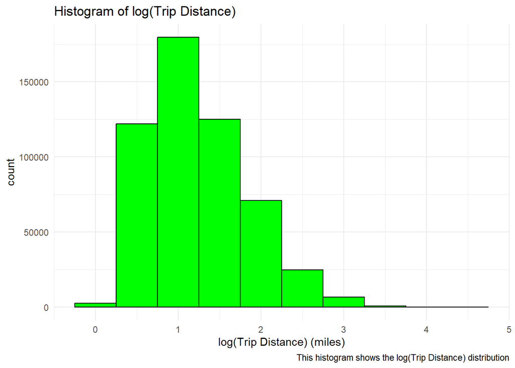

```r
# log trip_distance
taxi_final$log_trip_distance <- log(taxi_final$trip_distance+1)
# histogram of log(trip distance)
taxi_final %>%
  ggplot(aes(log_trip_distance)) +
  geom_histogram(binwidth = 0.5, fill = "green", color = "black") +
  labs(title = "Histogram of log(Trip Distance)",
       x = "log(Trip Distance) (miles)",
       caption = "This histogram shows the log(Trip Distance) distribution") +
  theme_minimal()
```

Improves distribution.

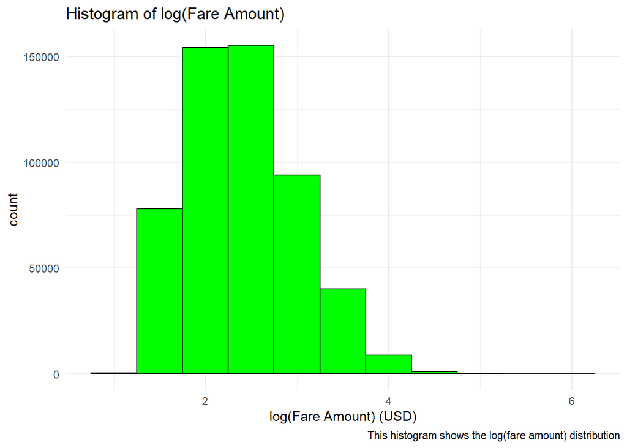

```r
# log fare_amount
taxi_final$log_fare_amount <- log(taxi_final$fare_amount)
# histogram of log(fare amount)
taxi_final %>%
  ggplot(aes(log_fare_amount)) +
  geom_histogram(binwidth = 0.5, fill = "green", color = "black") +
  labs(title = "Histogram of log(Fare Amount)",
       x = "log(Fare Amount) (USD)",
       caption = "This histogram shows the log(fare amount) distribution") +
  theme_minimal()
```

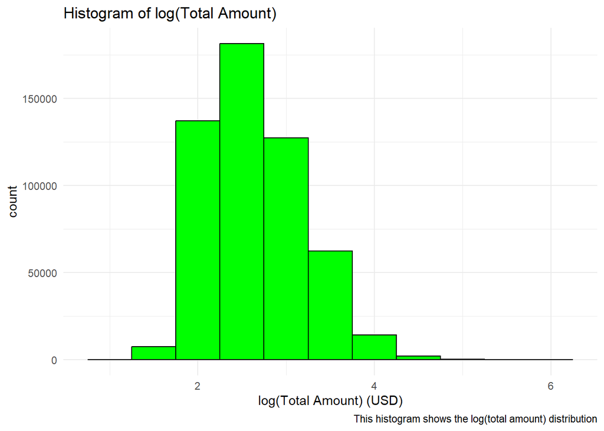

```r
# log total_amount
taxi_final$log_total_amount <- log(taxi_final$total_amount)
# histogram of log(total amount)
taxi_final %>%
  ggplot(aes(log_total_amount)) +
  geom_histogram(binwidth = 0.5, fill = "green", color = "black") +
  labs(title = "Histogram of log(Total Amount)",
       x = "log(Total Amount) (USD)",
       caption = "This histogram shows the log(total amount) distribution") +
  theme_minimal()
```

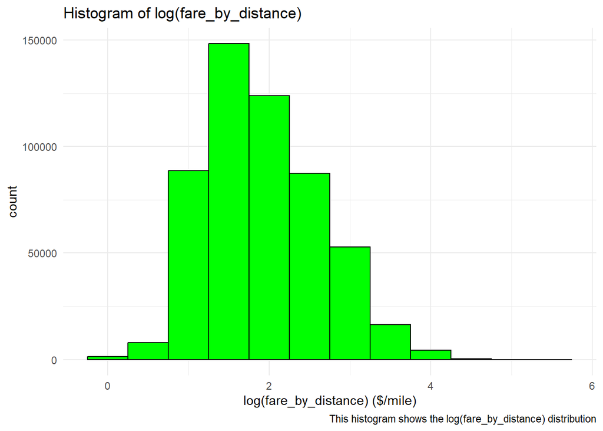

```r
# log fare_by_distance
taxi_final$log_fare_by_distance <- log(taxi_final$fare_by_distance+1)
# histogram of log(fare_by_distance)
taxi_final %>%
  ggplot(aes(log_fare_by_distance)) +
  geom_histogram(binwidth = 0.5, fill = "green", color = "black") +
  labs(title = "Histogram of log(fare_by_distance)",
       x = "log(fare_by_distance) ($/mile)",
       caption = "This histogram shows the log(fare_by_distance) distribution") +
  theme_minimal()
```

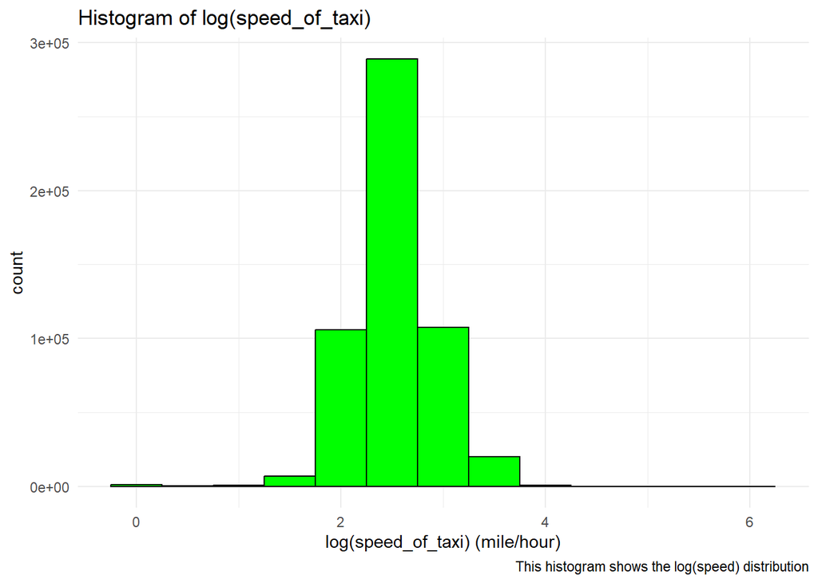

```r
# log(speed)
taxi_final$log_speed_of_taxi <- log(taxi_final$speed_of_taxi+1)
# histogram of log(speed_of_taxi)
taxi_final %>%
  ggplot(aes(log_speed_of_taxi)) +
  geom_histogram(binwidth = 0.5, fill = "green", color = "black") +
  labs(title = "Histogram of log(speed_of_taxi)",
       x = "log(speed_of_taxi) (mile/hour)",
       caption = "This histogram shows the log(speed) distribution") +
  theme_minimal()
```

```r
# Min-Max scaling to fixed range 0 to 1, smaller standard deviations
preproc <- preProcess(taxi_final[,c("passenger_count", "log_trip_distance", "log_fare_amount", "tip_amount", "log_total_amount", "log_fare_by_distance", "efficiency_ratio", "log_speed_of_taxi", "overnight_surcharge", "rush_hour_surcharge")], method=c("range"))
taxi_norm <- predict(preproc, taxi_final[,c("passenger_count", "log_trip_distance", "log_fare_amount", "tip_amount","log_total_amount", "log_fare_by_distance", "efficiency_ratio", "log_speed_of_taxi", "overnight_surcharge", "rush_hour_surcharge")])
# Now min is 0 and max is 1
summary(taxi_norm)
```

```
##  passenger_count   log_trip_distance log_fare_amount    tip_amount
##  Min.   :0.00000   Min.   :0.0000    Min.   :0.0000   Min.   :0.00000
##  1st Qu.:0.00000   1st Qu.:0.1634    1st Qu.:0.2054   1st Qu.:0.00000
##  Median :0.00000   Median :0.2379    Median :0.2863   Median :0.03160
##  Mean   :0.07142   Mean   :0.2592    Mean   :0.2942   Mean   :0.03756
##  3rd Qu.:0.00000   3rd Qu.:0.3364    3rd Qu.:0.3764   3rd Qu.:0.05200
##  Max.   :1.00000   Max.   :1.0000    Max.   :1.0000   Max.   :1.00000
##  log_total_amount log_fare_by_distance efficiency_ratio  log_speed_of_taxi
##  Min.   :0.0000   Min.   :0.0000       Min.   :0.00000   Min.   :0.0000
##  1st Qu.:0.2180   1st Qu.:0.2419       1st Qu.:0.05131   1st Qu.:0.3682
##  Median :0.2885   Median :0.3234       Median :0.05845   Median :0.4021
##  Mean   :0.3046   Mean   :0.3378       Mean   :0.06034   Mean   :0.4056
##  3rd Qu.:0.3808   3rd Qu.:0.4213       3rd Qu.:0.06744   3rd Qu.:0.4409
##  Max.   :1.0000   Max.   :1.0000       Max.   :1.00000   Max.   :1.0000
##  overnight_surcharge rush_hour_surcharge
##  Min.   :0.0000      Min.   :0.0000
##  1st Qu.:0.0000      1st Qu.:0.0000
##  Median :0.0000      Median :0.0000
##  Mean   :0.2807      Mean   :0.2064
##  3rd Qu.:1.0000      3rd Qu.:0.0000
##  Max.   :1.0000      Max.   :1.0000
```

Applying normalization, log transformation, and min-max scaling before using KNN (K-Nearest Neighbors) is an important data preprocessing sequence that helps improve model performance. Log Transformation is often applied first to handle skewed data distributions which makes highly skewed distributions more symmetric, it is especially useful for data with positive values spanning several orders of magnitude. After log transformation, applying min-max scaling to put all features on the same scale of 0 to 1. This step ensures no single feature dominates the distance calculations in KNN. Without proper scaling, features with larger ranges would dominate the distance calculation. Unscaled data can lead to poor performance because of this distance bias. This preprocessing sequence creates a more balanced feature space where KNN can function optimally by ensuring all features contribute appropriately to the nearest neighbor calculations.

### Prepare the data for modeling: shuffle the data and split it into training and test sets

```r
# Randomly shuffle the rows of the dataframe
taxi_shuffled <- taxi_norm[sample(nrow(taxi_norm)), ]

# Calculate the number of rows for training (70%)
train_size <- floor(0.7 * nrow(taxi_shuffled))

# Split into training and test sets
train_data <- taxi_shuffled[1:train_size, ]
test_data <- taxi_shuffled[(train_size + 1):nrow(taxi_shuffled), ]

# check the size of train and test data
nrow(train_data)
```

```
## [1] 372298
```

```r
nrow(test_data)
```

```
## [1] 159557
```

```r
# check the head of train and test, should be same everytime we run
head(train_data)
```

| passenger_count | log_trip_distance | log_fare_amount | tip_amount | log_total_amount | log_fare_by_distance | efficiency_ratio | log_speed_of_taxi | overnight_surcharge | rush_hour_surcharge |
| --- | --- | --- | --- | --- | --- | --- | --- | --- | --- |
| 0.0 | 0.2472290 | 0.2765234 | 0.0452 | 0.2973307 | 0.3331141 | 0.05708399 | 0.4152786 | 1 | 0 |
| 0.0 | 0.2517499 | 0.2955349 | 0.0000 | 0.2768119 | 0.3377604 | 0.06272620 | 0.3951181 | 1 | 0 |
| 0.0 | 0.2022881 | 0.2320131 | 0.0440 | 0.2533099 | 0.2855600 | 0.05798221 | 0.3967459 | 0 | 0 |
| 0.0 | 0.1167919 | 0.1382617 | 0.0340 | 0.1990640 | 0.1852501 | 0.05734112 | 0.3690461 | 0 | 1 |
| 0.8 | 0.4127098 | 0.5116291 | 0.1716 | 0.5489113 | 0.4926136 | 0.08374822 | 0.3326651 | 0 | 1 |
| 0.0 | 0.2054952 | 0.2191396 | 0.0000 | 0.2179886 | 0.2890455 | 0.05143325 | 0.4378467 | 0 | 1 |

```r
head(test_data)
```

| passenger_count | log_trip_distance | log_fare_amount | tip_amount | log_total_amount | log_fare_by_distance | efficiency_ratio | log_speed_of_taxi | overnight_surcharge | rush_hour_surcharge |
| --- | --- | --- | --- | --- | --- | --- | --- | --- | --- |
| 0.0 | 0.1043114 | 0.1382617 | 0.0316 | 0.1831290 | 0.1690111 | 0.06630068 | 0.3803795 | 1 | 0 |
| 0.8 | 0.3933857 | 0.4382792 | 0.0952 | 0.4540504 | 0.4748246 | 0.06217206 | 0.3897892 | 1 | 0 |
| 0.0 | 0.3236091 | 0.3823675 | 0.0732 | 0.3987618 | 0.4090419 | 0.06761212 | 0.3787855 | 1 | 0 |
| 0.2 | 0.1932086 | 0.2053776 | 0.0330 | 0.2322025 | 0.2756051 | 0.05091892 | 0.4235509 | 1 | 0 |
| 0.0 | 0.4203144 | 0.4469532 | 0.0992 | 0.4627098 | 0.4995720 | 0.05621963 | 0.4265471 | 1 | 0 |
| 0.0 | 0.4220311 | 0.4746468 | 0.1150 | 0.4941097 | 0.5011396 | 0.06497466 | 0.3878820 | 0 | 1 |

Here we shuffle the data randomizes the order of observations before splitting because it prevents any inherent ordering or patterns in our dataset from introducing bias, also it ensures both training and test sets contain representative samples of all classes or patterns. And then we split the data into separate training and test sets to evaluate model performance and prevent overfitting: By testing on data the model hasn’t seen during training, we can detect if it’s memorizing the training data rather than learning generalizable patterns. The 70/30 ratio (70% training, 30% testing) is a common default ratio. It balances having enough data to train effectively while retaining sufficient data to test properly. We consider it’s a reasonable compromise when working with limited datasets.

```r
knn.predict <- function(train_data, test_data, k, return_preds = FALSE) {
  # Separate features and target
  x_train <- train_data %>% select(-tip_amount)
  y_train <- train_data$tip_amount

  x_test <- test_data %>% select(-tip_amount)
  y_test <- test_data$tip_amount

  # Fit the k-NN model
  knn_model <- knn.reg(train = x_train, test = x_test, y = y_train, k = k)

  # Predictions
  predictions <- knn_model$pred

 if (return_preds) {
    return(data.frame(Actual = y_test, Predicted = predictions))
  }

  #Calculate Mean squared Error
  mse <- mean((y_test - predictions)^2)
  return(mse)
}
```

```r
# Evaluate MSE for k = 1 to 25
set.seed(123)  # for reproducibility
k_values <- sample(1:25, 20)
mse_values <- numeric(length(k_values))

for (i in seq_along(k_values)) {
  mse_values[i] <- knn.predict(train_data, test_data, k = k_values[i])
}

# Create a data frame for plotting
mse_df <- data.frame(k = k_values, MSE = mse_values)
```

```r
best_index <- which.min(mse_df$MSE)
best_point <- mse_df[best_index, ]
best_k <- mse_df$k[which.min(mse_df$MSE)]
best_mse <- min(mse_df$MSE)

cat("Best k:", best_k, "\nLowest MSE:", round(best_mse, 10))
```

```
## Best k: 5
## Lowest MSE: 0.0001628405
```

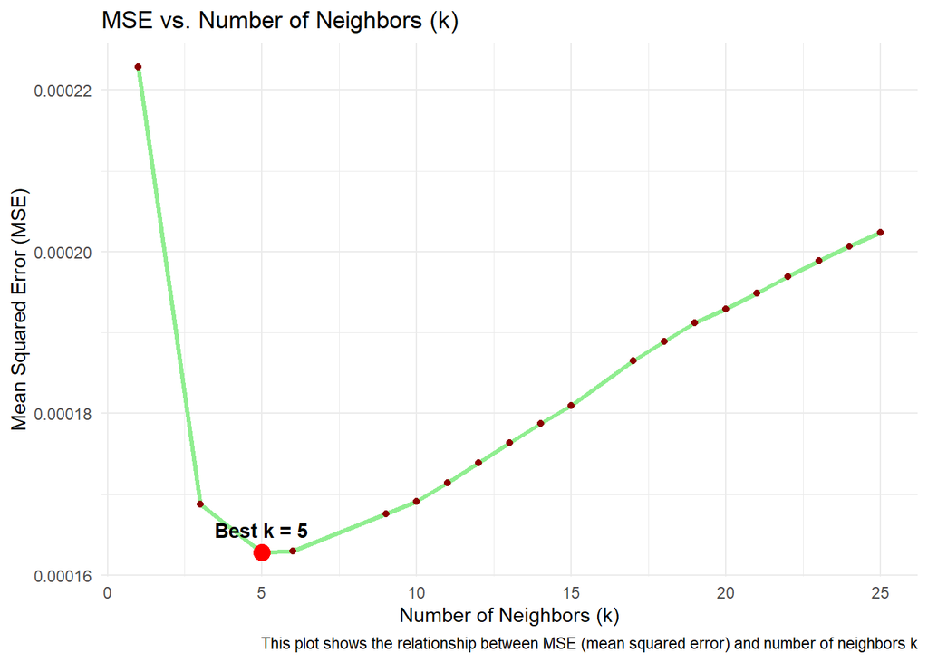

```r
ggplot(mse_df, aes(x = k, y = MSE)) +
  geom_line(size = 1.2, color = "lightgreen") +
  geom_point(color = "darkred") +
  geom_point(data = best_point, aes(x = k, y = MSE), color = "red", size = 4) +
  geom_text(data = best_point, aes(label = paste0("Best k = ", k)),
            vjust = -1.0, color = "black", fontface = "bold") +
  labs(
    title = "MSE vs. Number of Neighbors (k)",
    x = "Number of Neighbors (k)",
    y = "Mean Squared Error (MSE)",
    caption = "This plot shows the relationship between MSE (mean squared error) and number of neighbors k"
  ) +
  theme_minimal()
```

The MSE vs. k plot demonstrates that the KNN model achieves optimal predictive performance when k = 5. At this point, the model balances bias and variance effectively, avoiding over fitting (low k) and under fitting (high k). Thus, k = 5 is the most suitable value for deployment based on this analysis.

```r
pred_df <- knn.predict(train_data, test_data, k = best_k, return_preds = TRUE)
```

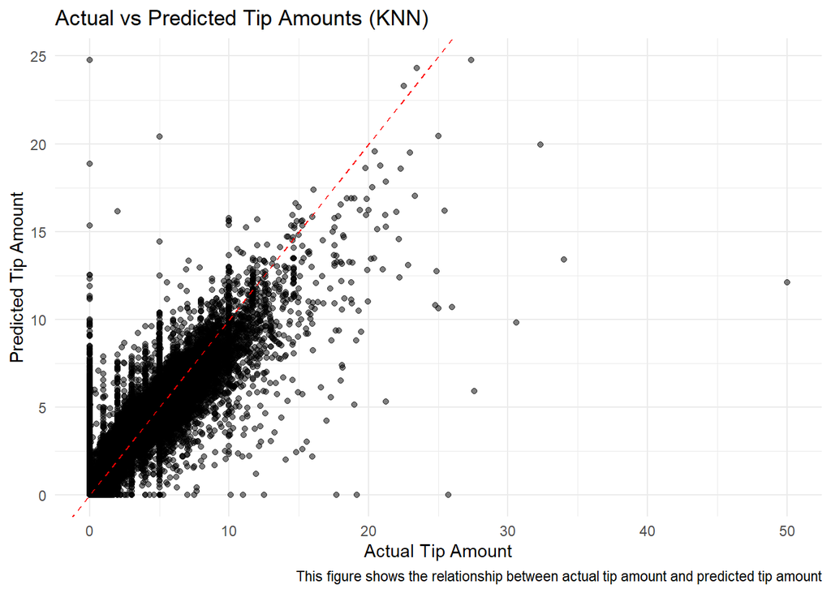

```r
# Create a function to reverse the normalization
reverse_normalization <- function(normalized_data, min_value, max_value, colnames) {
  original_data <- data.frame(matrix(nrow = nrow(normalized_data), ncol = ncol(normalized_data)))
  colnames(original_data) <- colnames(normalized_data)

  for (col in colnames) {
    original_data[,col] <- normalized_data[,col] * (max_value - min_value) + min_value
  }

  return(original_data)
}
# reverse the normalize tip amount
de_norm_pred_df <- reverse_normalization(pred_df, 0, 50, c("Predicted", "Actual"))
# visualize the predicted value vs actual value
ggplot(de_norm_pred_df, aes(x = Actual, y = Predicted)) +
  geom_point(alpha = 0.5) +
  geom_abline(slope = 1, intercept = 0, color = "red", linetype = "dashed") +
  labs(title = "Actual vs Predicted Tip Amounts (KNN)",
       x = "Actual Tip Amount",
       y = "Predicted Tip Amount",
       caption = "This figure shows the relationship between actual tip amount and predicted tip amount") +
  theme_minimal()
```

A significant number of points fall near the red dashed line, especially in the $5–$15 range. This indicates the model is capturing the relationship between trip features and tip amount fairly well. Most predicted values between $5 and $15 are relatively close to the actual. Dense clustering near the red line suggests the model performs reasonably well for frequent, small tips. Predictions still under perform slightly for very high tip amounts (> $20), but this is expected due to their rarity in training data. The overcrowding at low values could be due to imbalanced data (lots of low or zero tips). While the KNN model demonstrates reasonable predictive power for lower tip values, its under performance on higher values and tendency toward conservative predictions make it sub-optimal for production use.

Show the model working

```r
# 1. Pick a single test observation
i <- 5  # change index to try other examples
test_point <- test_data[i, ]
true_tip <- test_point$tip_amount

# 2. Separate features
x_train <- train_data %>% select(-tip_amount)
y_train <- train_data$tip_amount
x_test_point <- test_point %>% select(-tip_amount)

# 3. Run knn.reg for just that one point
knn_example <- knn.reg(train = x_train, test = x_test_point, y = y_train, k = 5)

# 4. Predicted tip
predicted_tip <- knn_example$pred

# Before normalization:
tip_min <- min(taxi_final$tip_amount)
tip_max <- max(taxi_final$tip_amount)

# Inverse transform:
predicted_tip_original_scale <- predicted_tip * (tip_max - tip_min) + tip_min
true_tip_original_scale <- true_tip * (tip_max - tip_min) + tip_min

# 5. Output the result
cat("Test example #", i, "\n")
```

```
## Test example # 5
```

```r
cat("Predicted tip amount:", round(predicted_tip_original_scale, 2), "\n")
```

```
## Predicted tip amount: 4.94
```

```r
cat("Actual tip amount:   ", round(true_tip_original_scale, 2), "\n")
```

```
## Actual tip amount:    4.96
```

## Question 5

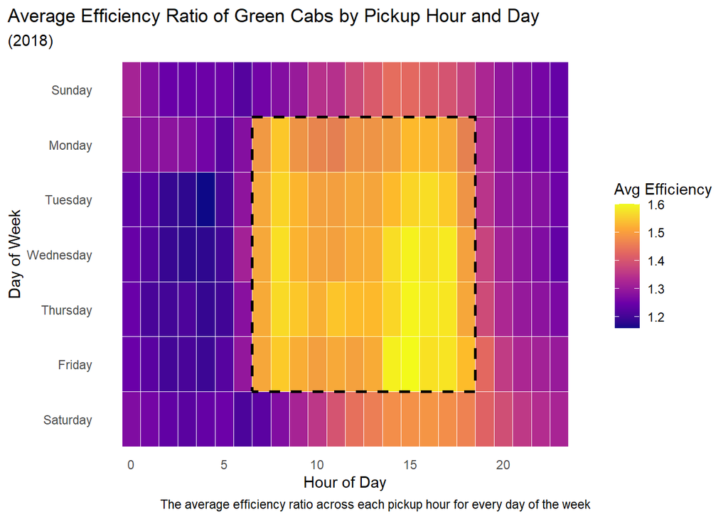

```r
# Create a summary table: average efficiency_ratio by pickup_day and pickup_hour
heatmap_data <- taxi_final %>%
    mutate(pickup_day = fct_rev(pickup_day)) %>%
    group_by(pickup_day, pickup_hour) %>%
    summarise(avg_efficiency = mean(efficiency_ratio, na.rm = TRUE)) %>%
    ungroup()
# Plot heatmap
ggplot(heatmap_data, aes(x = pickup_hour, y = pickup_day, fill = avg_efficiency)) +
    geom_tile(color = "white") +
    # Add rectangle to highlight 7am–6pm Mon–Fri
    annotate("rect",
           xmin = 6.5, xmax = 18.5,  # Hour range +/- 0.5 buffer
           ymin = 1.5, ymax = 6.5,  # Monday (1) to Friday (6), + 0.5 buffer
           alpha = 0.2, fill = "yellow", color = "black", size = 1, linetype = "dashed") +
    scale_fill_viridis_c(option = "C", name = "Avg Efficiency") +
    labs(
    title = "Average Efficiency Ratio of Green Cabs by Pickup Hour and Day",
    subtitle = "(2018)",
    x = "Hour of Day",
    y = "Day of Week",
    caption = "The average efficiency ratio across each pickup hour for every day of the week"
    ) +
    theme_minimal() +
    theme(panel.grid = element_blank(),
          plot.title.position = "plot")
```

Initially we were surprised with the results of the heat map. Showing best efficiency during working hours 7 am to 6pm Monday through Friday. This meant we needed to investigate further.

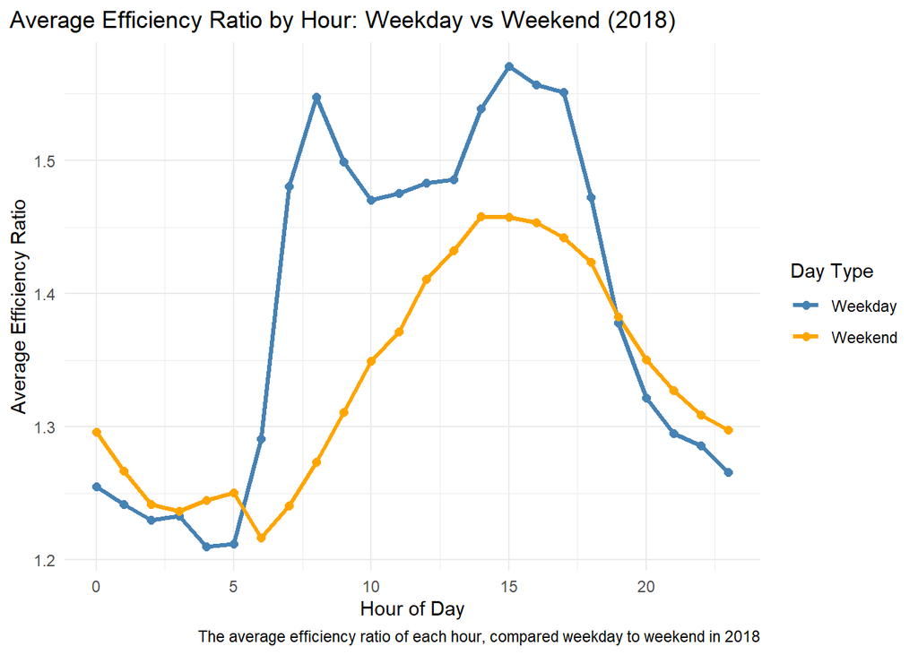

```r
# Create a new column to classify weekday vs weekend
taxi_charts <- taxi_final %>%
    mutate(day_type = ifelse(pickup_day %in% c("Saturday", "Sunday"), "Weekend", "Weekday"))

# Summarize average efficiency by hour and day type
efficiency_by_hour <- taxi_charts %>%
    group_by(pickup_hour, day_type) %>%
    summarise(avg_efficiency = mean(efficiency_ratio, na.rm = TRUE), .groups = "drop")

# Line plot
ggplot(efficiency_by_hour, aes(x = pickup_hour, y = avg_efficiency, color = day_type)) +
    geom_line(size = 1.2) +
    geom_point(size = 2) +
    scale_color_manual(values = c("Weekday" = "steelblue", "Weekend" = "orange")) +
    labs(
    title = "Average Efficiency Ratio by Hour: Weekday vs Weekend (2018)",
    x = "Hour of Day",
    y = "Average Efficiency Ratio",
    color = "Day Type",
    caption = "The average efficiency ratio of each hour, compared weekday to weekend in 2018"
    ) +
    theme_minimal() +
    theme(plot.title.position = "plot")
```

Again we can see the efficiency on weekdays is better than weekends between 6 am and 6pm.

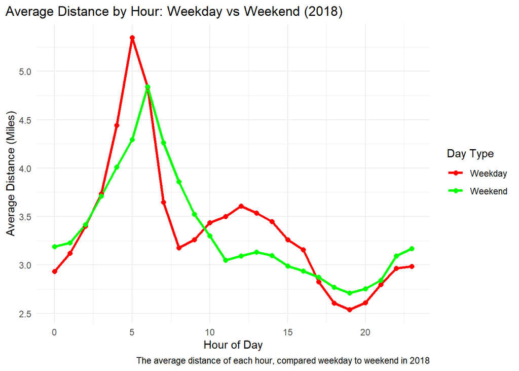

```r
# Summarize average distance by hour and day type
distance_by_hour <- taxi_charts %>%
    group_by(pickup_hour, day_type) %>%
    summarise(avg_distance = mean(trip_distance, na.rm = TRUE), .groups = "drop")

# Line plot
ggplot(distance_by_hour, aes(x = pickup_hour, y = avg_distance, color = day_type)) +
    geom_line(size = 1.2) +
    geom_point(size = 2) +
    scale_color_manual(values = c("Weekday" = "red", "Weekend" = "green")) +
    labs(
    title = "Average Distance by Hour: Weekday vs Weekend (2018)",
    x = "Hour of Day",
    y = "Average Distance (Miles)",
    color = "Day Type",
    caption = "The average distance of each hour, compared weekday to weekend in 2018"
    ) +
    theme_minimal() +
    theme(plot.title.position = "plot")
```

It appears there may be decreased efficiency in the morning before 6 am because of longer rides. We see a spike in distance at 5am and this corresponds to a drop in efficiency at 4-5 am in the last chart.

```r
# import taxi zone look up
taxi_zones <- read.csv("taxi_zone_lookup.csv")
dim(taxi_zones)
```

```
## [1] 265   4
```

```r
summary(taxi_zones)
```

```
##    LocationID    Borough              Zone           service_zone
##  Min.   :  1   Length:265         Length:265         Length:265
##  1st Qu.: 67   Class :character   Class :character   Class :character
##  Median :133   Mode  :character   Mode  :character   Mode  :character
##  Mean   :133
##  3rd Qu.:199
##  Max.   :265
```

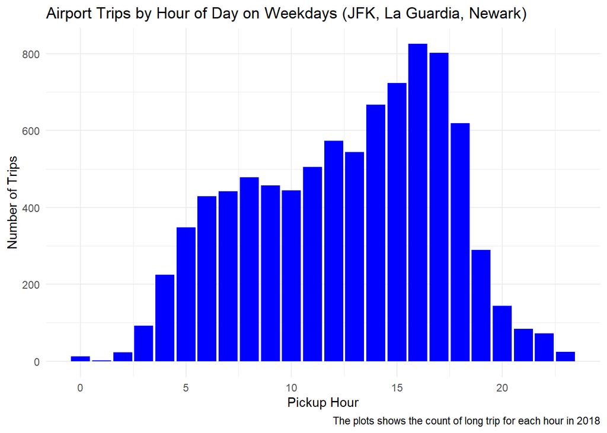

```r
# time of day for trips to the airport
airport_trips_by_hour <- taxi_charts %>%
    filter(day_type == "Weekday") %>% # filter for Weekday
    left_join(taxi_zones, by = c("DOLocationID" = "LocationID")) %>%
    filter(Zone %in%  c("JFK Airport", "LaGuardia Airport", "Newark Airport")) %>%
    group_by(pickup_hour, Zone) %>%
    summarize(n_trips = n(), .groups = "drop")

# bar chart
ggplot(airport_trips_by_hour, aes(x = pickup_hour, y = n_trips)) +
    geom_col(fill = "blue") +
    labs(title = "Airport Trips by Hour of Day on Weekdays (JFK, La Guardia, Newark)",
    x = "Pickup Hour",
    y = "Number of Trips",
    caption = "The plots shows the count of long trip for each hour in 2018"
    ) +
    theme_minimal()
```

The first theory was more people are traveling to the airport at 5 am. We definitely see a rise in people traveling to the airports at 5am but more taxis will go to the airport in afternoon rush hour.

```r
# where are people going at 5 am?
top_drop_off_5am <- taxi_charts %>%
    filter(pickup_hour == 5 & day_type == "Weekday") %>%
    count(DOLocationID, sort = TRUE) %>%
    left_join(taxi_zones, by = c("DOLocationID" = "LocationID"))

head(top_drop_off_5am, 10)
```

| DOLocationID | n | Borough | Zone | service_zone |
| --- | --- | --- | --- | --- |
| 138 | 223 | Queens | LaGuardia Airport | Airports |
| 132 | 120 | Queens | JFK Airport | Airports |
| 236 | 79 | Manhattan | Upper East Side North | Yellow Zone |
| 161 | 72 | Manhattan | Midtown Center | Yellow Zone |
| 230 | 63 | Manhattan | Times Sq/Theatre District | Yellow Zone |
| 75 | 56 | Manhattan | East Harlem South | Boro Zone |
| 37 | 52 | Brooklyn | Bushwick South | Boro Zone |
| 263 | 49 | Manhattan | Yorkville West | Yellow Zone |
| 140 | 48 | Manhattan | Lenox Hill East | Yellow Zone |
| 162 | 48 | Manhattan | Midtown East | Yellow Zone |

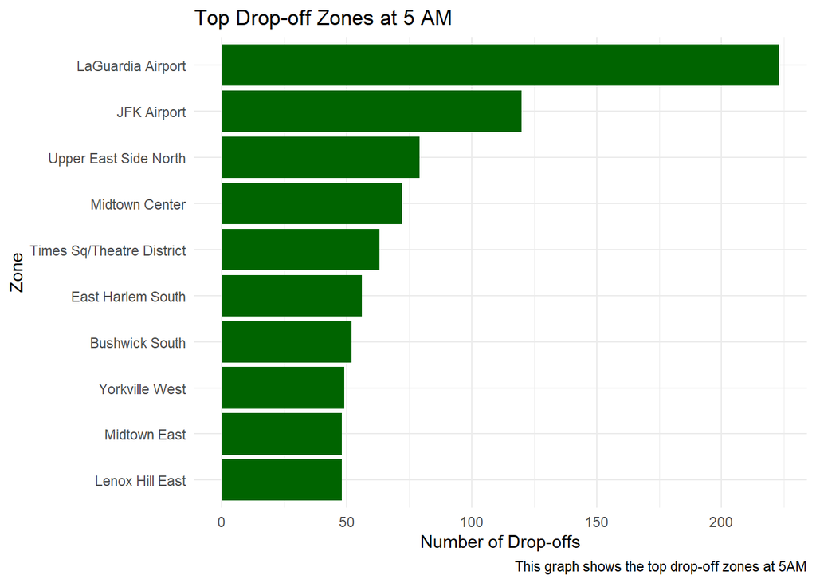

```r
top_drop_off_5am %>%
    slice_max(n, n = 10) %>%
    ggplot(aes(x = reorder(Zone, n), y = n)) +
    geom_col(fill = "darkgreen") +
    coord_flip() +
    labs(title = "Top Drop-off Zones at 5 AM",
       x = "Zone",
       y = "Number of Drop-offs",
       caption = "This graph shows the top drop-off zones at 5AM") +
    theme_minimal()
```

At 5 am the top drop off locations are La Guardia and JFK and then mostly areas Manhattan. People traveling to Manhattan are likely people traveling for work.

```r
# who is traveling at 5 am?
taxi_charts %>%
    filter(pickup_hour == 5 & day_type == "Weekday") %>%
    group_by(passenger_count) %>%
    summarise(n = n(), avg_distance = mean(trip_distance, na.rm = TRUE)) %>%
    arrange(desc(n))
```

| passenger_count | n | avg_distance |
| --- | --- | --- |
| 1 | 2483 | 5.197463 |
| 2 | 275 | 6.888036 |
| 5 | 93 | 4.834839 |
| 3 | 67 | 6.985224 |
| 6 | 64 | 3.861719 |
| 4 | 9 | 3.963333 |

Most trips are single passengers which gives weight to the theory of people traveling to work.

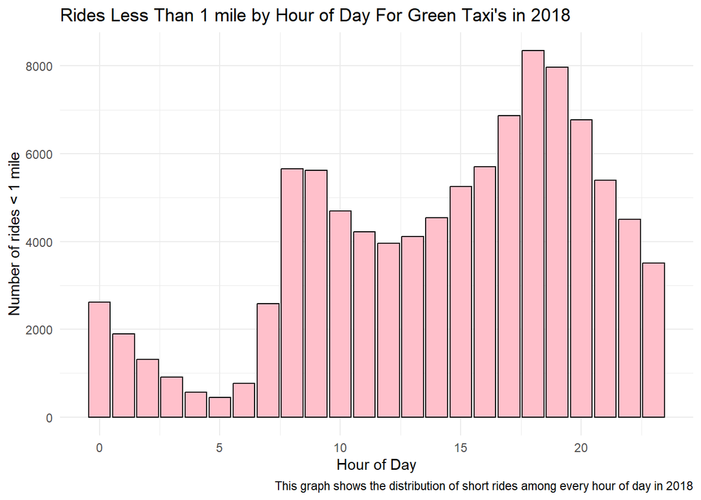

```r
# Hours of day with the most rides less than 1 mile
taxi_final %>%
    filter(trip_distance < 1) %>%  # Filter for short rides
    group_by(pickup_hour) %>%
    summarise(n_short_rides = n(), .groups = "drop") %>%
    ggplot(aes(x = pickup_hour, y = n_short_rides)) +
    geom_col(fill = "pink", color = "black") +
    labs(title = "Rides Less Than 1 mile by Hour of Day For Green Taxi's in 2018",
         x = "Hour of Day",
         y = "Number of rides < 1 mile",
         caption = "This graph shows the distribution of short rides among every hour of day in 2018") +
    theme_minimal()
```

This chart shows that the drop in efficiency after 6 pm is likely due to an increase in very short or aborted rides (rides less than 1 mile). One study sited in a news article in 2021 showed that traffic is worst after 4pm. These short rides may be because people choose to get out of the taxi that is stuck in traffic.

Corrado, K. (2021 Dec.8). NYC has worst traffic congestion in U.S., among worst in world: study.https://pix11.com/news/local-news/nyc-worst-traffic-in-country-study-finds/

In conclusion it seems like the most efficient rides are between 7am - 6pm Monday - Friday because of longer rides in the morning and bad traffic in the evening.